# Final Project Code

Batting statistics:

I. Introduction: In this project, we aim to analyze various hitting and pitching stats for Major League Baseball (MLB), the league leaders for every year in particular. Our analysis of these hitting and pitching metrics will serve as answers to our questions of interest. We would like to know how the National League (NL) leaders in various metrics compare over time. Through our big-picture question, we anticipate that we will also gain answers to how the statistics for the league leaders compare via year intervals, what certain peaks and valleys exist in our data, how some average-based statistics truly reflect upon the statistic itself (i.e., if the pitcher with the highest strikeouts per nine innings necessarily was the pitcher with the most strikeouts), and if we can draw a relationship between hitting and pitching metrics, especially over time. We plan to spotlight various MLB players through our investigation and analysis, while also acknowledging the impact of new technology on the collection of statistics over time. The purpose of investigating these questions is to work with a long-existing and ever-growing dataset that is meaningful to players, team officials, statisticians, and fans. These statistics and metrics are meant to determine the proficiency of performance and a player’s value to his team, further underscoring the importance of understanding the data.

HITS:

```python
import requests
from bs4 import BeautifulSoup
import pandas as pd

url = "https://www.baseball-almanac.com/hitting/hihits4.shtml"

# Set a custom user agent
headers = {
    'User-Agent': 'Mozilla/5.0 (Windows NT 10.0; Win64; x64) AppleWebKit/537.36 (KHTML, like Gecko) Chrome/58.0.3029.110 Safari/537.3'}

# Send a GET request to the URL with headers
response = requests.get(url, headers=headers)

# Check if the request was successful (status code 200)
if response.status_code == 200:
    # Parse the HTML content of the page
    soup = BeautifulSoup(response.content, 'html.parser')

    # Find the first table on the page
    table = soup.find('table')

    # Extract data from the table
    table_data = []
    header_found = False

    for row in table.find_all('tr'):
        columns = row.find_all(['th', 'td'])

        # Check if the first column contains a numeric value (indicating a year)
        if columns and columns[0].text.strip().isnumeric():
            year = columns[0].text.strip()

            # Skip rows for years 1876 to 1900
            if 1876 <= int(year) <= 1900:
                continue

        # Check if the row contains the repeated header
        if len(columns) > 2 and 'American League' in columns[1].text.strip() and 'RBI' in columns[2].text.strip():
            header_found = True
            continue  # Skip this row

        if header_found:
            header_found = False
            continue  # Skip the next row after the repeated header

        # Check the length of the columns list
        if len(columns) < 5:
            continue  # Skip this row

        year = columns[4].text.strip()
        player = columns[5].text.strip()
        team = columns[7].text.strip()
        hits = columns[6].text.strip()

        # Exclude the row where the year is 2023 and the player is "American League"
        if year == '2023' and player == 'American League':
            continue

        table_data.append([year, player, team, hits])

    # Create a DataFrame
    df = pd.DataFrame(table_data, columns=['Year', 'Player', 'Team', 'Hits'])

    df = df.drop([0, 124]).reset_index(drop=True)

    # Print the DataFrame without the extra 'RBIs' column
    print(df[['Year', 'Player', 'Team', 'Hits']])
else:
    print(f"Failed to retrieve the webpage. Status code: {response.status_code}")
```

```
     Year            Player         Team  Hits
0    1901     Jesse Burkett    St. Louis   226
1    1902   Ginger Beaumont   Pittsburgh   193
2    1903   Ginger Beaumont   Pittsburgh   209
3    1904   Ginger Beaumont   Pittsburgh   185
4    1905        Cy Seymour   Cincinnati   219
..    ...               ...          ...   ...
119  2020       Trea Turner   Washington    78
120  2021       Trea Turner  Los Angeles   195
121  2022   Freddie Freeman  Los Angeles   199
122  2023  Ronald Acuña Jr.      Atlanta   217
123  Year   National League      Team(s)  Hits

[124 rows x 4 columns]
```

DOUBLES:

```python
import requests
from bs4 import BeautifulSoup
import pandas as pd

url = "https://www.baseball-almanac.com/hitting/hi2b3.shtml"

# Set a custom user agent
headers = {
    'User-Agent': 'Mozilla/5.0 (Windows NT 10.0; Win64; x64) AppleWebKit/537.36 (KHTML, like Gecko) Chrome/58.0.3029.110 Safari/537.3'}

# Send a GET request to the URL with headers
response = requests.get(url, headers=headers)

# Check if the request was successful (status code 200)
if response.status_code == 200:
    # Parse the HTML content of the page
    soup = BeautifulSoup(response.content, 'html.parser')

    # Find the first table on the page
    table = soup.find('table')

    # Extract data from the table
    table_data = []
    header_found = False

    for row in table.find_all('tr'):
        columns = row.find_all(['th', 'td'])

        # Check if the first column contains a numeric value (indicating a year)
        if columns and columns[0].text.strip().isnumeric():
            year = columns[0].text.strip()

            # Skip rows for years 1876 to 1900
            if 1876 <= int(year) <= 1900:
                continue

        # Check if the row contains the repeated header
        if len(columns) > 2 and 'American League' in columns[1].text.strip() and 'RBI' in columns[2].text.strip():
            header_found = True
            continue  # Skip this row

        if header_found:
            header_found = False
            continue  # Skip the next row after the repeated header

        # Check the length of the columns list
        if len(columns) < 5:
            continue  # Skip this row

        year = columns[4].text.strip()
        player = columns[5].text.strip()
        team = columns[7].text.strip()
        doubles = columns[6].text.strip()

        # Exclude the row where the year is 2023 and the player is "American League"
        if year == '2023' and player == 'American League':
            continue

        table_data.append([year, player, team, doubles])

    # Create a DataFrame
    df = pd.DataFrame(table_data, columns=['Year', 'Player', 'Team', 'Doubles'])

    df = df.drop([0, 124]).reset_index(drop=True)

    # Print the DataFrame without the extra 'RBIs' column
    print(df[['Year', 'Player', 'Team', 'Doubles']])
else:
    print(f"Failed to retrieve the webpage. Status code: {response.status_code}")
```

```
     Year           Player          Team  Doubles
0    1901         Tom Daly      Brooklyn       38
1    1902     Honus Wagner    Pittsburgh       30
2    1903      Fred Clarke    Pittsburgh       32
3    1904     Honus Wagner    Pittsburgh       44
4    1905       Cy Seymour    Cincinnati       40
..    ...              ...           ...      ...
119  2020  Freddie Freeman       Atlanta       23
120  2021     Bryce Harper  Philadelphia       42
121  2022  Freddie Freeman   Los Angeles       47
122  2023  Freddie Freeman   Los Angeles       59
123  Year  National League       Team(s)  Doubles

[124 rows x 4 columns]
```

TRIPLES:

```python
import requests
from bs4 import BeautifulSoup
import pandas as pd

url = "https://www.baseball-almanac.com/hitting/hitrip4.shtml"

# Set a custom user agent
headers = {
    'User-Agent': 'Mozilla/5.0 (Windows NT 10.0; Win64; x64) AppleWebKit/537.36 (KHTML, like Gecko) Chrome/58.0.3029.110 Safari/537.3'}

# Send a GET request to the URL with headers
response = requests.get(url, headers=headers)

# Check if the request was successful (status code 200)
if response.status_code == 200:
    # Parse the HTML content of the page
    soup = BeautifulSoup(response.content, 'html.parser')

    # Find the first table on the page
    table = soup.find('table')

    # Extract data from the table
    table_data = []
    header_found = False

    for row in table.find_all('tr'):
        columns = row.find_all(['th', 'td'])

        # Check if the first column contains a numeric value (indicating a year)
        if columns and columns[0].text.strip().isnumeric():
            year = columns[0].text.strip()

            # Skip rows for years 1876 to 1900
            if 1876 <= int(year) <= 1900:
                continue

        # Check if the row contains the repeated header
        if len(columns) > 2 and 'American League' in columns[1].text.strip() and 'RBI' in columns[2].text.strip():
            header_found = True
            continue  # Skip this row

        if header_found:
            header_found = False
            continue  # Skip the next row after the repeated header

        # Check the length of the columns list
        if len(columns) < 5:
            continue  # Skip this row

        year = columns[4].text.strip()
        player = columns[5].text.strip()
        team = columns[7].text.strip()
        triples = columns[6].text.strip()

        # Exclude the row where the year is 2023 and the player is "American League"
        if year == '2023' and player == 'American League':
            continue

        table_data.append([year, player, team, triples])

    # Create a DataFrame
    df = pd.DataFrame(table_data, columns=['Year', 'Player', 'Team', 'Triples'])

    df = df.drop([0, 124]).reset_index(drop=True)

    # Print the DataFrame without the extra 'RBIs' column
    print(df[['Year', 'Player', 'Team', 'Triples']])
else:
    print(f"Failed to retrieve the webpage. Status code: {response.status_code}")
```

```
     Year           Player         Team  Triples
0    1901   Jimmy Sheckard     Brooklyn       19
1    1902     Sam Crawford   Cincinnati       22
2    1903     Honus Wagner   Pittsburgh       19
3    1904     Harry Lumley     Brooklyn       18
4    1905       Cy Seymour   Cincinnati       21
..    ...              ...          ...      ...
119  2020     Trevor Story     Colorado        4
120  2021    David Peralta      Arizona        8
121  2022        Gavin Lux  Los Angeles        7
122  2023   Corbin Carroll      Arizona       10
123  Year  National League      Team(s)  Triples

[124 rows x 4 columns]
```

HOME RUNS:

```python
import requests
from bs4 import BeautifulSoup
import pandas as pd

url = "https://www.baseball-almanac.com/hitting/hihr5.shtml"

# Set a custom user agent
headers = {
    'User-Agent': 'Mozilla/5.0 (Windows NT 10.0; Win64; x64) AppleWebKit/537.36 (KHTML, like Gecko) Chrome/58.0.3029.110 Safari/537.3'}

# Send a GET request to the URL with headers
response = requests.get(url, headers=headers)

# Check if the request was successful (status code 200)
if response.status_code == 200:
    # Parse the HTML content of the page
    soup = BeautifulSoup(response.content, 'html.parser')

    # Find the first table on the page
    table = soup.find('table')

    # Extract data from the table
    table_data = []
    header_found = False

    for row in table.find_all('tr'):
        columns = row.find_all(['th', 'td'])

        # Check if the first column contains a numeric value (indicating a year)
        if columns and columns[0].text.strip().isnumeric():
            year = columns[0].text.strip()

            # Skip rows for years 1876 to 1900
            if 1876 <= int(year) <= 1900:
                continue

        # Check if the row contains the repeated header
        if len(columns) > 2 and 'American League' in columns[1].text.strip() and 'RBI' in columns[2].text.strip():
            header_found = True
            continue  # Skip this row

        if header_found:
            header_found = False
            continue  # Skip the next row after the repeated header

        # Check the length of the columns list
        if len(columns) < 5:
            continue  # Skip this row

        year = columns[4].text.strip()
        player = columns[5].text.strip()
        team = columns[7].text.strip()
        home_runs = columns[6].text.strip()

        # Exclude the row where the year is 2023 and the player is "American League"
        if year == '2023' and player == 'American League':
            continue

        table_data.append([year, player, team, home_runs])

    # Create a DataFrame
    df = pd.DataFrame(table_data, columns=['Year', 'Player', 'Team', 'Home Runs'])

    df = df.drop([0, 124]).reset_index(drop=True)

    # Print the DataFrame without the extra 'RBIs' column
    print(df[['Year', 'Player', 'Team', 'Home Runs']])
else:
    print(f"Failed to retrieve the webpage. Status code: {response.status_code}")
```

```
     Year              Player          Team Home Runs
0    1901        Sam Crawford    Cincinnati        16
1    1902         Tommy Leach    Pittsburgh         6
2    1903      Jimmy Sheckard      Brooklyn         9
3    1904        Harry Lumley      Brooklyn         9
4    1905         Fred Odwell    Cincinnati         9
..    ...                 ...           ...       ...
119  2020       Marcell Ozuna       Atlanta        18
120  2021  Fernando Tatis Jr.     San Diego        42
121  2022      Kyle Schwarber  Philadelphia        46
122  2023          Matt Olson       Atlanta        54
123  Year     National League       Team(s)       HRs

[124 rows x 4 columns]
```

XBH:

```python
import requests
from bs4 import BeautifulSoup
import pandas as pd

url = "https://www.baseball-almanac.com/hitting/hiebh4.shtml"

# Set a custom user agent
headers = {
    'User-Agent': 'Mozilla/5.0 (Windows NT 10.0; Win64; x64) AppleWebKit/537.36 (KHTML, like Gecko) Chrome/58.0.3029.110 Safari/537.3'}

# Send a GET request to the URL with headers
response = requests.get(url, headers=headers)

# Check if the request was successful (status code 200)
if response.status_code == 200:
    # Parse the HTML content of the page
    soup = BeautifulSoup(response.content, 'html.parser')

    # Find the first table on the page
    table = soup.find('table')

    # Extract data from the table
    table_data = []
    header_found = False

    for row in table.find_all('tr'):
        columns = row.find_all(['th', 'td'])

        # Check if the first column contains a numeric value (indicating a year)
        if columns and columns[0].text.strip().isnumeric():
            year = columns[0].text.strip()

            if 1876 <= int(year) <= 1900:
                continue  # Skip this row

        # Check if the row contains the repeated header
        if len(columns) > 2 and 'American League' in columns[1].text.strip() and 'RBI' in columns[2].text.strip():
            header_found = True
            continue  # Skip this row

        if header_found:
            header_found = False
            continue  # Skip the next row after the repeated header

        # Check the length of the columns list
        if len(columns) < 5:
            continue  # Skip this row

        player = columns[5].text.strip()
        team = columns[7].text.strip()
        xbh = columns[6].text.strip()

        # Exclude the row where the year is 2023 and the player is "American League"
        if year == '2023' and player == 'American League':
            continue

        table_data.append([year, player, team, xbh])

    # Create a DataFrame
    df = pd.DataFrame(table_data, columns=['Year', 'Player', 'Team',  'XBH'])

    df = df.drop([0, 124]).reset_index(drop=True)

    # Print the DataFrame without the extra 'RBIs' column
print(df[['Year', 'Player', 'Team', 'XBH']])
```

```
     Year           Player          Team              XBH
0    1901     Ed Delahanty  Philadelphia               62
1    1902     Honus Wagner    Pittsburgh               49
2    1903     Honus Wagner    Pittsburgh               54
3    1904     Honus Wagner    Pittsburgh               62
4    1905       Cy Seymour    Cincinnati               69
..    ...              ...           ...              ...
119  2020  Freddie Freeman       Atlanta               37
120  2021     Bryce Harper  Philadelphia               78
121  2022     Austin Riley       Atlanta               79
122  2023  Freddie Freeman   Los Angeles               90
123  2024  National League       Team(s)  Extra Base Hits

[124 rows x 4 columns]
```

TOTAL BASES:

```python
import requests
from bs4 import BeautifulSoup
import pandas as pd

url = "https://www.baseball-almanac.com/hitting/hitotb4.shtml"

# Set a custom user agent
headers = {
    'User-Agent': 'Mozilla/5.0 (Windows NT 10.0; Win64; x64) AppleWebKit/537.36 (KHTML, like Gecko) Chrome/58.0.3029.110 Safari/537.3'}

# Send a GET request to the URL with headers
response = requests.get(url, headers=headers)

# Check if the request was successful (status code 200)
if response.status_code == 200:
    # Parse the HTML content of the page
    soup = BeautifulSoup(response.content, 'html.parser')

    # Find the first table on the page
    table = soup.find('table')

    # Extract data from the table
    table_data = []
    header_found = False

    for row in table.find_all('tr'):
        columns = row.find_all(['th', 'td'])

        # Check if the first column contains a numeric value (indicating a year)
        if columns and columns[0].text.strip().isnumeric():
            year = columns[0].text.strip()

            if 1876 <= int(year) <= 1900:
                continue  # Skip this row

        # Check if the row contains the repeated header
        if len(columns) > 2 and 'American League' in columns[1].text.strip() and 'RBI' in columns[2].text.strip():
            header_found = True
            continue  # Skip this row

        if header_found:
            header_found = False
            continue  # Skip the next row after the repeated header

        # Check the length of the columns list
        if len(columns) < 5:
            continue  # Skip this row

        player = columns[5].text.strip()
        team = columns[7].text.strip()
        totalbases = columns[6].text.strip()

        # Exclude the row where the year is 2023 and the player is "American League"
        if year == '2023' and player == 'American League':
            continue

        table_data.append([year, player, team, totalbases])


    # Create a DataFrame
    df = pd.DataFrame(table_data, columns=['Year', 'Player', 'Team',  'TB'])

    df = df.drop([0, 124]).reset_index(drop=True)

    # Print the DataFrame without the extra 'RBIs' column
print(df[['Year', 'Player', 'Team', 'TB']])
```

```
     Year            Player         Team   TB
0    1901     Jesse Burkett    St. Louis  306
1    1902      Sam Crawford   Cincinnati  256
2    1903   Ginger Beaumont   Pittsburgh  272
3    1904      Honus Wagner   Pittsburgh  255
4    1905        Cy Seymour   Cincinnati  325
..    ...               ...          ...  ...
119  2020     Marcell Ozuna      Atlanta  145
120  2021       Trea Turner  Los Angeles  319
121  2022      Austin Riley      Atlanta  325
122  2023  Ronald Acuña Jr.      Atlanta  383
123  2024   National League      Team(s)   TB

[124 rows x 4 columns]
```

RUNS SCORED:

```python
import requests
from bs4 import BeautifulSoup
import pandas as pd

url = "https://www.baseball-almanac.com/hitting/hiruns2.shtml"

# Set a custom user agent
headers = {
    'User-Agent': 'Mozilla/5.0 (Windows NT 10.0; Win64; x64) AppleWebKit/537.36 (KHTML, like Gecko) Chrome/58.0.3029.110 Safari/537.3'}

# Send a GET request to the URL with headers
response = requests.get(url, headers=headers)

# Check if the request was successful (status code 200)
if response.status_code == 200:
    # Parse the HTML content of the page
    soup = BeautifulSoup(response.content, 'html.parser')

    # Find the first table on the page
    table = soup.find('table')

    # Extract data from the table
    table_data = []
    header_found = False

    for row in table.find_all('tr'):
        columns = row.find_all(['th', 'td'])

        # Check if the first column contains a numeric value (indicating a year)
        if columns and columns[0].text.strip().isnumeric():
            year = columns[0].text.strip()

            if 1876 <= int(year) <= 1900:
                continue  # Skip this row

        # Check if the row contains the repeated header
        if len(columns) > 2 and 'American League' in columns[1].text.strip() and 'RBI' in columns[2].text.strip():
            header_found = True
            continue  # Skip this row

        if header_found:
            header_found = False
            continue  # Skip the next row after the repeated header

        # Check the length of the columns list
        if len(columns) < 5:
            continue  # Skip this row

        player = columns[5].text.strip()
        team = columns[7].text.strip()
        runs = columns[6].text.strip()

        # Exclude the row where the year is 2023 and the player is "American League"
        if year == '2023' and player == 'American League':
            continue

        table_data.append([year, player, team, runs])

    # Create a DataFrame
    df = pd.DataFrame(table_data, columns=['Year', 'Player', 'Team',  'Runs Scored'])

    df = df.drop([0, 124]).reset_index(drop=True)

    # Print the DataFrame without the extra 'RBIs' column
print(df[['Year', 'Player', 'Team', 'Runs Scored']])
```

```
     Year            Player         Team Runs Scored
0    1901     Jesse Burkett    St. Louis         142
1    1902      Honus Wagner   Pittsburgh         105
2    1903   Ginger Beaumont   Pittsburgh         137
3    1904     George Browne     New York          99
4    1905       Mike Donlin     New York         124
..    ...               ...          ...         ...
119  2020   Freddie Freeman      Atlanta          51
120  2021   Freddie Freeman      Atlanta         120
121  2022      Mookie Betts  Los Angeles         117
122  2023  Ronald Acuña Jr.      Atlanta         149
123  2024   National League      Team(s)        Runs

[124 rows x 4 columns]
```

RBIs:

```python
import requests
from bs4 import BeautifulSoup
import pandas as pd

url = "https://www.baseball-almanac.com/hitting/hirbi5.shtml#"

# Set a custom user agent
headers = {
    'User-Agent': 'Mozilla/5.0 (Windows NT 10.0; Win64; x64) AppleWebKit/537.36 (KHTML, like Gecko) Chrome/58.0.3029.110 Safari/537.3'}

# Send a GET request to the URL with headers
response = requests.get(url, headers=headers)

# Check if the request was successful (status code 200)
if response.status_code == 200:
    # Parse the HTML content of the page
    soup = BeautifulSoup(response.content, 'html.parser')

    # Find the first table on the page
    table = soup.find('table')

    # Extract data from the table
    table_data = []
    header_found = False

    for row in table.find_all('tr'):
        columns = row.find_all(['th', 'td'])

        # Check if the first column contains a numeric value (indicating a year)
        if columns and columns[0].text.strip().isnumeric():
            year = columns[0].text.strip()

            if 1876 <= int(year) <= 1900:
                continue  # Skip this row

        # Check if the row contains the repeated header
        if len(columns) > 2 and 'American League' in columns[1].text.strip() and 'RBI' in columns[2].text.strip():
            header_found = True
            continue  # Skip this row

        if header_found:
            header_found = False
            continue  # Skip the next row after the repeated header

        # Check the length of the columns list
        if len(columns) < 5:
            continue  # Skip this row

        year = columns[4].text.strip()
        player = columns[5].text.strip()
        team = columns[7].text.strip()
        rbis = columns[6].text.strip()

        table_data.append([year, player, team, rbis])

    # Create a DataFrame
    df = pd.DataFrame(table_data, columns=['Year', 'Player', 'Team',  'RBIs'])

    # Print the DataFrame without the extra 'RBIs' column
print(df[['Year', 'Player', 'Team', 'RBIs']])
```

```
     Year         Player        Team RBIs
0    1901   Honus Wagner  Pittsburgh  126
1    1902   Honus Wagner  Pittsburgh   91
2    1903     Sam Mertes    New York  104
3    1904    Bill Dahlen    New York   80
4    1905     Cy Seymour  Cincinnati  121
..    ...            ...         ...  ...
119  2020  Marcell Ozuna     Atlanta   56
120  2021    Adam Duvall     Atlanta  113
121  2022    Pete Alonso    New York  131
122  2023     Matt Olson     Atlanta  139
123  2024  Marcell Ozuna     Atlanta   86

[124 rows x 4 columns]
```

AVG:

```python
import requests
from bs4 import BeautifulSoup
import pandas as pd

url = "https://www.baseball-almanac.com/hitting/hibavg3.shtml"

# Set a custom user agent
headers = {
    'User-Agent': 'Mozilla/5.0 (Windows NT 10.0; Win64; x64) AppleWebKit/537.36 (KHTML, like Gecko) Chrome/58.0.3029.110 Safari/537.3'}

# Send a GET request to the URL with headers
response = requests.get(url, headers=headers)

# Check if the request was successful (status code 200)
if response.status_code == 200:
    # Parse the HTML content of the page
    soup = BeautifulSoup(response.content, 'html.parser')

    # Find the first table on the page
    table = soup.find('table')

    # Extract data from the table
    table_data = []
    header_found = False

    for row in table.find_all('tr'):
        columns = row.find_all(['th', 'td'])

        # Check if the first column contains a numeric value (indicating a year)
        if columns and columns[0].text.strip().isnumeric():
            year = columns[0].text.strip()

            if 1876 <= int(year) <= 1900:
                continue  # Skip this row

        # Check if the row contains the repeated header
        if len(columns) > 2 and 'American League' in columns[1].text.strip() and 'RBI' in columns[2].text.strip():
            header_found = True
            continue  # Skip this row

        if header_found:
            header_found = False
            continue  # Skip the next row after the repeated header

        # Check the length of the columns list
        if len(columns) < 5:
            continue  # Skip this row

        player = columns[5].text.strip()
        team = columns[7].text.strip()
        batting_average = columns[6].text.strip()

        # Exclude the row where the year is 2023 and the player is "American League"
        if year == '2023' and player == 'American League':
            continue

        table_data.append([year, player, team, batting_average])

    # Create a DataFrame
    df = pd.DataFrame(table_data, columns=['Year', 'Player', 'Team',  'AVG'])

    df = df.drop([0, 124]).reset_index(drop=True)

    # Print the DataFrame without the extra 'RBIs' column
print(df[['Year', 'Player', 'Team', 'AVG']])
```

```
     Year           Player         Team            AVG
0    1901    Jesse Burkett    St. Louis  .376 (.37604)
1    1902  Ginger Beaumont   Pittsburgh  .357 (.35675)
2    1903     Honus Wagner   Pittsburgh  .355 (.35547)
3    1904     Honus Wagner   Pittsburgh  .349 (.34898)
4    1905       Cy Seymour   Cincinnati  .377 (.37694)
..    ...              ...          ...            ...
119  2020        Juan Soto   Washington  .351 (.35064)
120  2021      Trea Turner  Los Angeles  .328 (.32773)
121  2022      Jeff McNeil     New York  .326 (.32645)
122  2023      Luis Arraez        Miami  .354 (.35366)
123  2024  National League      Team(s)      AVG (Raw)

[124 rows x 4 columns]
```

OBP:

```python
import requests
from bs4 import BeautifulSoup
import pandas as pd

url = "https://www.baseball-almanac.com/hitting/hiobp4.shtml"

# Set a custom user agent
headers = {
    'User-Agent': 'Mozilla/5.0 (Windows NT 10.0; Win64; x64) AppleWebKit/537.36 (KHTML, like Gecko) Chrome/58.0.3029.110 Safari/537.3'}

# Send a GET request to the URL with headers
response = requests.get(url, headers=headers)

# Check if the request was successful (status code 200)
if response.status_code == 200:
    # Parse the HTML content of the page
    soup = BeautifulSoup(response.content, 'html.parser')

    # Find the first table on the page
    table = soup.find('table')

    # Extract data from the table
    table_data = []
    header_found = False

    for row in table.find_all('tr'):
        columns = row.find_all(['th', 'td'])

        # Check if the first column contains a numeric value (indicating a year)
        if columns and columns[0].text.strip().isnumeric():
            year = columns[0].text.strip()

            # Skip rows for years 1876 to 1900
            if 1876 <= int(year) <= 1900:
                continue

        # Check if the row contains the repeated header
        if len(columns) > 2 and 'American League' in columns[1].text.strip() and 'RBI' in columns[2].text.strip():
            header_found = True
            continue  # Skip this row

        if header_found:
            header_found = False
            continue  # Skip the next row after the repeated header

        # Check the length of the columns list
        if len(columns) < 5:
            continue  # Skip this row

        year = columns[4].text.strip()
        player = columns[5].text.strip()
        team = columns[7].text.strip()
        obp = columns[6].text.strip()

        # Exclude the row where the year is 2023 and the player is "American League"
        if year == '2023' and player == 'American League':
            continue

        table_data.append([year, player, team, obp])

    # Create a DataFrame
    df = pd.DataFrame(table_data, columns=['Year', 'Player', 'Team', 'OBP'])

    df = df.drop([0, 124]).reset_index(drop=True)

    # Print the DataFrame without the extra 'RBIs' column
    print(df[['Year', 'Player', 'Team', 'OBP']])
else:
    print(f"Failed to retrieve the webpage. Status code: {response.status_code}")
```

```
     Year            Player          Team            OBP
0    1901     Jesse Burkett     St. Louis  .440 (.44030)
1    1902        Roy Thomas  Philadelphia  .414 (.41379)
2    1903        Roy Thomas  Philadelphia  .453 (.45315)
3    1904      Honus Wagner    Pittsburgh  .423 (.42315)
4    1905      Frank Chance       Chicago  .450 (.44969)
..    ...               ...           ...            ...
119  2020         Juan Soto    Washington  .490 (.48979)
120  2021         Juan Soto    Washington  .465 (.46483)
121  2022   Freddie Freeman   Los Angeles  .407 (.40678)
122  2023  Ronald Acuña Jr.       Atlanta  .416 (.41633)
123  Year   National League       Team(s)      OBP (Raw)

[124 rows x 4 columns]
```

SLG:

```python
import requests
from bs4 import BeautifulSoup
import pandas as pd

url = "https://www.baseball-almanac.com/hitting/hislug4.shtml"

# Set a custom user agent
headers = {
    'User-Agent': 'Mozilla/5.0 (Windows NT 10.0; Win64; x64) AppleWebKit/537.36 (KHTML, like Gecko) Chrome/58.0.3029.110 Safari/537.3'}

# Send a GET request to the URL with headers
response = requests.get(url, headers=headers)

# Check if the request was successful (status code 200)
if response.status_code == 200:
    # Parse the HTML content of the page
    soup = BeautifulSoup(response.content, 'html.parser')

    # Find the first table on the page
    table = soup.find('table')

    # Extract data from the table
    table_data = []
    header_found = False

    for row in table.find_all('tr'):
        columns = row.find_all(['th', 'td'])

        # Check if the first column contains a numeric value (indicating a year)
        if columns and columns[0].text.strip().isnumeric():
            year = columns[0].text.strip()

            # Skip rows for years 1876 to 1900
            if 1876 <= int(year) <= 1900:
                continue

        # Check if the row contains the repeated header
        if len(columns) > 2 and 'American League' in columns[1].text.strip() and 'RBI' in columns[2].text.strip():
            header_found = True
            continue  # Skip this row

        if header_found:
            header_found = False
            continue  # Skip the next row after the repeated header

        # Check the length of the columns list
        if len(columns) < 5:
            continue  # Skip this row

        player = columns[5].text.strip()
        team = columns[7].text.strip()
        SLG = columns[6].text.strip()

        # Exclude the row where the year is 2023 and the player is "American League"
        if year == '2023' and player == 'American League':
            continue

        table_data.append([year, player, team, SLG])

    # Create a DataFrame
    df = pd.DataFrame(table_data, columns=['Year', 'Player', 'Team', 'SLG'])

    df = df.drop([0, 124]).reset_index(drop=True)

    # Print the DataFrame without the extra 'RBIs' column
    print(df[['Year', 'Player', 'Team', 'SLG']])
else:
    print(f"Failed to retrieve the webpage. Status code: {response.status_code}")
```

```
     Year            Player          Team            SLG
0    1901    Jimmy Sheckard      Brooklyn  .534 (.53430)
1    1902      Honus Wagner    Pittsburgh  .464 (.46442)
2    1903       Fred Clarke    Pittsburgh  .532 (.53162)
3    1904      Honus Wagner    Pittsburgh  .520 (.52041)
4    1905        Cy Seymour    Cincinnati  .559 (.55938)
..    ...               ...           ...            ...
119  2020         Juan Soto    Washington  .695 (.69480)
120  2021      Bryce Harper  Philadelphia  .615 (.61475)
121  2022  Paul Goldschmidt     St. Louis  .578 (.57754)
122  2023        Matt Olson       Atlanta  .604 (.60362)
123  2024   National League       Team(s)            SLG

[124 rows x 4 columns]
```

STRIKEOUTS:

```python
import requests
from bs4 import BeautifulSoup
import pandas as pd

url = "https://www.baseball-almanac.com/hitting/histrk3.shtml"

# Set a custom user agent
headers = {
    'User-Agent': 'Mozilla/5.0 (Windows NT 10.0; Win64; x64) AppleWebKit/537.36 (KHTML, like Gecko) Chrome/58.0.3029.110 Safari/537.3'}

# Send a GET request to the URL with headers
response = requests.get(url, headers=headers)

# Check if the request was successful (status code 200)
if response.status_code == 200:
    # Parse the HTML content of the page
    soup = BeautifulSoup(response.content, 'html.parser')

    # Find the first table on the page
    table = soup.find('table')

    # Extract data from the table
    table_data = []
    header_found = False

    for row in table.find_all('tr'):
        columns = row.find_all(['th', 'td'])

        # Check if the first column contains a numeric value (indicating a year)
        if columns and columns[0].text.strip().isnumeric():
            year = columns[0].text.strip()

            if 1876 <= int(year) <= 1900:
                continue  # Skip this row

        # Check if the row contains the repeated header
        if len(columns) > 2 and 'American League' in columns[1].text.strip() and 'RBI' in columns[2].text.strip():
            header_found = True
            continue  # Skip this row

        if header_found:
            header_found = False
            continue  # Skip the next row after the repeated header

        # Check the length of the columns list
        if len(columns) < 5:
            continue  # Skip this row

        player = columns[5].text.strip()
        team = columns[7].text.strip()
        hitter_strikeouts = columns[6].text.strip()

        # Exclude the row where the year is 2023 and the player is "American League"
        if year == '2023' and player == 'American League':
            continue

        table_data.append([year, player, team, hitter_strikeouts])

    # Create a DataFrame
    df = pd.DataFrame(table_data, columns=['Year', 'Player', 'Team',  'Strikeouts'])

    df = df.drop([0, 124]).reset_index(drop=True)

    # Print the DataFrame without the extra 'RBIs' column
print(df[['Year', 'Player', 'Team', 'Strikeouts']])
```

```
     Year           Player          Team Strikeouts
0    1901     Sammy Strang      New York         77
1    1902       Joe Tinker       Chicago         61
2    1903    George Browne      New York         58
3    1904     Harry Lumley      Brooklyn        106
4    1905     Harry Lumley      Brooklyn         64
..    ...              ...           ...        ...
119  2020     Keston Hiura     Milwaukee         85
120  2021      Javier Báez       Chicago        184
121  2022   Kyle Schwarber  Philadelphia        200
122  2023   Kyle Schwarber  Philadelphia        215
123  2024  National League       Team(s)         SO

[124 rows x 4 columns]
```

WALKS (BATTER):

```python
import requests
from bs4 import BeautifulSoup
import pandas as pd

url = "https://www.baseball-almanac.com/hitting/hiwalk4.shtml"

# Set a custom user agent
headers = {
    'User-Agent': 'Mozilla/5.0 (Windows NT 10.0; Win64; x64) AppleWebKit/537.36 (KHTML, like Gecko) Chrome/58.0.3029.110 Safari/537.3'}

# Send a GET request to the URL with headers
response = requests.get(url, headers=headers)

# Check if the request was successful (status code 200)
if response.status_code == 200:
    # Parse the HTML content of the page
    soup = BeautifulSoup(response.content, 'html.parser')

    # Find the first table on the page
    table = soup.find('table')

    # Extract data from the table
    table_data = []
    header_found = False

    for row in table.find_all('tr'):
        columns = row.find_all(['th', 'td'])

        # Check if the first column contains a numeric value (indicating a year)
        if columns and columns[0].text.strip().isnumeric():
            year = columns[0].text.strip()

            if 1876 <= int(year) <= 1900:
                continue  # Skip this row

        # Check if the row contains the repeated header
        if len(columns) > 2 and 'American League' in columns[1].text.strip() and 'RBI' in columns[2].text.strip():
            header_found = True
            continue  # Skip this row

        if header_found:
            header_found = False
            continue  # Skip the next row after the repeated header

        # Check the length of the columns list
        if len(columns) < 5:
            continue  # Skip this row

        player = columns[5].text.strip()
        team = columns[7].text.strip()
        hitter_walks = columns[6].text.strip()

        # Exclude the row where the year is 2023 and the player is "American League"
        if year == '2023' and player == 'American League':
            continue

        table_data.append([year, player, team, hitter_walks])

    # Create a DataFrame
    df = pd.DataFrame(table_data, columns=['Year', 'Player', 'Team',  'Hitter Walks'])

    df = df.drop([0, 124]).reset_index(drop=True)

    # Print the DataFrame without the extra 'RBIs' column
print(df[['Year', 'Player', 'Team', 'Hitter Walks']])
```

```
     Year           Player          Team Hitter Walks
0    1901       Roy Thomas  Philadelphia          100
1    1902       Roy Thomas  Philadelphia          107
2    1903       Roy Thomas  Philadelphia          107
3    1904       Roy Thomas  Philadelphia          102
4    1905   Miller Huggins    Cincinnati          103
..    ...              ...           ...          ...
119  2020     Bryce Harper  Philadelphia           49
120  2021        Juan Soto    Washington          145
121  2022        Juan Soto     San Diego          135
122  2023        Juan Soto     San Diego          132
123  2024  National League       Team(s)           BB

[124 rows x 4 columns]
```

AT BATS:

```python
import requests
from bs4 import BeautifulSoup
import pandas as pd

url = "https://www.baseball-almanac.com/hitting/hiatbat2.shtml"

# Set a custom user agent
headers = {
    'User-Agent': 'Mozilla/5.0 (Windows NT 10.0; Win64; x64) AppleWebKit/537.36 (KHTML, like Gecko) Chrome/58.0.3029.110 Safari/537.3'}

# Send a GET request to the URL with headers
response = requests.get(url, headers=headers)

# Check if the request was successful (status code 200)
if response.status_code == 200:
    # Parse the HTML content of the page
    soup = BeautifulSoup(response.content, 'html.parser')

    # Find the first table on the page
    table = soup.find('table')

    # Extract data from the table
    table_data = []
    header_found = False

    for row in table.find_all('tr'):
        columns = row.find_all(['th', 'td'])

        # Check if the first column contains a numeric value (indicating a year)
        if columns and columns[0].text.strip().isnumeric():
            year = columns[0].text.strip()

            if 1876 <= int(year) <= 1900:
                continue  # Skip this row

        # Check if the row contains the repeated header
        if len(columns) > 2 and 'American League' in columns[1].text.strip() and 'RBI' in columns[2].text.strip():
            header_found = True
            continue  # Skip this row

        if header_found:
            header_found = False
            continue  # Skip the next row after the repeated header

        # Check the length of the columns list
        if len(columns) < 5:
            continue  # Skip this row

        player = columns[5].text.strip()
        team = columns[7].text.strip()
        at_bats = columns[6].text.strip()

        # Exclude the row where the year is 2023 and the player is "American League"
        if year == '2023' and player == 'American League':
            continue

        table_data.append([year, player, team, at_bats])

    # Create a DataFrame
    df = pd.DataFrame(table_data, columns=['Year', 'Player', 'Team',  'At Bats'])

    df = df.drop([0, 124]).reset_index(drop=True)

    # Print the DataFrame without the extra 'RBIs' column
print(df[['Year', 'Player', 'Team', 'At Bats']])
```

```
     Year            Player         Team At Bats
0    1901     Jesse Burkett    St. Louis     601
1    1902        Cozy Dolan     Brooklyn     592
2    1903   Ginger Beaumont   Pittsburgh     613
3    1904   Ginger Beaumont   Pittsburgh     615
4    1905    Ed Abbaticchio       Boston     610
..    ...               ...          ...     ...
119  2020    Dansby Swanson      Atlanta     237
120  2021       Tommy Edman    St. Louis     641
121  2022       Trea Turner  Los Angeles     652
122  2023  Ronald Acuña Jr.      Atlanta     643
123  2024   National League      Team(s)      AB

[124 rows x 4 columns]
```

STOLEN BASES:

```python
import requests
from bs4 import BeautifulSoup
import pandas as pd

url = "https://www.baseball-almanac.com/hitting/hisb4.shtml"

# Set a custom user agent
headers = {
    'User-Agent': 'Mozilla/5.0 (Windows NT 10.0; Win64; x64) AppleWebKit/537.36 (KHTML, like Gecko) Chrome/58.0.3029.110 Safari/537.3'}

# Send a GET request to the URL with headers
response = requests.get(url, headers=headers)

# Check if the request was successful (status code 200)
if response.status_code == 200:
    # Parse the HTML content of the page
    soup = BeautifulSoup(response.content, 'html.parser')

    # Find the first table on the page
    table = soup.find('table')

    # Extract data from the table
    table_data = []
    header_found = False

    for row in table.find_all('tr'):
        columns = row.find_all(['th', 'td'])

        # Check if the first column contains a numeric value (indicating a year)
        if columns and columns[0].text.strip().isnumeric():
            year = columns[0].text.strip()

            if 1876 <= int(year) <= 1900:
                continue  # Skip this row

        # Check if the row contains the repeated header
        if len(columns) > 2 and 'American League' in columns[1].text.strip() and 'RBI' in columns[2].text.strip():
            header_found = True
            continue  # Skip this row

        if header_found:
            header_found = False
            continue  # Skip the next row after the repeated header

        # Check the length of the columns list
        if len(columns) < 5:
            continue  # Skip this row

        year = columns[4].text.strip()
        player = columns[5].text.strip()
        team = columns[7].text.strip()
        steals = columns[6].text.strip()

        table_data.append([year, player, team, steals])

    # Create a DataFrame
    df = pd.DataFrame(table_data, columns=['Year', 'Player', 'Team',  'Stolen Bases'])

    df = df.drop([0, 124]).reset_index(drop=True)

    # Print the DataFrame without the extra 'RBIs' column
print(df[['Year', 'Player', 'Team', 'Stolen Bases']])
```

```
     Year            Player         Team  Stolen Bases
0    1901      Honus Wagner   Pittsburgh            49
1    1902      Honus Wagner   Pittsburgh            42
2    1903      Frank Chance      Chicago            67
3    1904      Honus Wagner   Pittsburgh            53
4    1905        Art Devlin     New York            59
..    ...               ...          ...           ...
119  2020      Trevor Story     Colorado            15
120  2021       Trea Turner  Los Angeles            32
121  2022         Jon Berti        Miami            41
122  2023  Ronald Acuña Jr.      Atlanta            73
123  Year   National League      Team(s)  Stolen Bases

[124 rows x 4 columns]
```

Pitching statistics:

ERA:

```python
import requests
from bs4 import BeautifulSoup
import pandas as pd
import re

url = 'https://www.baseball-reference.com/leaders/earned_run_avg_leagues.shtml'

# Set display option to show integers instead of decimals
pd.set_option('display.float_format', '{:.0f}'.format)

# Send an HTTP request to the URL
response = requests.get(url)

# Check if the request was successful (status code 200)
if response.status_code == 200:
    # Parse the HTML content of the page
    soup = BeautifulSoup(response.text, 'html.parser')

    # Find all tables on the page
    tables = soup.find_all('table')

    # Look for the table that likely contains American League data
    for table in tables:
        # Check if the table has at least 3 columns (assuming it's the right table)
        if len(table.find_all('th')) >= 7:
            # Extract data from the table and create a list of dictionaries
            data = []
            for row in table.find_all('tr')[1:]:  # Skip the header row
                columns = row.find_all(['th', 'td'])
                team = columns[0].text.strip()
                player_name = columns[1].text.strip()
                ERA = columns[2].text.strip()

                # Extract the year using regular expression
                year_match = re.search(r'\b\d{4}\b', team)
                year = int(year_match.group()) if year_match else None

                data.append({'Year': year, 'Player/ Team': player_name, 'Lowest ERA': ERA})

            # Create a DataFrame from the list of dictionaries
            df = pd.DataFrame(data)

            # Filter out rows for non-American League teams and create a copy
            df_al = df[df['Year'] >= 1901].copy()

            # Sort the copied DataFrame based on the 'Year' column in ascending order
            df_al.sort_values(by='Year', inplace=True)

            # Reset the index to start from 0
            df_al.reset_index(drop=True, inplace=True)

            # Print the resulting DataFrame
            print(df_al)

            # Exit the loop once the desired table is found
            break
    else:
        print('American League section not found or structure has changed.')

else:
    print(f'Error: {response.status_code}')
```

```
     Year              Player/ Team Lowest ERA
0    1901    Jesse Tannehill* (PIT)       2.18
1    1902         Jack Taylor (CHC)       1.29
2    1903          Sam Leever (PIT)       2.06
3    1904      Joe McGinnity+ (NYG)       1.61
4    1905  Christy Mathewson+ (NYG)       1.28
..    ...                       ...        ...
119  2020        Trevor Bauer (CIN)       1.73
120  2021       Corbin Burnes (MIL)       2.43
121  2022       Julio UrÃas* (LAD)       2.16
122  2023        Blake Snell* (SDP)       2.25
123  2024         Chris Sale* (ATL)       2.75

[124 rows x 3 columns]
```

WHIP:

```python
import requests
from bs4 import BeautifulSoup
import pandas as pd
import re

url = 'https://www.baseball-reference.com/leaders/whip_leagues.shtml'

# Set display option to show integers instead of decimals
pd.set_option('display.float_format', '{:.0f}'.format)

# Send an HTTP request to the URL
response = requests.get(url)

# Check if the request was successful (status code 200)
if response.status_code == 200:
    # Parse the HTML content of the page
    soup = BeautifulSoup(response.text, 'html.parser')

    # Find all tables on the page
    tables = soup.find_all('table')

    # Look for the table that likely contains American League data
    for table in tables:
        # Check if the table has at least 3 columns (assuming it's the right table)
        if len(table.find_all('th')) >= 7:
            # Extract data from the table and create a list of dictionaries
            data = []
            for row in table.find_all('tr')[1:]:  # Skip the header row
                columns = row.find_all(['th', 'td'])
                team = columns[0].text.strip()
                player_name = columns[1].text.strip()
                WHIP = columns[2].text.strip()

                # Extract the year using regular expression
                year_match = re.search(r'\b\d{4}\b', team)
                year = int(year_match.group()) if year_match else None

                data.append({'Year': year, 'Player/ Team': player_name, 'Lowest WHIP': WHIP})

            # Create a DataFrame from the list of dictionaries
            df = pd.DataFrame(data)

            # Filter out rows for non-American League teams and create a copy
            df_al = df[df['Year'] >= 1901].copy()

            # Sort the copied DataFrame based on the 'Year' column in ascending order
            df_al.sort_values(by='Year', inplace=True)

            # Reset the index to start from 0
            df_al.reset_index(drop=True, inplace=True)

            # Print the resulting DataFrame
            print(df_al)

            # Exit the loop once the desired table is found
            break
    else:
        print('American League section not found or structure has changed.')

else:
    print(f'Error: {response.status_code}')
```

```
     Year              Player/ Team Lowest WHIP
0    1901             Al Orth (PHI)       1.001
1    1902         Jack Taylor (CHC)       0.953
2    1903    Deacon Phillippe (PIT)       1.030
3    1904      Joe McGinnity+ (NYG)       0.963
4    1905  Christy Mathewson+ (NYG)       0.933
..    ...                       ...         ...
119  2020        Trevor Bauer (CIN)       0.795
120  2021        Max Scherzer (2TM)       0.864
121  2022          Zac Gallen (ARI)       0.913
122  2023       Corbin Burnes (MIL)       1.069
123  2024       Tyler Glasnow (LAD)       0.953

[124 rows x 3 columns]
```

WAR

```python
import requests
from bs4 import BeautifulSoup
import pandas as pd
import re

url = 'https://www.baseball-reference.com/leaders/WAR_pitch_leagues.shtml'

# Set display option to show integers instead of decimals
pd.set_option('display.float_format', '{:.0f}'.format)

# Send an HTTP request to the URL
response = requests.get(url)

# Check if the request was successful (status code 200)
if response.status_code == 200:
    # Parse the HTML content of the page
    soup = BeautifulSoup(response.text, 'html.parser')

    # Find all tables on the page
    tables = soup.find_all('table')

    # Look for the table that likely contains American League data
    for table in tables:
        # Check if the table has at least 3 columns (assuming it's the right table)
        if len(table.find_all('th')) >= 7:
            # Extract data from the table and create a list of dictionaries
            data = []
            for row in table.find_all('tr')[1:]:  # Skip the header row
                columns = row.find_all(['th', 'td'])
                team = columns[0].text.strip()
                player_name = columns[1].text.strip()
                WAR = columns[2].text.strip()

                # Extract the year using regular expression
                year_match = re.search(r'\b\d{4}\b', team)
                year = int(year_match.group()) if year_match else None

                data.append({'Year': year, 'Player/ Team': player_name, 'Highest WAR': WAR})

            # Create a DataFrame from the list of dictionaries
            df = pd.DataFrame(data)

            # Filter out rows for non-American League teams and create a copy
            df_al = df[df['Year'] >= 1901].copy()

            # Sort the copied DataFrame based on the 'Year' column in ascending order
            df_al.sort_values(by='Year', inplace=True)

            # Reset the index to start from 0
            df_al.reset_index(drop=True, inplace=True)

            # Print the resulting DataFrame
            print(df_al)

            # Exit the loop once the desired table is found
            break
    else:
        print('American League section not found or structure has changed.')

else:
    print(f'Error: {response.status_code}')
```

```
     Year              Player/ Team Highest WAR
0    1901  Christy Mathewson+ (NYG)         8.9
1    1902         Jack Taylor (CHC)         9.4
2    1903      Joe McGinnity+ (NYG)        12.2
3    1904      Joe McGinnity+ (NYG)         9.6
4    1905          Irv Young* (BSN)         9.9
..    ...                       ...         ...
119  2020        Trevor Bauer (CIN)         3.0
120  2021        Zack Wheeler (PHI)         7.5
121  2022    Sandy AlcÃ¡ntara (MIA)         8.0
122  2023        Blake Snell* (SDP)         6.2
123  2024       Hunter Greene (CIN)         5.1

[124 rows x 3 columns]
```

WINS:

```python
import requests
from bs4 import BeautifulSoup
import pandas as pd
import re

url = 'https://www.baseball-reference.com/leaders/W_leagues.shtml'

# Set display option to show integers instead of decimals
pd.set_option('display.float_format', '{:.0f}'.format)

# Send an HTTP request to the URL
response = requests.get(url)

# Check if the request was successful (status code 200)
if response.status_code == 200:
    # Parse the HTML content of the page
    soup = BeautifulSoup(response.text, 'html.parser')

    # Find all tables on the page
    tables = soup.find_all('table')

    # Look for the table that likely contains American League data
    for table in tables:
        # Check if the table has at least 3 columns (assuming it's the right table)
        if len(table.find_all('th')) >= 7:
            # Extract data from the table and create a list of dictionaries
            data = []
            for row in table.find_all('tr')[1:]:  # Skip the header row
                columns = row.find_all(['th', 'td'])
                team = columns[0].text.strip()
                player_name = columns[1].text.strip()
                wins = columns[2].text.strip()

                # Extract the year using regular expression
                year_match = re.search(r'\b\d{4}\b', team)
                year = int(year_match.group()) if year_match else None

                data.append({'Year': year, 'Player/ Team': player_name, 'Most Wins': wins})

            # Create a DataFrame from the list of dictionaries
            df = pd.DataFrame(data)

            # Filter out rows for non-American League teams and create a copy
            df_al = df[df['Year'] >= 1901].copy()

            # Sort the copied DataFrame based on the 'Year' column in ascending order
            df_al.sort_values(by='Year', inplace=True)

            # Reset the index to start from 0
            df_al.reset_index(drop=True, inplace=True)

            # Print the resulting DataFrame
            print(df_al)

            # Exit the loop once the desired table is found
            break
    else:
        print('American League section not found or structure has changed.')

else:
    print(f'Error: {response.status_code}')
```

```
     Year              Player/ Team Most Wins
0    1901        Bill Donovan (BRO)        25
1    1902       Jack Chesbro+ (PIT)        28
2    1903      Joe McGinnity+ (NYG)        31
3    1904      Joe McGinnity+ (NYG)        35
4    1905  Christy Mathewson+ (NYG)        31
..    ...                       ...       ...
119  2020          Yu Darvish (CHC)         8
120  2021       Julio UrÃas* (LAD)        20
121  2022         Kyle Wright (ATL)        21
122  2023     Spencer Strider (ATL)        20
123  2024         Chris Sale* (ATL)        13

[124 rows x 3 columns]
```

STRIKEOUTS:

```python
import requests
from bs4 import BeautifulSoup
import pandas as pd
import re

url = 'https://www.baseball-reference.com/leaders/SO_p_leagues.shtml'

# Set display option to show integers instead of decimals
pd.set_option('display.float_format', '{:.0f}'.format)

# Send an HTTP request to the URL
response = requests.get(url)

# Check if the request was successful (status code 200)
if response.status_code == 200:
    # Parse the HTML content of the page
    soup = BeautifulSoup(response.text, 'html.parser')

    # Find all tables on the page
    tables = soup.find_all('table')

    # Look for the table that likely contains American League data
    for table in tables:
        # Check if the table has at least 3 columns (assuming it's the right table)
        if len(table.find_all('th')) >= 7:
            # Extract data from the table and create a list of dictionaries
            data = []
            for row in table.find_all('tr')[1:]:  # Skip the header row
                columns = row.find_all(['th', 'td'])
                team = columns[0].text.strip()
                player_name = columns[1].text.strip()
                pitcher_strikeouts = columns[2].text.strip()

                # Extract the year using regular expression
                year_match = re.search(r'\b\d{4}\b', team)
                year = int(year_match.group()) if year_match else None

                data.append({'Year': year, 'Player/ Team': player_name, 'Most Strikeouts': pitcher_strikeouts})

            # Create a DataFrame from the list of dictionaries
            df = pd.DataFrame(data)

            # Filter out rows for non-American League teams and create a copy
            df_al = df[df['Year'] >= 1901].copy()

            # Sort the copied DataFrame based on the 'Year' column in ascending order
            df_al.sort_values(by='Year', inplace=True)

            # Reset the index to start from 0
            df_al.reset_index(drop=True, inplace=True)

            # Print the resulting DataFrame
            print(df_al)

            # Exit the loop once the desired table is found
            break
    else:
        print('American League section not found or structure has changed.')

else:
    print(f'Error: {response.status_code}')
```

```
     Year              Player/ Team Most Strikeouts
0    1901       Noodles Hahn* (CIN)             239
1    1902         Vic Willis+ (BSN)             225
2    1903  Christy Mathewson+ (NYG)             267
3    1904  Christy Mathewson+ (NYG)             212
4    1905  Christy Mathewson+ (NYG)             206
..    ...                       ...             ...
119  2020        Jacob deGrom (NYM)             104
120  2021        Zack Wheeler (PHI)             247
121  2022       Corbin Burnes (MIL)             243
122  2023     Spencer Strider (ATL)             281
123  2024         Dylan Cease (SDP)             176

[124 rows x 3 columns]
```

STRIKEOUTS PER NINE INNINGS:

```python
import requests
from bs4 import BeautifulSoup
import pandas as pd
import re

url = 'https://www.baseball-reference.com/leaders/strikeouts_per_nine_leagues.shtml'

# Set display option to show integers instead of decimals
pd.set_option('display.float_format', '{:.0f}'.format)

# Send an HTTP request to the URL
response = requests.get(url)

# Check if the request was successful (status code 200)
if response.status_code == 200:
    # Parse the HTML content of the page
    soup = BeautifulSoup(response.text, 'html.parser')

    # Find all tables on the page
    tables = soup.find_all('table')

    # Look for the table that likely contains American League data
    for table in tables:
        # Check if the table has at least 3 columns (assuming it's the right table)
        if len(table.find_all('th')) >= 7:
            # Extract data from the table and create a list of dictionaries
            data = []
            for row in table.find_all('tr')[1:]:  # Skip the header row
                columns = row.find_all(['th', 'td'])
                team = columns[0].text.strip()
                player_name = columns[1].text.strip()
                K_9 = columns[2].text.strip()

                # Extract the year using regular expression
                year_match = re.search(r'\b\d{4}\b', team)
                year = int(year_match.group()) if year_match else None

                data.append({'Year': year, 'Player/ Team': player_name, 'Highest Strikeouts per 9 Innings': K_9})

            # Create a DataFrame from the list of dictionaries
            df = pd.DataFrame(data)

            # Filter out rows for non-American League teams and create a copy
            df_al = df[df['Year'] >= 1901].copy()

            # Sort the copied DataFrame based on the 'Year' column in ascending order
            df_al.sort_values(by='Year', inplace=True)

            # Reset the index to start from 0
            df_al.reset_index(drop=True, inplace=True)

            # Print the resulting DataFrame
            print(df_al)

            # Exit the loop once the desired table is found
            break
    else:
        print('American League section not found or structure has changed.')

else:
    print(f'Error: {response.status_code}')
```

```
     Year              Player/ Team Highest Strikeouts per 9 Innings
0    1901          Tom Hughes (CHC)                            6.568
1    1902          Doc White* (PHI)                            5.441
2    1903  Christy Mathewson+ (NYG)                            6.560
3    1904       Hooks Wiltse* (NYG)                            5.739
4    1905            Red Ames (NYG)                            6.784
..    ...                       ...                              ...
119  2020        Jacob deGrom (NYM)                           13.765
120  2021       Corbin Burnes (MIL)                           12.611
121  2022      Carlos RodÃ³n* (SFG)                           11.983
122  2023     Spencer Strider (ATL)                           13.548
123  2024         Chris Sale* (ATL)                           11.632

[124 rows x 3 columns]
```

WALKS PER NINE INNINGS

```python
import requests
from bs4 import BeautifulSoup
import pandas as pd
import re

url = 'https://www.baseball-reference.com/leaders/bases_on_balls_per_nine_leagues.shtml'

# Set display option to show integers instead of decimals
pd.set_option('display.float_format', '{:.0f}'.format)

# Send an HTTP request to the URL
response = requests.get(url)

# Check if the request was successful (status code 200)
if response.status_code == 200:
    # Parse the HTML content of the page
    soup = BeautifulSoup(response.text, 'html.parser')

    # Find all tables on the page
    tables = soup.find_all('table')

    # Look for the table that likely contains American League data
    for table in tables:
        # Check if the table has at least 3 columns (assuming it's the right table)
        if len(table.find_all('th')) >= 7:
            # Extract data from the table and create a list of dictionaries
            data = []
            for row in table.find_all('tr')[1:]:  # Skip the header row
                columns = row.find_all(['th', 'td'])
                team = columns[0].text.strip()
                player_name = columns[1].text.strip()
                BB_9 = columns[2].text.strip()

                # Extract the year using regular expression
                year_match = re.search(r'\b\d{4}\b', team)
                year = int(year_match.group()) if year_match else None

                data.append({'Year': year, 'Player/ Team': player_name, 'Lowest Walks per 9 Innings': BB_9})

            # Create a DataFrame from the list of dictionaries
            df = pd.DataFrame(data)

            # Filter out rows for non-American League teams and create a copy
            df_al = df[df['Year'] >= 1901].copy()

            # Sort the copied DataFrame based on the 'Year' column in ascending order
            df_al.sort_values(by='Year', inplace=True)

            # Reset the index to start from 0
            df_al.reset_index(drop=True, inplace=True)

            # Print the resulting DataFrame
            print(df_al)

            # Exit the loop once the desired table is found
            break
    else:
        print('American League section not found or structure has changed.')

else:
    print(f'Error: {response.status_code}')
```

```
     Year            Player/ Team Lowest Walks per 9 Innings
0    1901           Al Orth (PHI)                      1.022
1    1902  Deacon Phillippe (PIT)                      0.860
2    1903  Deacon Phillippe (PIT)                      0.902
3    1904     Noodles Hahn* (CIN)                      1.058
4    1905  Deacon Phillippe (PIT)                      1.548
..    ...                     ...                        ...
119  2020    Kyle Hendricks (CHC)                      0.885
120  2021      Max Scherzer (2TM)                      1.807
121  2022        Aaron Nola (PHI)                      1.273
122  2023        Logan Webb (SFG)                      1.292
123  2024    Shota Imanaga* (CHC)                      1.314

[124 rows x 3 columns]
```

BATTERS FACED:

```python
import requests
from bs4 import BeautifulSoup
import pandas as pd
import re

url = 'https://www.baseball-reference.com/leaders/batters_faced_leagues.shtml'

# Set display option to show integers instead of decimals
pd.set_option('display.float_format', '{:.0f}'.format)

# Send an HTTP request to the URL
response = requests.get(url)

# Check if the request was successful (status code 200)
if response.status_code == 200:
    # Parse the HTML content of the page
    soup = BeautifulSoup(response.text, 'html.parser')

    # Find all tables on the page
    tables = soup.find_all('table')

    # Look for the table that likely contains American League data
    for table in tables:
        # Check if the table has at least 3 columns (assuming it's the right table)
        if len(table.find_all('th')) >= 7:
            # Extract data from the table and create a list of dictionaries
            data = []
            for row in table.find_all('tr')[1:]:  # Skip the header row
                columns = row.find_all(['th', 'td'])
                team = columns[0].text.strip()
                player_name = columns[1].text.strip()
                batters_faced = columns[2].text.strip()

                # Extract the year using regular expression
                year_match = re.search(r'\b\d{4}\b', team)
                year = int(year_match.group()) if year_match else None

                data.append({'Year': year, 'Player/ Team': player_name, 'Most Batters Faced': batters_faced})

            # Create a DataFrame from the list of dictionaries
            df = pd.DataFrame(data)

            # Filter out rows for non-American League teams and create a copy
            df_al = df[df['Year'] >= 1901].copy()

            # Sort the copied DataFrame based on the 'Year' column in ascending order
            df_al.sort_values(by='Year', inplace=True)

            # Reset the index to start from 0
            df_al.reset_index(drop=True, inplace=True)

            # Print the resulting DataFrame
            print(df_al)

            # Exit the loop once the desired table is found
            break
    else:
        print('American League section not found or structure has changed.')

else:
    print(f'Error: {response.status_code}')
```

```
     Year            Player/ Team Most Batters Faced
0    1901     Noodles Hahn* (CIN)               1524
1    1902       Vic Willis+ (BSN)               1652
2    1903    Joe McGinnity+ (NYG)               1786
3    1904    Joe McGinnity+ (NYG)               1613
4    1905        Irv Young* (BSN)               1475
..    ...                     ...                ...
119  2020  GermÃ¡n MÃ¡rquez (COL)                344
120  2021      Zack Wheeler (PHI)                849
121  2022  Sandy AlcÃ¡ntara (MIA)                886
122  2023     Miles Mikolas (STL)                860
123  2024        Logan Webb (SFG)                621

[124 rows x 3 columns]
```

INNINGS PITCHED:

```python
import requests
from bs4 import BeautifulSoup
import pandas as pd
import re

url = 'https://www.baseball-reference.com/leaders/IP_leagues.shtml'

# Set display option to show integers instead of decimals
pd.set_option('display.float_format', '{:.0f}'.format)

# Send an HTTP request to the URL
response = requests.get(url)

# Check if the request was successful (status code 200)
if response.status_code == 200:
    # Parse the HTML content of the page
    soup = BeautifulSoup(response.text, 'html.parser')

    # Find all tables on the page
    tables = soup.find_all('table')

    # Look for the table that likely contains American League data
    for table in tables:
        # Check if the table has at least 3 columns (assuming it's the right table)
        if len(table.find_all('th')) >= 7:
            # Extract data from the table and create a list of dictionaries
            data = []
            for row in table.find_all('tr')[1:]:  # Skip the header row
                columns = row.find_all(['th', 'td'])
                team = columns[0].text.strip()
                player_name = columns[1].text.strip()
                innings_pitched = columns[2].text.strip()

                # Extract the year using regular expression
                year_match = re.search(r'\b\d{4}\b', team)
                year = int(year_match.group()) if year_match else None

                data.append({'Year': year, 'Player/ Team': player_name, 'Most Innings Pitched': innings_pitched})

            # Create a DataFrame from the list of dictionaries
            df = pd.DataFrame(data)

            # Filter out rows for non-American League teams and create a copy
            df_al = df[df['Year'] >= 1901].copy()

            # Sort the copied DataFrame based on the 'Year' column in ascending order
            df_al.sort_values(by='Year', inplace=True)

            # Reset the index to start from 0
            df_al.reset_index(drop=True, inplace=True)

            # Print the resulting DataFrame
            print(df_al)

            # Exit the loop once the desired table is found
            break
    else:
        print('American League section not found or structure has changed.')

else:
    print(f'Error: {response.status_code}')
```

```
     Year            Player/ Team Most Innings Pitched
0    1901     Noodles Hahn* (CIN)                375.1
1    1902       Vic Willis+ (BSN)                410.0
2    1903    Joe McGinnity+ (NYG)                434.0
3    1904    Joe McGinnity+ (NYG)                408.0
4    1905        Irv Young* (BSN)                378.0
..    ...                     ...                  ...
119  2020  GermÃ¡n MÃ¡rquez (COL)                 81.2
120  2021      Zack Wheeler (PHI)                213.1
121  2022  Sandy AlcÃ¡ntara (MIA)                228.2
122  2023        Logan Webb (SFG)                216.0
123  2024        Logan Webb (SFG)                150.0

[124 rows x 3 columns]
```

HR ALLOWED:

```python
import requests
from bs4 import BeautifulSoup
import pandas as pd
import re

url = 'https://www.baseball-reference.com/leaders/HR_p_leagues.shtml'

# Set display option to show integers instead of decimals
pd.set_option('display.float_format', '{:.0f}'.format)

# Send an HTTP request to the URL
response = requests.get(url)

# Check if the request was successful (status code 200)
if response.status_code == 200:
    # Parse the HTML content of the page
    soup = BeautifulSoup(response.text, 'html.parser')

    # Find all tables on the page
    tables = soup.find_all('table')

    # Look for the table that likely contains American League data
    for table in tables:
        # Check if the table has at least 3 columns (assuming it's the right table)
        if len(table.find_all('th')) >= 7:
            # Extract data from the table and create a list of dictionaries
            data = []
            for row in table.find_all('tr')[1:]:  # Skip the header row
                columns = row.find_all(['th', 'td'])
                team = columns[0].text.strip()
                player_name = columns[1].text.strip()
                home_runs_allowed = columns[2].text.strip()

                # Extract the year using regular expression
                year_match = re.search(r'\b\d{4}\b', team)
                year = int(year_match.group()) if year_match else None

                data.append({'Year': year, 'Player/ Team': player_name, 'Most HR Allowed': home_runs_allowed})

            # Create a DataFrame from the list of dictionaries
            df = pd.DataFrame(data)

            # Filter out rows for non-American League teams and create a copy
            df_al = df[df['Year'] >= 1901].copy()

            # Sort the copied DataFrame based on the 'Year' column in ascending order
            df_al.sort_values(by='Year', inplace=True)

            # Reset the index to start from 0
            df_al.reset_index(drop=True, inplace=True)

            # Print the resulting DataFrame
            print(df_al)

            # Exit the loop once the desired table is found
            break
    else:
        print('American League section not found or structure has changed.')

else:
    print(f'Error: {response.status_code}')
```

```
     Year                             Player/ Team Most HR Allowed
0    1901                        Jack Powell (STL)              14
1    1902                          Ed Murphy (STL)               7
2    1903                    Togie Pittinger (BSN)              12
3    1904                        Jack Cronin (BRO)              10
4    1905  Bill Duggleby (PHI) • Jack Taylor (STL)              10
..    ...                                      ...             ...
119  2020                    Trevor Williams (PIT)              15
120  2021                    Patrick Corbin* (WSN)              37
121  2022                        Josiah Gray (WSN)              38
122  2023                    Trevor Williams (WSN)              34
123  2024                     Andrew Abbott* (CIN)              24

[124 rows x 3 columns]
```

WALKS ALLOWED:

```python
import requests
from bs4 import BeautifulSoup
import pandas as pd
import re

url = 'https://www.baseball-reference.com/leaders/BB_p_leagues.shtml'

# Set display option to show integers instead of decimals
pd.set_option('display.float_format', '{:.0f}'.format)

# Send an HTTP request to the URL
response = requests.get(url)

# Check if the request was successful (status code 200)
if response.status_code == 200:
    # Parse the HTML content of the page
    soup = BeautifulSoup(response.text, 'html.parser')

    # Find all tables on the page
    tables = soup.find_all('table')

    # Look for the table that likely contains American League data
    for table in tables:
        # Check if the table has at least 3 columns (assuming it's the right table)
        if len(table.find_all('th')) >= 7:
            # Extract data from the table and create a list of dictionaries
            data = []
            for row in table.find_all('tr')[1:]:  # Skip the header row
                columns = row.find_all(['th', 'td'])
                team = columns[0].text.strip()
                player_name = columns[1].text.strip()
                walks_allowed = columns[2].text.strip()

                # Extract the year using regular expression
                year_match = re.search(r'\b\d{4}\b', team)
                year = int(year_match.group()) if year_match else None

                data.append({'Year': year, 'Player/ Team': player_name, 'Most Walks Allowed': walks_allowed})

            # Create a DataFrame from the list of dictionaries
            df = pd.DataFrame(data)

            # Filter out rows for non-American League teams and create a copy
            df_al = df[df['Year'] >= 1901].copy()

            # Sort the copied DataFrame based on the 'Year' column in ascending order
            df_al.sort_values(by='Year', inplace=True)

            # Reset the index to start from 0
            df_al.reset_index(drop=True, inplace=True)

            # Print the resulting DataFrame
            print(df_al)

            # Exit the loop once the desired table is found
            break
    else:
        print('American League section not found or structure has changed.')

else:
    print(f'Error: {response.status_code}')
```

```
     Year                             Player/ Team Most Walks Allowed
0    1901                       Bill Donovan (BRO)                152
1    1902                    Togie Pittinger (BSN)                128
2    1903                    Togie Pittinger (BSN)                143
3    1904                    Togie Pittinger (BSN)                144
4    1905                       Chick Fraser (BSN)                149
..    ...                                      ...                ...
119  2020                        Robbie Ray* (ARI)                 31
120  2021  Luis Castillo (CIN) • Zach Davies (CHC)                 75
121  2022                        Josiah Gray (WSN)                 66
122  2023                       Blake Snell* (SDP)                 99
123  2024                      Hunter Greene (CIN)                 50

[124 rows x 3 columns]
```

LOSSES:

```python
import requests
from bs4 import BeautifulSoup
import pandas as pd
import re

url = 'https://www.baseball-reference.com/leaders/L_leagues.shtml'

# Set display option to show integers instead of decimals
pd.set_option('display.float_format', '{:.0f}'.format)

# Send an HTTP request to the URL
response = requests.get(url)

# Check if the request was successful (status code 200)
if response.status_code == 200:
    # Parse the HTML content of the page
    soup = BeautifulSoup(response.text, 'html.parser')

    # Find all tables on the page
    tables = soup.find_all('table')

    # Look for the table that likely contains American League data
    for table in tables:
        # Check if the table has at least 3 columns (assuming it's the right table)
        if len(table.find_all('th')) >= 7:
            # Extract data from the table and create a list of dictionaries
            data = []
            for row in table.find_all('tr')[1:]:  # Skip the header row
                columns = row.find_all(['th', 'td'])
                team = columns[0].text.strip()
                player_name = columns[1].text.strip()
                losses = columns[2].text.strip()

                # Extract the year using regular expression
                year_match = re.search(r'\b\d{4}\b', team)
                year = int(year_match.group()) if year_match else None

                data.append({'Year': year, 'Player/ Team': player_name, 'Most Losses': losses})

            # Create a DataFrame from the list of dictionaries
            df = pd.DataFrame(data)

            # Filter out rows for non-American League teams and create a copy
            df_al = df[df['Year'] >= 1901].copy()

            # Sort the copied DataFrame based on the 'Year' column in ascending order
            df_al.sort_values(by='Year', inplace=True)

            # Reset the index to start from 0
            df_al.reset_index(drop=True, inplace=True)

            # Print the resulting DataFrame
            print(df_al)

            # Exit the loop once the desired table is found
            break
    else:
        print('American League section not found or structure has changed.')

else:
    print(f'Error: {response.status_code}')
```

```
     Year                                 Player/ Team Most Losses
0    1901                          Luther Taylor (NYG)          27
1    1902                            Stan Yerkes (STL)          21
2    1903                        Togie Pittinger (BSN)          22
3    1904        Oscar Jones (BRO) • Vic Willis+ (BSN)          25
4    1905                            Vic Willis+ (BSN)          29
..    ...                                          ...         ...
119  2020                            Luke Weaver (ARI)           9
120  2021  Luis Castillo (CIN) • Patrick Corbin* (WSN)          16
121  2022                        Patrick Corbin* (WSN)          19
122  2023                        Patrick Corbin* (WSN)          15
123  2024  Patrick Corbin* (WSN) • Dakota Hudson (COL)          12

[124 rows x 3 columns]
```

HITS ALLOWED:

```python
import requests
from bs4 import BeautifulSoup
import pandas as pd
import re

url = 'https://www.baseball-reference.com/leaders/H_p_leagues.shtml'

# Set display option to show integers instead of decimals
pd.set_option('display.float_format', '{:.0f}'.format)

# Send an HTTP request to the URL
response = requests.get(url)

# Check if the request was successful (status code 200)
if response.status_code == 200:
    # Parse the HTML content of the page
    soup = BeautifulSoup(response.text, 'html.parser')

    # Find all tables on the page
    tables = soup.find_all('table')

    # Look for the table that likely contains American League data
    for table in tables:
        # Check if the table has at least 3 columns (assuming it's the right table)
        if len(table.find_all('th')) >= 7:
            # Extract data from the table and create a list of dictionaries
            data = []
            for row in table.find_all('tr')[1:]:  # Skip the header row
                columns = row.find_all(['th', 'td'])
                team = columns[0].text.strip()
                player_name = columns[1].text.strip()
                hits_allowed = columns[2].text.strip()

                # Extract the year using regular expression
                year_match = re.search(r'\b\d{4}\b', team)
                year = int(year_match.group()) if year_match else None

                data.append({'Year': year, 'Player/ Team': player_name, 'Most Hits Allowed': hits_allowed})

            # Create a DataFrame from the list of dictionaries
            df = pd.DataFrame(data)

            # Filter out rows for non-American League teams and create a copy
            df_al = df[df['Year'] >= 1901].copy()

            # Sort the copied DataFrame based on the 'Year' column in ascending order
            df_al.sort_values(by='Year', inplace=True)

            # Reset the index to start from 0
            df_al.reset_index(drop=True, inplace=True)

            # Print the resulting DataFrame
            print(df_al)

            # Exit the loop once the desired table is found
            break
    else:
        print('American League section not found or structure has changed.')

else:
    print(f'Error: {response.status_code}')
```

```
     Year                              Player/ Team Most Hits Allowed
0    1901                       Luther Taylor (NYG)               377
1    1902                         Vic Willis+ (BSN)               372
2    1903                     Togie Pittinger (BSN)               396
3    1904                         Oscar Jones (BRO)               387
4    1905  Harry McIntire (BRO) • Vic Willis+ (BSN)               340
..    ...                                       ...               ...
119  2020                     Patrick Corbin* (WSN)                85
120  2021                      Kyle Hendricks (CHC)               200
121  2022                     Patrick Corbin* (WSN)               210
122  2023                       Miles Mikolas (STL)               226
123  2024                     Patrick Corbin* (WSN)               153

[124 rows x 3 columns]
```

PLOTS

Intro:

This section aims to examine trends in our hits statistic, aided by the visualization of the data by way of a scatter plot, a table for the means, a histogram, and a boxplot.

Code for Scatterplot of Hits:

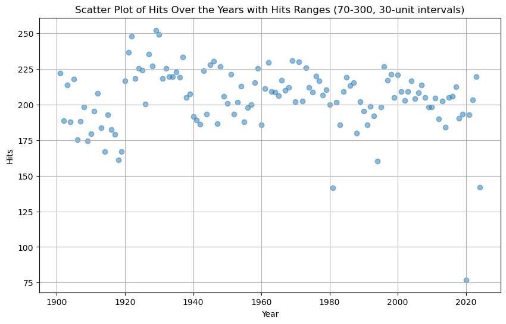

```python
import requests
from bs4 import BeautifulSoup
import pandas as pd
import matplotlib.pyplot as plt
import numpy as np

url = "https://www.baseball-almanac.com/hitting/hihits4.shtml"

# Set a custom user agent
headers = {
    'User-Agent': 'Mozilla/5.0 (Windows NT 10.0; Win64; x64) AppleWebKit/537.36 (KHTML, like Gecko) Chrome/58.0.3029.110 Safari/537.3'}

# Send a GET request to the URL with headers
response = requests.get(url, headers=headers)

# Check if the request was successful (status code 200)
if response.status_code == 200:
    # Parse the HTML content of the page
    soup = BeautifulSoup(response.content, 'html.parser')

    # Find the first table on the page
    table = soup.find('table')

    # Extract data from the table
    table_data = []
    header_found = False

    for row in table.find_all('tr'):
        columns = row.find_all(['th', 'td'])

        # Check if the first column contains a numeric value (indicating a year)
        if columns and columns[0].text.strip().isnumeric():
            year = columns[0].text.strip()

            # Skip rows for years 1876 to 1900
            if 1876 <= int(year) <= 1900:
                continue

        # Check if the row contains the repeated header
        if len(columns) > 2 and 'American League' in columns[1].text.strip() and 'RBI' in columns[2].text.strip():
            header_found = True
            continue  # Skip this row

        if header_found:
            header_found = False
            continue  # Skip the next row after the repeated header

        # Check the length of the columns list
        if len(columns) < 5:
            continue  # Skip this row

        year = columns[4].text.strip()
        player = columns[5].text.strip()
        team = columns[7].text.strip()
        hits = int(columns[6].text.strip()) if columns[6].text.strip().isdigit() else None

        # Exclude the row where the year is 2023 and the player is "American League"
        if year == '2023' and player == 'American League':
            continue

        table_data.append([year, player, team, hits])

    # Create a DataFrame
    df = pd.DataFrame(table_data, columns=['Year', 'Player', 'Team', 'Hits'])

 # Identify rows with non-numeric 'Year' values
    non_numeric_years = df[~df['Year'].str.isnumeric()]

    # Drop rows with non-numeric years
    df = df[df['Year'].str.isnumeric()]

    # Convert 'Year' to numeric values
    df['Year'] = pd.to_numeric(df['Year'])

    # Create bins for the y-axis (Hits) with 30-unit jumps
    bins = range(70, 331, 30)
    labels = [f"{start}-{start + 29}" for start in bins[:-1]]

    df['Hits Range'] = pd.cut(df['Hits'], bins=bins, labels=labels, right=False)

    # Jitter the points within each range
    df['Hits Jittered'] = df.groupby('Hits Range')['Hits'].transform(lambda x: x + np.random.uniform(-5, 5, len(x)))

    # Create a scatter plot with jittered points
    plt.figure(figsize=(10, 6))
    plt.scatter(df['Year'], df['Hits Jittered'], alpha=0.5)
    plt.title('Scatter Plot of Hits Over the Years with Hits Ranges (70-300, 30-unit intervals)')
    plt.xlabel('Year')
    plt.ylabel('Hits')
    plt.grid(True)
    plt.show()

else:
    print(f"Failed to retrieve the webpage. Status code: {response.status_code}")
```

Analysis:

Code for Mean Decade Table of Hits:

```python
import requests
from bs4 import BeautifulSoup
import pandas as pd

url = "https://www.baseball-almanac.com/hitting/hihits4.shtml"

# Set a custom user agent
headers = {
    'User-Agent': 'Mozilla/5.0 (Windows NT 10.0; Win64; x64) AppleWebKit/537.36 (KHTML, like Gecko) Chrome/58.0.3029.110 Safari/537.3'}

# Send a GET request to the URL with headers
response = requests.get(url, headers=headers)

# Check if the request was successful (status code 200)
if response.status_code == 200:
    # Parse the HTML content of the page
    soup = BeautifulSoup(response.content, 'html.parser')

    # Find the first table on the page
    table = soup.find('table')

    # Extract data from the table
    table_data = []
    header_found = False

    for row in table.find_all('tr'):
        columns = row.find_all(['th', 'td'])

        # Check if the first column contains a numeric value (indicating a year)
        if columns and columns[0].text.strip().isnumeric():
            year = columns[0].text.strip()

            # Skip rows for years 1876 to 1900
            if 1876 <= int(year) <= 1900:
                continue

        # Check if the row contains the repeated header
        if len(columns) > 2 and 'American League' in columns[1].text.strip() and 'RBI' in columns[2].text.strip():
            header_found = True
            continue  # Skip this row

        if header_found:
            header_found = False
            continue  # Skip the next row after the repeated header

        # Check the length of the columns list
        if len(columns) < 5:
            continue  # Skip this row

        year = columns[4].text.strip()
        player = columns[5].text.strip()
        team = columns[7].text.strip()
        hits = int(columns[6].text.strip()) if columns[6].text.strip().isdigit() else None

        # Exclude the row where the year is 2023 and the player is "American League"
        if year == '2023' and player == 'American League':
            continue

        table_data.append([year, player, team, hits])

    # Create a DataFrame
    df = pd.DataFrame(table_data, columns=['Year', 'Player', 'Team', 'Hits'])

    # Identify rows with non-numeric 'Year' values
    non_numeric_years = df[~df['Year'].str.isnumeric()]
    if not non_numeric_years.empty:
        print("Rows with non-numeric 'Year' values found:")
        print(non_numeric_years)

    # Drop rows with non-numeric years
    df = df[df['Year'].str.isnumeric()]

    # Convert 'Year' to numeric values
    df['Year'] = pd.to_numeric(df['Year'])

    # Create a new DataFrame with 10-year intervals and calculate the mean for each decade
    df_decades = df.groupby((df['Year'] // 10) * 10)['Hits'].mean().reset_index()

    # Rename the columns
    df_decades.columns = ['Decade', 'Mean Hits']

    print(df_decades)

else:
    print(f"Failed to retrieve the webpage. Status code: {response.status_code}")
```

```
Rows with non-numeric 'Year' values found:
     Year           Player     Team  Hits
0    Year  National League  Team(s)   NaN
125  Year  National League  Team(s)   NaN
    Decade  Mean Hits
0     1900        196
1     1910        181
2     1920        230
3     1930        224
4     1940        206
5     1950        206
6     1960        212
7     1970        213
8     1980        198
9     1990        201
10    2000        209
11    2010        198
12    2020        165
```

Analysis:

This table for the mean hits leader per decade displays the average number of hits from 1900 to 2020. No notable trend can be taken from these means, as they are liable to either rise or fall by the decade.

Code for Line Graph of hits:

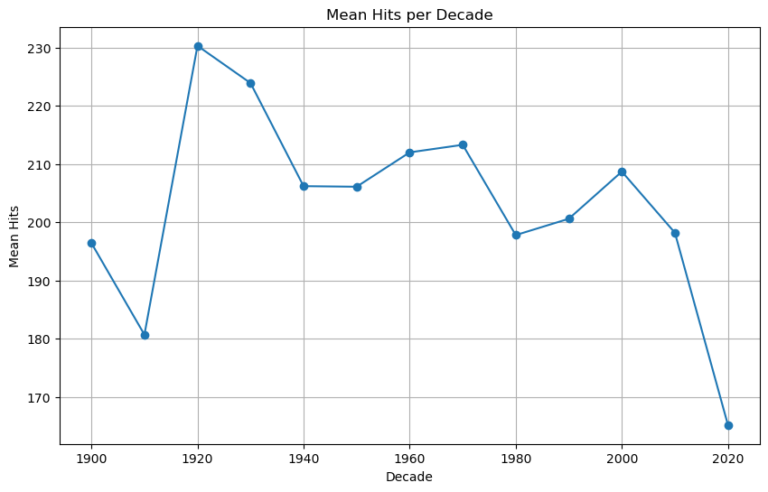

```python
import requests
from bs4 import BeautifulSoup
import pandas as pd
import matplotlib.pyplot as plt

url = "https://www.baseball-almanac.com/hitting/hihits4.shtml"

# Set a custom user agent
headers = {
    'User-Agent': 'Mozilla/5.0 (Windows NT 10.0; Win64; x64) AppleWebKit/537.36 (KHTML, like Gecko) Chrome/58.0.3029.110 Safari/537.3'}

# Send a GET request to the URL with headers
response = requests.get(url, headers=headers)

# Check if the request was successful (status code 200)
if response.status_code == 200:
    # Parse the HTML content of the page
    soup = BeautifulSoup(response.content, 'html.parser')

    # Find the first table on the page
    table = soup.find('table')

    # Extract data from the table
    table_data = []
    header_found = False

    for row in table.find_all('tr'):
        columns = row.find_all(['th', 'td'])

        # Check if the first column contains a numeric value (indicating a year)
        if columns and columns[0].text.strip().isnumeric():
            year = columns[0].text.strip()

            # Skip rows for years 1876 to 1900
            if 1876 <= int(year) <= 1900:
                continue

        # Check if the row contains the repeated header
        if len(columns) > 2 and 'American League' in columns[1].text.strip() and 'RBI' in columns[2].text.strip():
            header_found = True
            continue  # Skip this row

        if header_found:
            header_found = False
            continue  # Skip the next row after the repeated header

        # Check the length of the columns list
        if len(columns) < 5:
            continue  # Skip this row

        year = columns[4].text.strip()
        player = columns[5].text.strip()
        team = columns[7].text.strip()
        hits = int(columns[6].text.strip()) if columns[6].text.strip().isdigit() else None

        # Exclude the row where the year is 2023 and the player is "American League"
        if year == '2023' and player == 'American League':
            continue

        table_data.append([year, player, team, hits])

    # Create a DataFrame
    df = pd.DataFrame(table_data, columns=['Year', 'Player', 'Team', 'Hits'])

    # Identify rows with non-numeric 'Year' values
    non_numeric_years = df[~df['Year'].str.isnumeric()]

    # Drop rows with non-numeric years
    df = df[df['Year'].str.isnumeric()]

    # Convert 'Year' to numeric values
    df['Year'] = pd.to_numeric(df['Year'])

    # Create a new DataFrame with 10-year intervals and calculate the mean for each decade
    df_decades = df.groupby((df['Year'] // 10) * 10)['Hits'].mean().reset_index()

    # Rename the columns
    df_decades.columns = ['Decade', 'Mean Hits']

    # Create a line graph
    plt.figure(figsize=(10, 6))
    plt.plot(df_decades['Decade'], df_decades['Mean Hits'], marker='o', linestyle='-')
    plt.title('Mean Hits per Decade')
    plt.xlabel('Decade')
    plt.ylabel('Mean Hits')
    plt.grid(True)
    plt.show()

else:
    print(f"Failed to retrieve the webpage. Status code: {response.status_code}")
```

Analysis:

This line graph for the mean hits per decades depicts a trend that we can examine. A massive spike can be observed from 1910 to 1920, then declined to 1940. We can see a steady climb in hits towards 1970, then a sizable dip at 1980. Hits then rose steadily until 2000, then dipped again going towards 2020.

Code for Histogram of Hits:

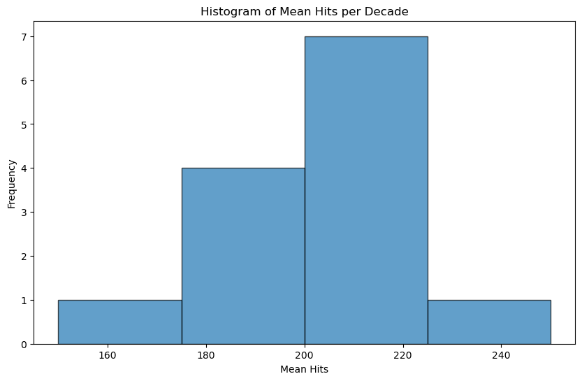

```python
import requests
from bs4 import BeautifulSoup
import pandas as pd
import matplotlib.pyplot as plt

url = "https://www.baseball-almanac.com/hitting/hihits4.shtml"

# Set a custom user agent
headers = {
    'User-Agent': 'Mozilla/5.0 (Windows NT 10.0; Win64; x64) AppleWebKit/537.36 (KHTML, like Gecko) Chrome/58.0.3029.110 Safari/537.3'}

# Send a GET request to the URL with headers
response = requests.get(url, headers=headers)

# Check if the request was successful (status code 200)
if response.status_code == 200:
    # Parse the HTML content of the page
    soup = BeautifulSoup(response.content, 'html.parser')

    # Find the first table on the page
    table = soup.find('table')

    # Extract data from the table
    table_data = []
    header_found = False

    for row in table.find_all('tr'):
        columns = row.find_all(['th', 'td'])

        # Check if the first column contains a numeric value (indicating a year)
        if columns and columns[0].text.strip().isnumeric():
            year = columns[0].text.strip()

            # Skip rows for years 1876 to 1900
            if 1876 <= int(year) <= 1900:
                continue

        # Check if the row contains the repeated header
        if len(columns) > 2 and 'American League' in columns[1].text.strip() and 'RBI' in columns[2].text.strip():
            header_found = True
            continue  # Skip this row

        if header_found:
            header_found = False
            continue  # Skip the next row after the repeated header

        # Check the length of the columns list
        if len(columns) < 5:
            continue  # Skip this row

        year = columns[4].text.strip()
        player = columns[5].text.strip()
        team = columns[7].text.strip()
        hits = int(columns[6].text.strip()) if columns[6].text.strip().isdigit() else None

        # Exclude the row where the year is 2023 and the player is "American League"
        if year == '2023' and player == 'American League':
            continue

        table_data.append([year, player, team, hits])

    # Create a DataFrame
    df = pd.DataFrame(table_data, columns=['Year', 'Player', 'Team', 'Hits'])

 # Identify rows with non-numeric 'Year' values
    non_numeric_years = df[~df['Year'].str.isnumeric()]

    # Drop rows with non-numeric years
    df = df[df['Year'].str.isnumeric()]

    # Convert 'Year' to numeric values
    df['Year'] = pd.to_numeric(df['Year'])

    # Create a new DataFrame with 10-year intervals and calculate the mean for each decade
    df_decades = df.groupby((df['Year'] // 10) * 10)['Hits'].mean().reset_index()

    # Rename the columns
    df_decades.columns = ['Decade', 'Mean Hits']

    # Create a histogram without grid lines
    plt.figure(figsize=(10, 6))
    plt.hist(df_decades['Mean Hits'], bins=range(150, 251, 25), edgecolor='black', alpha=0.7)
    plt.title('Histogram of Mean Hits per Decade')
    plt.xlabel('Mean Hits')
    plt.ylabel('Frequency')
    plt.show()

else:
    print(f"Failed to retrieve the webpage. Status code: {response.status_code}")
```

Analysis:

Code for Boxplot of Hits:

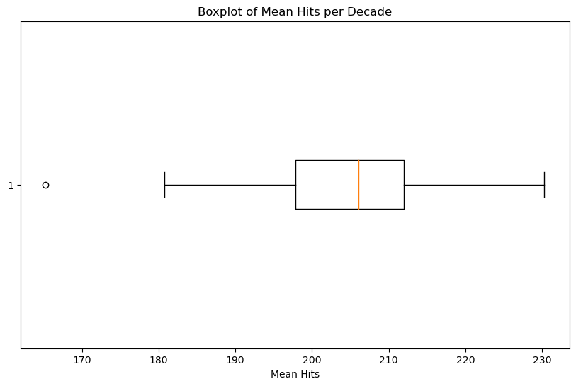

```python
import requests
from bs4 import BeautifulSoup
import pandas as pd
import matplotlib.pyplot as plt

url = "https://www.baseball-almanac.com/hitting/hihits4.shtml"

# Set a custom user agent
headers = {
    'User-Agent': 'Mozilla/5.0 (Windows NT 10.0; Win64; x64) AppleWebKit/537.36 (KHTML, like Gecko) Chrome/58.0.3029.110 Safari/537.3'}

# Send a GET request to the URL with headers
response = requests.get(url, headers=headers)

# Check if the request was successful (status code 200)
if response.status_code == 200:
    # Parse the HTML content of the page
    soup = BeautifulSoup(response.content, 'html.parser')

    # Find the first table on the page
    table = soup.find('table')

    # Extract data from the table
    table_data = []
    header_found = False

    for row in table.find_all('tr'):
        columns = row.find_all(['th', 'td'])

        # Check if the first column contains a numeric value (indicating a year)
        if columns and columns[0].text.strip().isnumeric():
            year = columns[0].text.strip()

            # Skip rows for years 1876 to 1900
            if 1876 <= int(year) <= 1900:
                continue

        # Check if the row contains the repeated header
        if len(columns) > 2 and 'American League' in columns[1].text.strip() and 'RBI' in columns[2].text.strip():
            header_found = True
            continue  # Skip this row

        if header_found:
            header_found = False
            continue  # Skip the next row after the repeated header

        # Check the length of the columns list
        if len(columns) < 5:
            continue  # Skip this row

        year = columns[4].text.strip()
        player = columns[5].text.strip()
        team = columns[7].text.strip()
        hits = int(columns[6].text.strip()) if columns[6].text.strip().isdigit() else None

        # Exclude the row where the year is 2023 and the player is "American League"
        if year == '2023' and player == 'American League':
            continue

        table_data.append([year, player, team, hits])

    # Create a DataFrame
    df = pd.DataFrame(table_data, columns=['Year', 'Player', 'Team', 'Hits'])

 # Identify rows with non-numeric 'Year' values
    non_numeric_years = df[~df['Year'].str.isnumeric()]

    # Drop rows with non-numeric years
    df = df[df['Year'].str.isnumeric()]

    # Convert 'Year' to numeric values
    df['Year'] = pd.to_numeric(df['Year'])

    # Create a new DataFrame with 10-year intervals and calculate the mean for each decade
    df_decades = df.groupby((df['Year'] // 10) * 10)['Hits'].mean().reset_index()

    # Rename the columns
    df_decades.columns = ['Decade', 'Mean Hits']

    # Create a boxplot
    plt.figure(figsize=(10, 6))
    plt.boxplot(df_decades['Mean Hits'], vert=False)
    plt.title('Boxplot of Mean Hits per Decade')
    plt.xlabel('Mean Hits')
    plt.show()

else:
    print(f"Failed to retrieve the webpage. Status code: {response.status_code}")
```

Analysis:

Intro:

One of the baseball stats that we will be using to analyze is ‘Hits Allowed’. Here are some graphs to help an individual visualize the trends in the data of ‘Hits Allowed’.

Code for Scatter plot of Hits allowed:

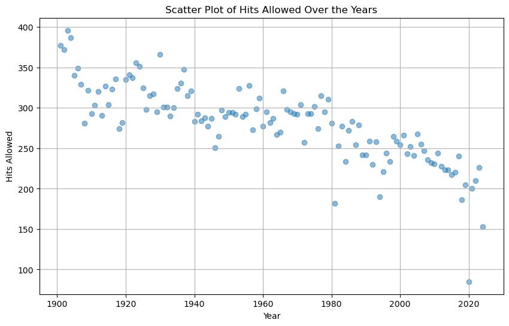

```python
import requests
from bs4 import BeautifulSoup
import pandas as pd
import re
import matplotlib.pyplot as plt

url = 'https://www.baseball-reference.com/leaders/H_p_leagues.shtml'

# Set display option to show integers instead of decimals
pd.set_option('display.float_format', '{:.0f}'.format)

# Send an HTTP request to the URL
response = requests.get(url)

# Check if the request was successful (status code 200)
if response.status_code == 200:
    # Parse the HTML content of the page
    soup = BeautifulSoup(response.text, 'html.parser')

    # Find all tables on the page
    tables = soup.find_all('table')

    # Look for the table that likely contains American League data
    for table in tables:
        # Check if the table has at least 3 columns (assuming it's the right table)
        if len(table.find_all('th')) >= 7:
            # Extract data from the table and create a list of dictionaries
            data = []
            for row in table.find_all('tr')[1:]:  # Skip the header row
                columns = row.find_all(['th', 'td'])
                team = columns[0].text.strip()
                player_name = columns[1].text.strip()
                hits_allowed = int(columns[2].text.strip()) if columns[2].text.strip().isdigit() else None

                # Extract the year using regular expression
                year_match = re.search(r'\b\d{4}\b', team)
                year = int(year_match.group()) if year_match else None

                data.append({'Year': year, 'Player/ Team': player_name, 'Most Hits Allowed': hits_allowed})

            # Create a DataFrame from the list of dictionaries
            df = pd.DataFrame(data)

            # Filter out rows for non-American League teams and create a copy
            df_al = df[df['Year'] >= 1901].copy()

            # Sort the copied DataFrame based on the 'Year' column in ascending order
            df_al.sort_values(by='Year', inplace=True)

            # Reset the index to start from 0
            df_al.reset_index(drop=True, inplace=True)

            # Create 10-year intervals
            df_al['Decade'] = (df_al['Year'] // 10) * 10

            # Group by decade and calculate the mean hits
            df_decade_mean = df_al.groupby('Decade')['Most Hits Allowed'].mean().reset_index()

            # Print the resulting DataFrame with means for each decade

            # Create a scatter plot
            plt.figure(figsize=(10, 6))
            plt.scatter(df_al['Year'], df_al['Most Hits Allowed'], alpha=0.5)
            plt.title('Scatter Plot of Hits Allowed Over the Years')
            plt.xlabel('Year')
            plt.ylabel('Hits Allowed')
            plt.grid(True)
            plt.show()

            # Exit the loop once the desired table is found
            break
    else:
        print('American League section not found or structure has changed.')

else:
    print(f'Error: {response.status_code}')
```

Analysis:

The scatter plot printed above represents the Most Hits Allowed over the years, where each point represents a different player. From the plot, there appears to be a negative correlation between the two variables, meaning that as the year increases, the number of hits allowed decreases. This could be the result of outside variables, such as changes in the rules of baseball or the increase in the skillsets of baseball players.

Code for Mean decade table of Hits allowed:

```python
import requests
from bs4 import BeautifulSoup
import pandas as pd
import re

url = 'https://www.baseball-reference.com/leaders/H_p_leagues.shtml'

# Set display option to show integers instead of decimals
pd.set_option('display.float_format', '{:.0f}'.format)

# Send an HTTP request to the URL
response = requests.get(url)

# Check if the request was successful (status code 200)
if response.status_code == 200:
    # Parse the HTML content of the page
    soup = BeautifulSoup(response.text, 'html.parser')

    # Find all tables on the page
    tables = soup.find_all('table')

    # Look for the table that likely contains American League data
    for table in tables:
        # Check if the table has at least 3 columns (assuming it's the right table)
        if len(table.find_all('th')) >= 7:
            # Extract data from the table and create a list of dictionaries
            data = []
            for row in table.find_all('tr')[1:]:  # Skip the header row
                columns = row.find_all(['th', 'td'])
                team = columns[0].text.strip()
                player_name = columns[1].text.strip()
                hits_allowed = int(columns[2].text.strip()) if columns[2].text.strip().isdigit() else None

                # Extract the year using regular expression
                year_match = re.search(r'\b\d{4}\b', team)
                year = int(year_match.group()) if year_match else None

                data.append({'Year': year, 'Player/ Team': player_name, 'Most Hits Allowed': hits_allowed})

            # Create a DataFrame from the list of dictionaries
            df = pd.DataFrame(data)

            # Filter out rows for non-American League teams and create a copy
            df_al = df[df['Year'] >= 1901].copy()

            # Sort the copied DataFrame based on the 'Year' column in ascending order
            df_al.sort_values(by='Year', inplace=True)

            # Reset the index to start from 0
            df_al.reset_index(drop=True, inplace=True)

            # Create 10-year intervals
            df_al['Decade'] = (df_al['Year'] // 10) * 10

            # Group by decade and calculate the mean hits
            df_decade_mean = df_al.groupby('Decade')['Most Hits Allowed'].mean().reset_index()

            # Print the resulting DataFrame with means for each decade
            print(df_decade_mean)

            # Exit the loop once the desired table is found
            break
    else:
        print('American League section not found or structure has changed.')

else:
    print(f'Error: {response.status_code}')
```

```
    Decade  Most Hits Allowed
0     1900                350
1     1910                305
2     1920                327
3     1930                320
4     1940                281
5     1950                300
6     1960                288
7     1970                294
8     1980                256
9     1990                240
10    2000                249
11    2010                222
12    2020                175
```

Analysis:

The table printed showcases the mean hits allowed for each of the decades starting from 1900 and ending in 2020. This table also shows a relatively negative correlation, where the highest mean hits allowed was in 1900 and the lowest mean hits allowed was in 2020.

Code for line graph of Hits allowed:

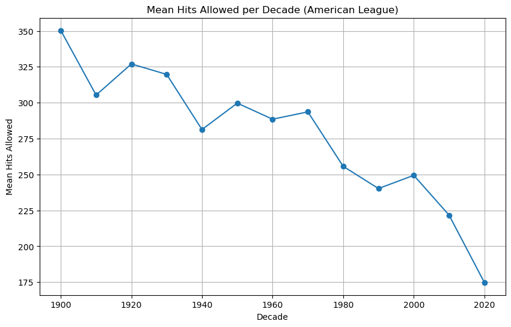

```python
import requests
from bs4 import BeautifulSoup
import pandas as pd
import re
import matplotlib.pyplot as plt

url = 'https://www.baseball-reference.com/leaders/H_p_leagues.shtml'

# Set display option to show integers instead of decimals
pd.set_option('display.float_format', '{:.0f}'.format)

# Send an HTTP request to the URL
response = requests.get(url)

# Check if the request was successful (status code 200)
if response.status_code == 200:
    # Parse the HTML content of the page
    soup = BeautifulSoup(response.text, 'html.parser')

    # Find all tables on the page
    tables = soup.find_all('table')

    # Look for the table that likely contains American League data
    for table in tables:
        # Check if the table has at least 3 columns (assuming it's the right table)
        if len(table.find_all('th')) >= 7:
            # Extract data from the table and create a list of dictionaries
            data = []
            for row in table.find_all('tr')[1:]:  # Skip the header row
                columns = row.find_all(['th', 'td'])
                team = columns[0].text.strip()
                player_name = columns[1].text.strip()
                hits_allowed = int(columns[2].text.strip()) if columns[2].text.strip().isdigit() else None

                # Extract the year using regular expression
                year_match = re.search(r'\b\d{4}\b', team)
                year = int(year_match.group()) if year_match else None

                data.append({'Year': year, 'Player/ Team': player_name, 'Most Hits Allowed': hits_allowed})

            # Create a DataFrame from the list of dictionaries
            df = pd.DataFrame(data)

            # Filter out rows for non-American League teams and create a copy
            df_al = df[df['Year'] >= 1901].copy()

            # Sort the copied DataFrame based on the 'Year' column in ascending order
            df_al.sort_values(by='Year', inplace=True)

            # Reset the index to start from 0
            df_al.reset_index(drop=True, inplace=True)

            # Create 10-year intervals
            df_al['Decade'] = (df_al['Year'] // 10) * 10

            # Group by decade and calculate the mean hits
            df_decade_mean = df_al.groupby('Decade')['Most Hits Allowed'].mean().reset_index()

            # Plotting the line graph
            plt.figure(figsize=(10, 6))
            plt.plot(df_decade_mean['Decade'], df_decade_mean['Most Hits Allowed'], marker='o', linestyle='-')
            plt.title('Mean Hits Allowed per Decade (American League)')
            plt.xlabel('Decade')
            plt.ylabel('Mean Hits Allowed')
            plt.grid(True)
            plt.show()

            # Exit the loop once the desired table is found
            break
    else:
        print('American League section not found or structure has changed.')

else:
    print(f'Error: {response.status_code}')
```

Analysis:

This graph puts the data from the mean hits allowed table into a line graph. In this graph, we can see the mean hits allowed according to the various decades. This reinforces the relatively negative correlation throughout the years.

Code for Histogram of Hits allowed:

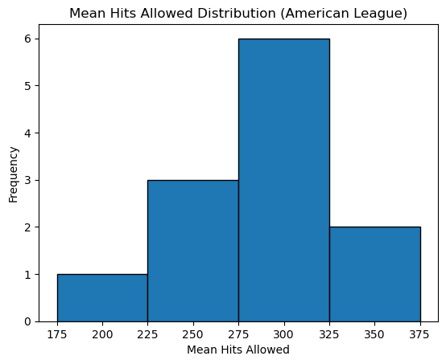

```python
import requests
from bs4 import BeautifulSoup
import pandas as pd
import re
import matplotlib.pyplot as plt

url = 'https://www.baseball-reference.com/leaders/H_p_leagues.shtml'

# Set display option to show integers instead of decimals
pd.set_option('display.float_format', '{:.0f}'.format)

# Send an HTTP request to the URL
response = requests.get(url)

# Check if the request was successful (status code 200)
if response.status_code == 200:
    # Parse the HTML content of the page
    soup = BeautifulSoup(response.text, 'html.parser')

    # Find all tables on the page
    tables = soup.find_all('table')

    # Look for the table that likely contains American League data
    for table in tables:
        # Check if the table has at least 3 columns (assuming it's the right table)
        if len(table.find_all('th')) >= 7:
            # Extract data from the table and create a list of dictionaries
            data = []
            for row in table.find_all('tr')[1:]:  # Skip the header row
                columns = row.find_all(['th', 'td'])
                team = columns[0].text.strip()
                player_name = columns[1].text.strip()
                hits_allowed = int(columns[2].text.strip()) if columns[2].text.strip().isdigit() else None

                # Extract the year using regular expression
                year_match = re.search(r'\b\d{4}\b', team)
                year = int(year_match.group()) if year_match else None

                data.append({'Year': year, 'Player/ Team': player_name, 'Most Hits Allowed': hits_allowed})

            # Create a DataFrame from the list of dictionaries
            df = pd.DataFrame(data)

            # Filter out rows for non-American League teams and create a copy
            df_al = df[df['Year'] >= 1901].copy()

            # Sort the copied DataFrame based on the 'Year' column in ascending order
            df_al.sort_values(by='Year', inplace=True)

            # Reset the index to start from 0
            df_al.reset_index(drop=True, inplace=True)

            # Create 10-year intervals
            df_al['Decade'] = (df_al['Year'] // 10) * 10

            # Group by decade and calculate the mean hits
            df_decade_mean = df_al.groupby('Decade')['Most Hits Allowed'].mean().reset_index()

            # Plotting the histogram using mean hits for each decade
            plt.hist(df_decade_mean['Most Hits Allowed'], bins=range(175, 376, 50), edgecolor='black')
            plt.title('Mean Hits Allowed Distribution (American League)')
            plt.xlabel('Mean Hits Allowed')
            plt.ylabel('Frequency')
            plt.show()

            # Exit the loop once the desired table is found
            break
    else:
        print('American League section not found or structure has changed.')

else:
    print(f'Error: {response.status_code}')
```

Analysis:

Code for Boxplot of Hits allowed:

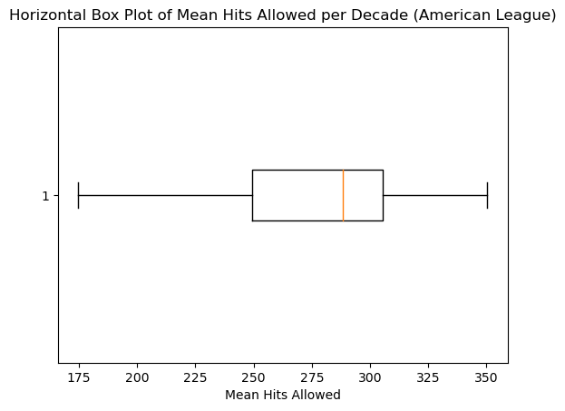

```python
import requests
from bs4 import BeautifulSoup
import pandas as pd
import re
import matplotlib.pyplot as plt

url = 'https://www.baseball-reference.com/leaders/H_p_leagues.shtml'

# Set display option to show integers instead of decimals
pd.set_option('display.float_format', '{:.0f}'.format)

# Send an HTTP request to the URL
response = requests.get(url)

# Check if the request was successful (status code 200)
if response.status_code == 200:
    # Parse the HTML content of the page
    soup = BeautifulSoup(response.text, 'html.parser')

    # Find all tables on the page
    tables = soup.find_all('table')

    # Look for the table that likely contains American League data
    for table in tables:
        # Check if the table has at least 3 columns (assuming it's the right table)
        if len(table.find_all('th')) >= 7:
            # Extract data from the table and create a list of dictionaries
            data = []
            for row in table.find_all('tr')[1:]:  # Skip the header row
                columns = row.find_all(['th', 'td'])
                team = columns[0].text.strip()
                player_name = columns[1].text.strip()
                hits_allowed = int(columns[2].text.strip()) if columns[2].text.strip().isdigit() else None

                # Extract the year using regular expression
                year_match = re.search(r'\b\d{4}\b', team)
                year = int(year_match.group()) if year_match else None

                data.append({'Year': year, 'Player/ Team': player_name, 'Most Hits Allowed': hits_allowed})

            # Create a DataFrame from the list of dictionaries
            df = pd.DataFrame(data)

            # Filter out rows for non-American League teams and create a copy
            df_al = df[df['Year'] >= 1901].copy()

            # Sort the copied DataFrame based on the 'Year' column in ascending order
            df_al.sort_values(by='Year', inplace=True)

            # Reset the index to start from 0
            df_al.reset_index(drop=True, inplace=True)

            # Create 10-year intervals
            df_al['Decade'] = (df_al['Year'] // 10) * 10

            # Group by decade and calculate the mean hits
            df_decade_mean = df_al.groupby('Decade')['Most Hits Allowed'].mean().reset_index()

            # Plotting the horizontal box plot for hits allowed
            plt.boxplot(df_decade_mean['Most Hits Allowed'], vert=False)
            plt.title('Horizontal Box Plot of Mean Hits Allowed per Decade (American League)')
            plt.xlabel('Mean Hits Allowed')
            plt.show()

            # Exit the loop once the desired table is found
            break
    else:
        print('American League section not found or structure has changed.')

else:
    print(f'Error: {response.status_code}')
```

Analysis:

From this boxplot, we can make some general notes from it. First off, we can see that there are no outliers in terms of the mean hits allowed per decade. We can also see that the range for the hits allowed through the 13 decades is about 170. Lastly, we can see that the mean is on the higher side of the data which means the means are most likely skewed left.

Hits Allowed Visualizations Summary: When looking at the hits allowed visuals, it was very interesting to see how it contradicted the findings in the previous section. This can be said because one would think that if the league leader in hits had a neutral correlation for the most part, then the league leader in hits allowed would also be neutral. Through our findings in the various graphs and tables for hits allowed, we saw that in the scatterplot and line graph, there was an obvious negative trend. This means that if the league leader in hits allowed decreased over time, then we would expect the hits leader to also decrease, but as we saw earlier, that was not the case. Although when looking at the line graph for hits allowed, there are some years where there is a slight increase, but most years it either slightly drops, or significantly drops. As far as only the hits allowed, we can conclude there is a negative correlation, but when looking at how the hits and hits allowed leaders compare over time, there is no definitive answer to the correlation of the two.

Intro:

This section aims to discuss the trends in our data for the walks statistic over decades, looking at various plots by which the visualization of will reveal trends.

Code for Scatter plot of Walks:

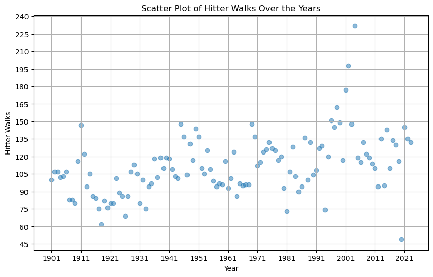

```python
import requests
from bs4 import BeautifulSoup
import pandas as pd
import matplotlib.pyplot as plt

url = "https://www.baseball-almanac.com/hitting/hiwalk4.shtml"

# Set a custom user agent
headers = {
    'User-Agent': 'Mozilla/5.0 (Windows NT 10.0; Win64; x64) AppleWebKit/537.36 (KHTML, like Gecko) Chrome/58.0.3029.110 Safari/537.3'}

# Send a GET request to the URL with headers
response = requests.get(url, headers=headers)

# Check if the request was successful (status code 200)
if response.status_code == 200:
    # Parse the HTML content of the page
    soup = BeautifulSoup(response.content, 'html.parser')

    # Find the first table on the page
    table = soup.find('table')

    # Extract data from the table
    table_data = []
    header_found = False

    for row in table.find_all('tr'):
        columns = row.find_all(['th', 'td'])

        # Check if the first column contains a numeric value (indicating a year)
        if columns and columns[0].text.strip().isnumeric():
            year = columns[0].text.strip()

            if 1876 <= int(year) <= 1900:
                continue  # Skip this row

        # Check if the row contains the repeated header
        if len(columns) > 2 and 'American League' in columns[1].text.strip() and 'RBI' in columns[2].text.strip():
            header_found = True
            continue  # Skip this row

        if header_found:
            header_found = False
            continue  # Skip the next row after the repeated header

        # Check the length of the columns list
        if len(columns) < 5:
            continue  # Skip this row

        player = columns[5].text.strip()
        team = columns[7].text.strip()
        hitter_walks = int(columns[6].text.strip()) if columns[6].text.strip().isdigit() else None

        # Exclude the row where the year is 2023 and the player is "American League"
        if year == '2023' and player == 'American League':
            continue

        table_data.append([year, player, team, hitter_walks])

    # Create a DataFrame
    df = pd.DataFrame(table_data, columns=['Year', 'Player', 'Team', 'Hitter Walks'])

    df = df.drop([0, 124]).reset_index(drop=True)

    # Convert 'Year' to numeric values
    df['Year'] = pd.to_numeric(df['Year'])

    # Create a scatter plot
    plt.figure(figsize=(10, 6))
    plt.scatter(df['Year'], df['Hitter Walks'], alpha=0.5)
    plt.title('Scatter Plot of Hitter Walks Over the Years')
    plt.xlabel('Year')
    plt.ylabel('Hitter Walks')
    plt.xticks(range(1901, 2024, 10))
    plt.yticks(range(45, 250, 15))
    plt.grid(True)
    plt.show()

else:
    print(f'Failed to retrieve the webpage. Status code: {response.status_code}')
```

Analysis:

This scatter plot represents hitter walks over the years, where each each point represents a different player. There appears to be a slight positive correlation between year and hitter walks. This means that as the year increases, the number of hitter walks also increases.

Code for mean decade table of Walks:

```python
import requests
from bs4 import BeautifulSoup
import pandas as pd

url = "https://www.baseball-almanac.com/hitting/hiwalk4.shtml"

# Set a custom user agent
headers = {
    'User-Agent': 'Mozilla/5.0 (Windows NT 10.0; Win64; x64) AppleWebKit/537.36 (KHTML, like Gecko) Chrome/58.0.3029.110 Safari/537.3'}

# Send a GET request to the URL with headers
response = requests.get(url, headers=headers)

# Check if the request was successful (status code 200)
if response.status_code == 200:
    # Parse the HTML content of the page
    soup = BeautifulSoup(response.content, 'html.parser')

    # Find the first table on the page
    table = soup.find('table')

    # Extract data from the table
    table_data = []
    header_found = False

    for row in table.find_all('tr'):
        columns = row.find_all(['th', 'td'])

        # Check if the first column contains a numeric value (indicating a year)
        if columns and columns[0].text.strip().isnumeric():
            year = columns[0].text.strip()

            if 1876 <= int(year) <= 1900:
                continue  # Skip this row

        # Check if the row contains the repeated header
        if len(columns) > 2 and 'American League' in columns[1].text.strip() and 'RBI' in columns[2].text.strip():
            header_found = True
            continue  # Skip this row

        if header_found:
            header_found = False
            continue  # Skip the next row after the repeated header

        # Check the length of the columns list
        if len(columns) < 5:
            continue  # Skip this row

        player = columns[5].text.strip()
        team = columns[7].text.strip()
        hitter_walks = int(columns[6].text.strip()) if columns[6].text.strip().isdigit() else None

        # Exclude the row where the year is 2023 and the player is "American League"
        if year == '2023' and player == 'American League':
            continue

        table_data.append([year, player, team, hitter_walks])

    # Create a DataFrame
    df = pd.DataFrame(table_data, columns=['Year', 'Player', 'Team', 'Hitter Walks'])

    df = df.drop([0, 124]).reset_index(drop=True)

    # Convert 'Year' to numeric values
    df['Year'] = pd.to_numeric(df['Year'])

    # Create a new DataFrame with 10-year intervals and calculate the mean for each decade
    df_decades = df.groupby((df['Year'] // 10) * 10)['Hitter Walks'].mean().reset_index()

    # Rename the columns
    df_decades.columns = ['Decade', 'Mean Walks']

    # Print the resulting DataFrame with means for each decade
    print(df_decades)

else:
    print(f"Failed to retrieve the webpage. Status code: {response.status_code}")
```

```
    Decade  Mean Walks
0     1900          97
1     1910          97
2     1920          89
3     1930         100
4     1940         119
5     1950         112
6     1960         105
7     1970         124
8     1980         106
9     1990         127
10    2000         148
11    2010         118
12    2020         115
```

Analysis:

We are able to identify an interesting trend in the data by looking at the mean walks per decade in this table. Despite the 2020s having the 2020 year in which all statistics were down due to the shortened season, it still has a higher mean walks than seven of the other decades, which is interesting considering it has 3 full years and 1 very short year, as opposed to most other decades that basically have 10 full seasons in them.

Code for Line Graph of Walks:

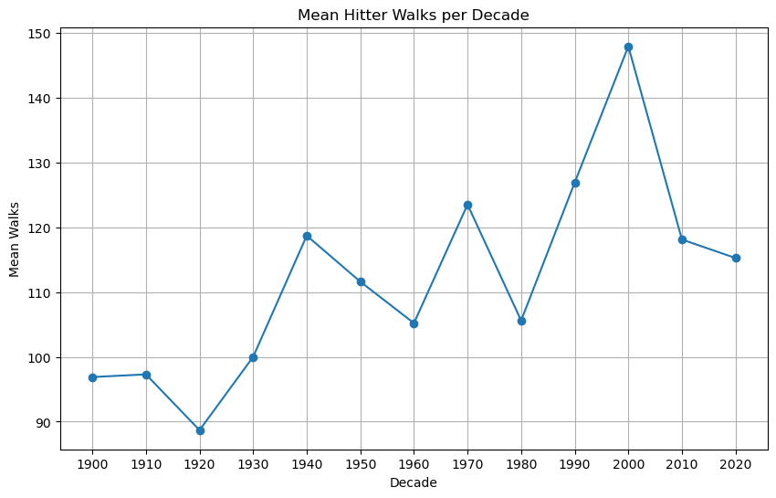

```python
import requests
from bs4 import BeautifulSoup
import pandas as pd
import matplotlib.pyplot as plt

url = "https://www.baseball-almanac.com/hitting/hiwalk4.shtml"

# Set a custom user agent
headers = {
    'User-Agent': 'Mozilla/5.0 (Windows NT 10.0; Win64; x64) AppleWebKit/537.36 (KHTML, like Gecko) Chrome/58.0.3029.110 Safari/537.3'}

# Send a GET request to the URL with headers
response = requests.get(url, headers=headers)

# Check if the request was successful (status code 200)
if response.status_code == 200:
    # Parse the HTML content of the page
    soup = BeautifulSoup(response.content, 'html.parser')

    # Find the first table on the page
    table = soup.find('table')

    # Extract data from the table
    table_data = []
    header_found = False

    for row in table.find_all('tr'):
        columns = row.find_all(['th', 'td'])

        # Check if the first column contains a numeric value (indicating a year)
        if columns and columns[0].text.strip().isnumeric():
            year = columns[0].text.strip()

            if 1876 <= int(year) <= 1900:
                continue  # Skip this row

        # Check if the row contains the repeated header
        if len(columns) > 2 and 'American League' in columns[1].text.strip() and 'RBI' in columns[2].text.strip():
            header_found = True
            continue  # Skip this row

        if header_found:
            header_found = False
            continue  # Skip the next row after the repeated header

        # Check the length of the columns list
        if len(columns) < 5:
            continue  # Skip this row

        player = columns[5].text.strip()
        team = columns[7].text.strip()
        hitter_walks = int(columns[6].text.strip()) if columns[6].text.strip().isdigit() else None

        # Exclude the row where the year is 2023 and the player is "American League"
        if year == '2023' and player == 'American League':
            continue

        table_data.append([year, player, team, hitter_walks])

    # Create a DataFrame
    df = pd.DataFrame(table_data, columns=['Year', 'Player', 'Team', 'Hitter Walks'])

    df = df.drop([0, 124]).reset_index(drop=True)

    # Convert 'Year' to numeric values
    df['Year'] = pd.to_numeric(df['Year'])

    # Create a new DataFrame with 10-year intervals and calculate the mean for each decade
    df_decades = df.groupby((df['Year'] // 10) * 10)['Hitter Walks'].mean().reset_index()

    # Rename the columns
    df_decades.columns = ['Decade', 'Mean Walks']

    # Create a line graph
    plt.figure(figsize=(10, 6))
    plt.plot(df_decades['Decade'], df_decades['Mean Walks'], marker='o', linestyle='-')
    plt.title('Mean Hitter Walks per Decade')
    plt.xlabel('Decade')
    plt.ylabel('Mean Walks')
    plt.xticks(df_decades['Decade'])
    plt.grid(True)
    plt.show()

else:
    print(f"Failed to retrieve the webpage. Status code: {response.status_code}")
```

Analysis:

This line graph for the mean walks leader per decade shows a fluctuating upward trend that culminates in an all-time peak for the 2000s at roughly 147 walks. We can explain the dip by the 2020s with the shortened season, but even that currently 4-year decade is higher than most other decades in the graph.

Code for Histogram of Walks:

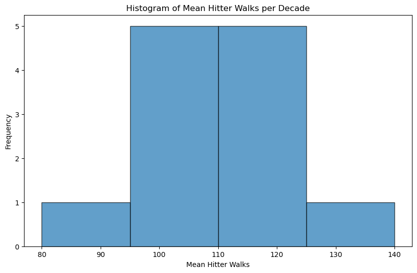

```python
import requests
from bs4 import BeautifulSoup
import pandas as pd
import matplotlib.pyplot as plt

url = "https://www.baseball-almanac.com/hitting/hiwalk4.shtml"

# Set a custom user agent
headers = {
    'User-Agent': 'Mozilla/5.0 (Windows NT 10.0; Win64; x64) AppleWebKit/537.36 (KHTML, like Gecko) Chrome/58.0.3029.110 Safari/537.3'}

# Send a GET request to the URL with headers
response = requests.get(url, headers=headers)

# Check if the request was successful (status code 200)
if response.status_code == 200:
    # Parse the HTML content of the page
    soup = BeautifulSoup(response.content, 'html.parser')

    # Find the first table on the page
    table = soup.find('table')

    # Extract data from the table
    table_data = []
    header_found = False

    for row in table.find_all('tr'):
        columns = row.find_all(['th', 'td'])

        # Check if the first column contains a numeric value (indicating a year)
        if columns and columns[0].text.strip().isnumeric():
            year = columns[0].text.strip()

            if 1876 <= int(year) <= 1900:
                continue  # Skip this row

        # Check if the row contains the repeated header
        if len(columns) > 2 and 'American League' in columns[1].text.strip() and 'RBI' in columns[2].text.strip():
            header_found = True
            continue  # Skip this row

        if header_found:
            header_found = False
            continue  # Skip the next row after the repeated header

        # Check the length of the columns list
        if len(columns) < 5:
            continue  # Skip this row

        player = columns[5].text.strip()
        team = columns[7].text.strip()
        hitter_walks = int(columns[6].text.strip()) if columns[6].text.strip().isdigit() else None

        # Exclude the row where the year is 2023 and the player is "American League"
        if year == '2023' and player == 'American League':
            continue

        table_data.append([year, player, team, hitter_walks])

    # Create a DataFrame
    df = pd.DataFrame(table_data, columns=['Year', 'Player', 'Team', 'Hitter Walks'])

    df = df.drop([0, 124]).reset_index(drop=True)

    # Convert 'Year' to numeric values
    df['Year'] = pd.to_numeric(df['Year'])

    # Create a new DataFrame with 10-year intervals and calculate the mean for each decade
    df_decades = df.groupby((df['Year'] // 10) * 10)['Hitter Walks'].mean().reset_index()

    # Rename the columns
    df_decades.columns = ['Decade', 'Mean Walks']

    # Create a histogram using mean walks per decade
    plt.figure(figsize=(10, 6))
    plt.hist(df_decades['Mean Walks'], bins=range(80, 151, 15), edgecolor='black', alpha=0.7)
    plt.title('Histogram of Mean Hitter Walks per Decade')
    plt.xlabel('Mean Hitter Walks')
    plt.ylabel('Frequency')
    plt.show()

else:
    print(f"Failed to retrieve the webpage. Status code: {response.status_code}")
```

This histogram depicts a normal, symmetrical distribution of mean hitter walks and their frequency through the decades. There are five decades each that have mean hitter walks of about 95 to 125.

Code for Boxplot of Walks:

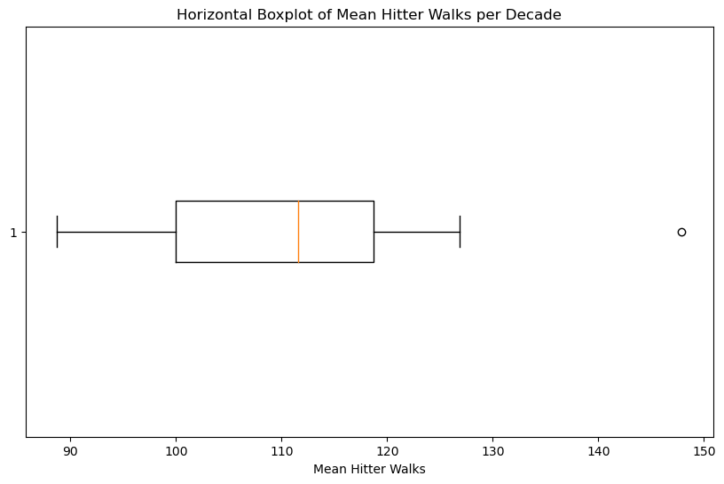

```python
import requests
from bs4 import BeautifulSoup
import pandas as pd
import matplotlib.pyplot as plt

url = "https://www.baseball-almanac.com/hitting/hiwalk4.shtml"

# Set a custom user agent
headers = {
    'User-Agent': 'Mozilla/5.0 (Windows NT 10.0; Win64; x64) AppleWebKit/537.36 (KHTML, like Gecko) Chrome/58.0.3029.110 Safari/537.3'}

# Send a GET request to the URL with headers
response = requests.get(url, headers=headers)

# Check if the request was successful (status code 200)
if response.status_code == 200:
    # Parse the HTML content of the page
    soup = BeautifulSoup(response.content, 'html.parser')

    # Find the first table on the page
    table = soup.find('table')

    # Extract data from the table
    table_data = []
    header_found = False

    for row in table.find_all('tr'):
        columns = row.find_all(['th', 'td'])

        # Check if the first column contains a numeric value (indicating a year)
        if columns and columns[0].text.strip().isnumeric():
            year = columns[0].text.strip()

            if 1876 <= int(year) <= 1900:
                continue  # Skip this row

        # Check if the row contains the repeated header
        if len(columns) > 2 and 'American League' in columns[1].text.strip() and 'RBI' in columns[2].text.strip():
            header_found = True
            continue  # Skip this row

        if header_found:
            header_found = False
            continue  # Skip the next row after the repeated header

        # Check the length of the columns list
        if len(columns) < 5:
            continue  # Skip this row

        player = columns[5].text.strip()
        team = columns[7].text.strip()
        hitter_walks = int(columns[6].text.strip()) if columns[6].text.strip().isdigit() else None

        # Exclude the row where the year is 2023 and the player is "American League"
        if year == '2023' and player == 'American League':
            continue

        table_data.append([year, player, team, hitter_walks])

    # Create a DataFrame
    df = pd.DataFrame(table_data, columns=['Year', 'Player', 'Team', 'Hitter Walks'])

    df = df.drop([0, 124]).reset_index(drop=True)

    # Convert 'Year' to numeric values
    df['Year'] = pd.to_numeric(df['Year'])

    # Create a new DataFrame with 10-year intervals and calculate the mean for each decade
    df_decades = df.groupby((df['Year'] // 10) * 10)['Hitter Walks'].mean().reset_index()

    # Rename the columns
    df_decades.columns = ['Decade', 'Mean Walks']

    # Create a horizontal boxplot using mean walks per decade
    plt.figure(figsize=(10, 6))
    plt.boxplot(df_decades['Mean Walks'], vert=False)
    plt.title('Horizontal Boxplot of Mean Hitter Walks per Decade')
    plt.xlabel('Mean Hitter Walks')
    plt.show()

else:
    print(f"Failed to retrieve the webpage. Status code: {response.status_code}")
```

Analysis:

This boxplot highlights the one outlier in this right-skewed distribution at roughly 147 walks. We can also see that the mean of this distribution is about 112.

Walks Visualizations Summary: Through looking at the various graphs for batter walks per decade, each visual hinted at a slight positive trend. This means that as time goes, the league leader in batter walks also increases. This slight positive trend was first seen in the scatterplot with a few very large spikes in the early 2000’s. This slight positive trend also continued by looking at the mean walks per decade along with the line graph for the means where a general positive trend can be seen. When looking at the histogram, it was perfectly symmetric, so not much could be concluded from that, but when analyzing the boxplot, we can see an obvious outlier along with the mean being on the right side which shows a slight positive relationship.

Intro:

This section will now take a look at the pitching side of walks: walks allowed. We will look at trends and display them through various graphs.

Code for Scatter plot of Walks allowed:

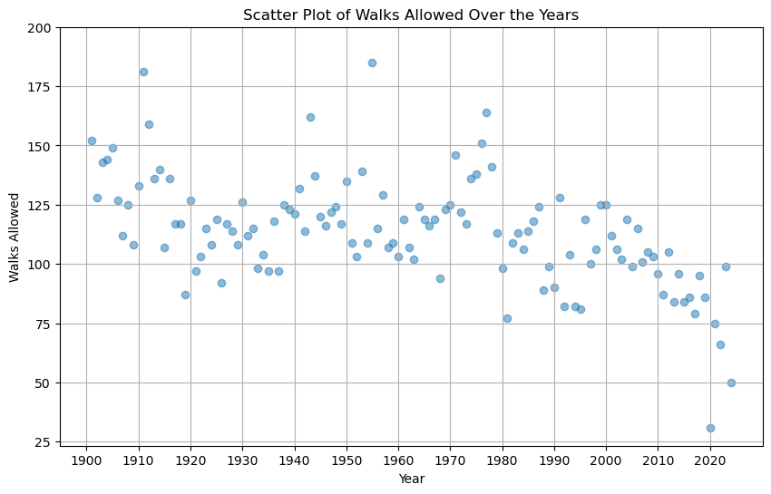

```python
import requests
from bs4 import BeautifulSoup
import pandas as pd
import matplotlib.pyplot as plt
import re

url = 'https://www.baseball-reference.com/leaders/BB_p_leagues.shtml'

# Set display option to show integers instead of decimals
pd.set_option('display.float_format', '{:.0f}'.format)

# Send an HTTP request to the URL
response = requests.get(url)

# Check if the request was successful (status code 200)
if response.status_code == 200:
    # Parse the HTML content of the page
    soup = BeautifulSoup(response.text, 'html.parser')

    # Find all tables on the page
    tables = soup.find_all('table')

    # Look for the table that likely contains American League data
    for table in tables:
        # Check if the table has at least 3 columns (assuming it's the right table)
        if len(table.find_all('th')) >= 7:
            # Extract data from the table and create a list of dictionaries
            data = []
            for row in table.find_all('tr')[1:]:  # Skip the header row
                columns = row.find_all(['th', 'td'])
                team = columns[0].text.strip()
                player_name = columns[1].text.strip()
                walks_allowed = int(columns[2].text.strip()) if columns[2].text.strip().isdigit() else None

                # Extract the year using regular expression
                year_match = re.search(r'\b\d{4}\b', team)
                year = int(year_match.group()) if year_match else None

                data.append({'Year': year, 'Player/ Team': player_name, 'Most Walks Allowed': walks_allowed})

            # Create a DataFrame from the list of dictionaries
            df = pd.DataFrame(data)

            # Filter out rows for non-American League teams and create a copy
            df_al = df[df['Year'] >= 1901].copy()

            # Sort the copied DataFrame based on the 'Year' column in ascending order
            df_al.sort_values(by='Year', inplace=True)

            # Reset the index to start from 0
            df_al.reset_index(drop=True, inplace=True)

            # Create a scatter plot
            plt.figure(figsize=(10, 6))
            plt.scatter(df_al['Year'], df_al['Most Walks Allowed'], alpha=0.5)
            plt.title('Scatter Plot of Walks Allowed Over the Years')
            plt.xlabel('Year')
            plt.ylabel('Walks Allowed')
            plt.xticks(range(1900, 2025, 10))  # Set x-axis ticks to 10-year intervals
            plt.yticks(range(25, 225, 25))  # Set y-axis ticks to start at 25 and go up to 200 in 25-walk intervals
            plt.grid(True)
            plt.show()

            # Exit the loop once the desired table is found
            break
    else:
        print('American League section not found or structure has changed.')

else:
    print(f'Error: {response.status_code}')
```

Analysis:

From observing this scatterplot, we see that the walks allowed statistic has fluctuated steadily through the decades. We can identify peaks around 1911, 1955, and 1976, valleys at 1919, 1981, and 2022, and an outlier at 2020, the COVID-19 shortened season.

Code for Mean Decade Table of Walks allowed:

```python
import requests
from bs4 import BeautifulSoup
import pandas as pd
import re

url = 'https://www.baseball-reference.com/leaders/BB_p_leagues.shtml'

# Set display option to show integers instead of decimals
pd.set_option('display.float_format', '{:.0f}'.format)

# Send an HTTP request to the URL
response = requests.get(url)

# Check if the request was successful (status code 200)
if response.status_code == 200:
    # Parse the HTML content of the page
    soup = BeautifulSoup(response.text, 'html.parser')

    # Find all tables on the page
    tables = soup.find_all('table')

    # Look for the table that likely contains American League data
    for table in tables:
        # Check if the table has at least 3 columns (assuming it's the right table)
        if len(table.find_all('th')) >= 7:
            # Extract data from the table and create a list of dictionaries
            data = []
            for row in table.find_all('tr')[1:]:  # Skip the header row
                columns = row.find_all(['th', 'td'])
                team = columns[0].text.strip()
                player_name = columns[1].text.strip()
                walks_allowed = int(columns[2].text.strip()) if columns[2].text.strip().isdigit() else None

                # Extract the year using regular expression
                year_match = re.search(r'\b\d{4}\b', team)
                year = int(year_match.group()) if year_match else None

                data.append({'Year': year, 'Player/ Team': player_name, 'Most Walks Allowed': walks_allowed})

            # Create a DataFrame from the list of dictionaries
            df = pd.DataFrame(data)

            # Filter out rows for non-American League teams and create a copy
            df_al = df[df['Year'] >= 1901].copy()

            # Sort the copied DataFrame based on the 'Year' column in ascending order
            df_al.sort_values(by='Year', inplace=True)

            # Reset the index to start from 0
            df_al.reset_index(drop=True, inplace=True)

            # Create 10-year intervals
            df_al['Decade'] = (df_al['Year'] // 10) * 10

            # Group by decade and calculate the mean walks allowed
            df_decade_mean = df_al.groupby('Decade')['Most Walks Allowed'].mean().reset_index()

            # Print the resulting DataFrame with means for each decade
            print(df_decade_mean)

            # Exit the loop once the desired table is found
            break
    else:
        print('American League section not found or structure has changed.')

else:
    print(f'Error: {response.status_code}')
```

```
    Decade  Most Walks Allowed
0     1900                 132
1     1910                 131
2     1920                 110
3     1930                 112
4     1940                 126
5     1950                 124
6     1960                 113
7     1970                 135
8     1980                 105
9     1990                 102
10    2000                 109
11    2010                  90
12    2020                  64
```

Analysis:

Code for Line Graph of Walks allowed:

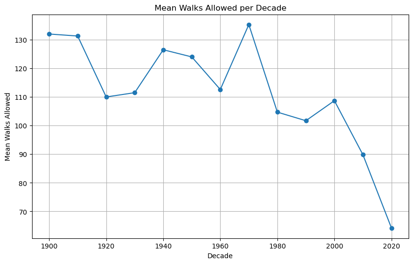

```python
import requests
from bs4 import BeautifulSoup
import pandas as pd
import re
import matplotlib.pyplot as plt

url = 'https://www.baseball-reference.com/leaders/BB_p_leagues.shtml'

# Set display option to show integers instead of decimals
pd.set_option('display.float_format', '{:.0f}'.format)

# Send an HTTP request to the URL
response = requests.get(url)

# Check if the request was successful (status code 200)
if response.status_code == 200:
    # Parse the HTML content of the page
    soup = BeautifulSoup(response.text, 'html.parser')

    # Find all tables on the page
    tables = soup.find_all('table')

    # Look for the table that likely contains American League data
    for table in tables:
        # Check if the table has at least 3 columns (assuming it's the right table)
        if len(table.find_all('th')) >= 7:
            # Extract data from the table and create a list of dictionaries
            data = []
            for row in table.find_all('tr')[1:]:  # Skip the header row
                columns = row.find_all(['th', 'td'])
                team = columns[0].text.strip()
                player_name = columns[1].text.strip()
                walks_allowed = int(columns[2].text.strip()) if columns[2].text.strip().isdigit() else None

                # Extract the year using regular expression
                year_match = re.search(r'\b\d{4}\b', team)
                year = int(year_match.group()) if year_match else None

                data.append({'Year': year, 'Player/ Team': player_name, 'Most Walks Allowed': walks_allowed})

            # Create a DataFrame from the list of dictionaries
            df = pd.DataFrame(data)

            # Filter out rows for non-American League teams and create a copy
            df_al = df[df['Year'] >= 1901].copy()

            # Sort the copied DataFrame based on the 'Year' column in ascending order
            df_al.sort_values(by='Year', inplace=True)

            # Reset the index to start from 0
            df_al.reset_index(drop=True, inplace=True)

            # Create 10-year intervals
            df_al['Decade'] = (df_al['Year'] // 10) * 10

            # Group by decade and calculate the mean walks allowed
            df_decade_mean = df_al.groupby('Decade')['Most Walks Allowed'].mean().reset_index()

            # Create a line graph
            plt.figure(figsize=(10, 6))
            plt.plot(df_decade_mean['Decade'], df_decade_mean['Most Walks Allowed'], marker='o')
            plt.title('Mean Walks Allowed per Decade')
            plt.xlabel('Decade')
            plt.ylabel('Mean Walks Allowed')
            plt.grid(True)
            plt.show()

            # Exit the loop once the desired table is found
            break
    else:
        print('American League section not found or structure has changed.')

else:
    print(f'Error: {response.status_code}')
```

Analysis:

Observing this line graph for the mean walks allowed per decade, we get an even better visualization of the aforementioned dip in mean walks allowed from the high for the 1970s to the 2010s. We can also see the how the data declines from 1910 to 1920, rises from 1920 to 1940, declines again, and rises to that high for the 1970s.

Code for Histogram of Walks allowed:

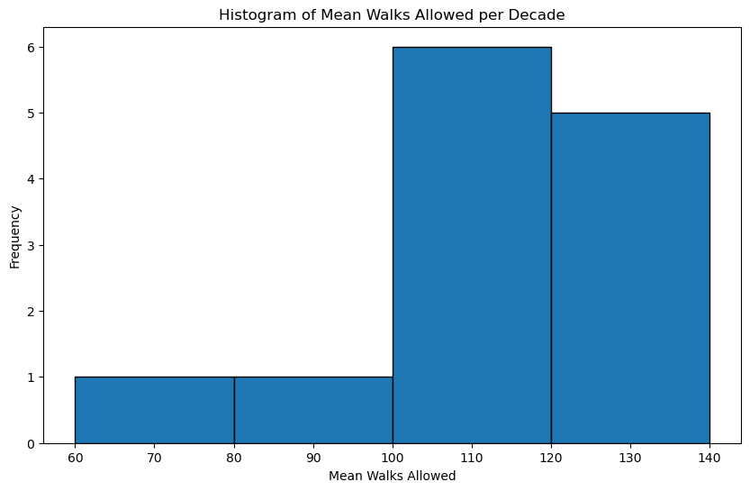

```python
import requests
from bs4 import BeautifulSoup
import pandas as pd
import re
import matplotlib.pyplot as plt

url = 'https://www.baseball-reference.com/leaders/BB_p_leagues.shtml'

# Set display option to show integers instead of decimals
pd.set_option('display.float_format', '{:.0f}'.format)

# Send an HTTP request to the URL
response = requests.get(url)

# Check if the request was successful (status code 200)
if response.status_code == 200:
    # Parse the HTML content of the page
    soup = BeautifulSoup(response.text, 'html.parser')

    # Find all tables on the page
    tables = soup.find_all('table')

    # Look for the table that likely contains American League data
    for table in tables:
        # Check if the table has at least 3 columns (assuming it's the right table)
        if len(table.find_all('th')) >= 7:
            # Extract data from the table and create a list of dictionaries
            data = []
            for row in table.find_all('tr')[1:]:  # Skip the header row
                columns = row.find_all(['th', 'td'])
                team = columns[0].text.strip()
                player_name = columns[1].text.strip()
                walks_allowed = int(columns[2].text.strip()) if columns[2].text.strip().isdigit() else None

                # Extract the year using regular expression
                year_match = re.search(r'\b\d{4}\b', team)
                year = int(year_match.group()) if year_match else None

                data.append({'Year': year, 'Player/ Team': player_name, 'Most Walks Allowed': walks_allowed})

            # Create a DataFrame from the list of dictionaries
            df = pd.DataFrame(data)

            # Filter out rows for non-American League teams and create a copy
            df_al = df[df['Year'] >= 1901].copy()

            # Sort the copied DataFrame based on the 'Year' column in ascending order
            df_al.sort_values(by='Year', inplace=True)

            # Reset the index to start from 0
            df_al.reset_index(drop=True, inplace=True)

            # Create 10-year intervals
            df_al['Decade'] = (df_al['Year'] // 10) * 10

            # Group by decade and calculate the mean walks allowed
            df_decade_mean = df_al.groupby('Decade')['Most Walks Allowed'].mean().reset_index()

            # Create a histogram
            plt.figure(figsize=(10, 6))
            plt.hist(df_decade_mean['Most Walks Allowed'], bins=range(60, 141, 20), edgecolor='black')
            plt.title('Histogram of Mean Walks Allowed per Decade')
            plt.xlabel('Mean Walks Allowed')
            plt.ylabel('Frequency')
            plt.grid(axis='y', linestyle='', alpha=0.7)
            plt.show()

            # Exit the loop once the desired table is found
            break
    else:
        print('American League section not found or structure has changed.')

else:
    print(f'Error: {response.status_code}')
```

Analysis:

Code for Boxplot of Walks allowed:

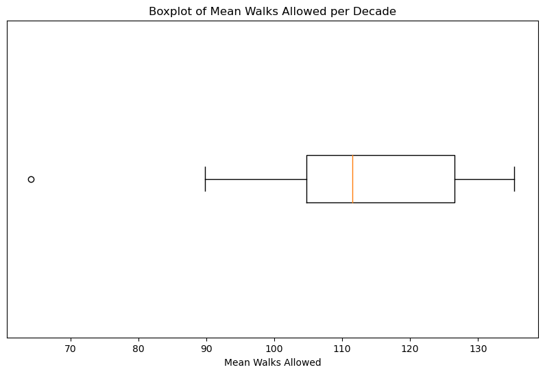

```python
import requests
from bs4 import BeautifulSoup
import pandas as pd
import re
import matplotlib.pyplot as plt

url = 'https://www.baseball-reference.com/leaders/BB_p_leagues.shtml'

# Set display option to show integers instead of decimals
pd.set_option('display.float_format', '{:.0f}'.format)

# Send an HTTP request to the URL
response = requests.get(url)

# Check if the request was successful (status code 200)
if response.status_code == 200:
    # Parse the HTML content of the page
    soup = BeautifulSoup(response.text, 'html.parser')

    # Find all tables on the page
    tables = soup.find_all('table')

    # Look for the table that likely contains American League data
    for table in tables:
        # Check if the table has at least 3 columns (assuming it's the right table)
        if len(table.find_all('th')) >= 7:
            # Extract data from the table and create a list of dictionaries
            data = []
            for row in table.find_all('tr')[1:]:  # Skip the header row
                columns = row.find_all(['th', 'td'])
                team = columns[0].text.strip()
                player_name = columns[1].text.strip()
                walks_allowed = int(columns[2].text.strip()) if columns[2].text.strip().isdigit() else None

                # Extract the year using regular expression
                year_match = re.search(r'\b\d{4}\b', team)
                year = int(year_match.group()) if year_match else None

                data.append({'Year': year, 'Player/ Team': player_name, 'Most Walks Allowed': walks_allowed})

            # Create a DataFrame from the list of dictionaries
            df = pd.DataFrame(data)

            # Filter out rows for non-American League teams and create a copy
            df_al = df[df['Year'] >= 1901].copy()

            # Sort the copied DataFrame based on the 'Year' column in ascending order
            df_al.sort_values(by='Year', inplace=True)

            # Reset the index to start from 0
            df_al.reset_index(drop=True, inplace=True)

            # Create 10-year intervals
            df_al['Decade'] = (df_al['Year'] // 10) * 10

            # Group by decade and calculate the mean walks allowed
            df_decade_mean = df_al.groupby('Decade')['Most Walks Allowed'].mean().reset_index()

            # Create a boxplot
            plt.figure(figsize=(10, 6))
            plt.boxplot(df_decade_mean['Most Walks Allowed'], vert=False)
            plt.title('Boxplot of Mean Walks Allowed per Decade')
            plt.xlabel('Mean Walks Allowed')
            plt.yticks([])
            plt.grid(axis='x', linestyle='', alpha=0.7)
            plt.show()

            # Exit the loop once the desired table is found
            break
    else:
        print('American League section not found or structure has changed.')

else:
    print(f'Error: {response.status_code}')
```

Analysis:

Walks/Walks Allowed Visualizations Summary: As talked about previously in the walks section, there was a slight positive correlation between the year and walks, which means a slight positive correlation should be seen in walks allowed over time since the 2 are directly related. When looking at the walks allowed visuals, we saw that although there were some spikes in some years, the overall trend for walks allowed was negative. This negative correlation was seen mainly in the mean walks allowed per decade line graph where over time, the walks allowed slowly but surely kept decreasing although there were a few years with an increase. This finding from the line graph could have been inferred when looking at the mean walks allowed table since the values slowly declined over time, even reaching the double digits in recent decades. This sharp decline in the past 2 decades is mirrored in the walk visualizations as both had significant drop offs in the more recent decades, but the 2 vastly different in the early to mid 1900’s area of the graphs/plots.

Overall Summary for Year Intervals: Overall, when looking at the summary for National League leaders in various stats based on decade/year intervals, it was interesting to see the findings. One would hypothesize that such closely related stats(Hits and hits allowed) would show some comparison to each other over time, but as seen in both hits and walks, that was not the case. Looking at these stats on yearly intervals was interesting because it included values such as outliers, but since all 4 graphs started and ended in the same year, we cannot say that was the case for the stats not being related to each other. We can say that for the most part, there was a general comparison to be made since neither of the stats had a vastly significant difference from its statistical counterpart. In the walks and walks allowed, we saw that the 2 compared towards the more recent decades where both had significant drop offs in each of their respective stats, which shows that the 2 compare to each other to an extent although that was not the conclusion made. In the end, when comparing 2 hitting and pitching stats that on paper are directly correlated with each other, it is interesting to see how that inference can only be made to a certain extent as there were no significant conflicts, but there were also no set conclusions/comparisons to be made.

MERGED DATA

Intro:

In this section, we will merge the data sets of Losses and HR allowed, two pitching statistics that we plan to investigate and see if they are related. As allowing a home run in baseball is a negative thing and the worst possible type of hit to allow, it would make sense to us that allowing the most home runs could be correlated with having the most losses on record. After merging these data sets, we will look for trends and correlations by visualizing the data using graphs.

Code For Merging Most Losses and HR Allowed:

```python
import requests
from bs4 import BeautifulSoup
import pandas as pd
import re

# Function to extract data from the specified URL and create a dataframe
def extract_data(url, column_names):
    response = requests.get(url)

    if response.status_code == 200:
        soup = BeautifulSoup(response.text, 'html.parser')
        tables = soup.find_all('table')

        for table in tables:
            if len(table.find_all('th')) >= len(column_names):
                data = []
                for row in table.find_all('tr')[1:]:
                    columns = row.find_all(['th', 'td'])
                    team = columns[0].text.strip()
                    player_name = columns[1].text.strip()
                    value = columns[2].text.strip()

                    year_match = re.search(r'\b\d{4}\b', team)
                    year = int(year_match.group()) if year_match else None

                    data.append({'Year': year, 'Player/ Team': player_name, column_names[2]: value})

                df = pd.DataFrame(data)
                df_filtered = df[df['Year'] >= 1901].copy()
                df_filtered.sort_values(by='Year', inplace=True)
                df_filtered.reset_index(drop=True, inplace=True)

                return df_filtered

        print('American League section not found or structure has changed.')
    else:
        print(f'Error: {response.status_code}')
        return None

# URLs and column names
url_losses = 'https://www.baseball-reference.com/leaders/L_leagues.shtml'
url_home_runs_allowed = 'https://www.baseball-reference.com/leaders/HR_p_leagues.shtml'
column_names_losses = ['Year', 'Player/ Team', 'Most Losses']
column_names_home_runs_allowed = ['Year', 'Player/ Team', 'Most HR Allowed']

# Extract data and create dataframes
df_losses = extract_data(url_losses, column_names_losses)
df_home_runs_allowed = extract_data(url_home_runs_allowed, column_names_home_runs_allowed)

# Merge dataframes
merged_df = pd.merge(df_losses, df_home_runs_allowed, on=['Year', 'Player/ Team'], how='outer')

# Remove rows with NaN entries
merged_df.dropna(inplace=True)

# Print the cleaned and merged dataframe
print(merged_df)
```

```
     Year           Player/ Team Most Losses Most HR Allowed
2    1903  Togie Pittinger (BSN)          22              12
41   1942        Jim Tobin (BSN)          21              20
51   1952    Murry Dickson (PIT)          21              26
56   1957   Robin Roberts+ (PHI)          22              40
78   1979     Phil Niekro+ (ATL)          20              41
79   1980     Phil Niekro+ (ATL)          18              30
109  2010   Rodrigo LÃ³pez (ARI)          16              37
```

Analysis:

Our merged dataframe only produces seven such seasons in which the league leader in losses was also the league leader in home runs allowed. While allowing a lot of home runs in a season does not spell victory, the fact that there were only seven such instances speaks to the belief that there is much more to losing games than merely allowing home runs. Of note, however, are the leaders here with high home runs allowed. Robin Roberts, Phil Niekro, and Rodrigo Lopez all have fairly high HR allowed totals, especially when you consider that the typical starting pitcher starts give-or take 30 games or less in a season. Each of these pitchers gave up more home runs than he had games played/started, definitely a recipe for disaster, and as a result, loss.

Code For Line Graph of Losses and HR Allowed:

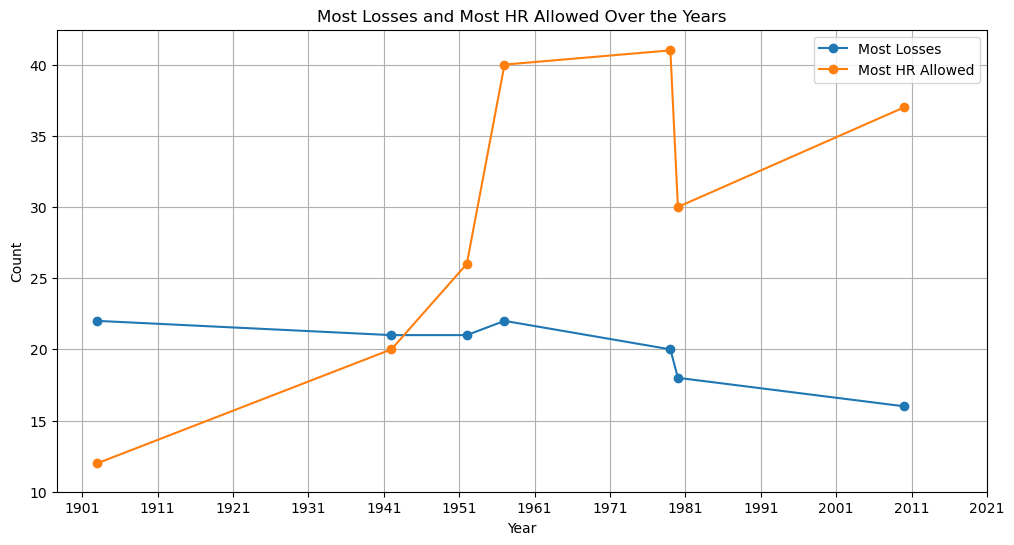

```python
import requests
from bs4 import BeautifulSoup
import pandas as pd
import re
import matplotlib.pyplot as plt

# Function to extract data from the specified URL and create a dataframe
def extract_data(url, column_names):
    response = requests.get(url)

    if response.status_code == 200:
        soup = BeautifulSoup(response.text, 'html.parser')
        tables = soup.find_all('table')

        for table in tables:
            if len(table.find_all('th')) >= len(column_names):
                data = []
                for row in table.find_all('tr')[1:]:
                    columns = row.find_all(['th', 'td'])
                    team = columns[0].text.strip()
                    player_name = columns[1].text.strip()
                    value = int(columns[2].text.strip()) if columns[2].text.strip().isdigit() else None

                    year_match = re.search(r'\b\d{4}\b', team)
                    year = int(year_match.group()) if year_match else None

                    data.append({'Year': year, 'Player/ Team': player_name, column_names[2]: value})

                df = pd.DataFrame(data)
                df_filtered = df[df['Year'] >= 1901].copy()
                df_filtered.sort_values(by='Year', inplace=True)
                df_filtered.reset_index(drop=True, inplace=True)

                return df_filtered

        print('American League section not found or structure has changed.')
    else:
        print(f'Error: {response.status_code}')
        return None

# URLs and column names
url_losses = 'https://www.baseball-reference.com/leaders/L_leagues.shtml'
url_home_runs_allowed = 'https://www.baseball-reference.com/leaders/HR_p_leagues.shtml'
column_names_losses = ['Year', 'Player/ Team', 'Most Losses']
column_names_home_runs_allowed = ['Year', 'Player/ Team', 'Most HR Allowed']

# Extract data and create dataframes
df_losses = extract_data(url_losses, column_names_losses)
df_home_runs_allowed = extract_data(url_home_runs_allowed, column_names_home_runs_allowed)

# Merge dataframes
merged_df = pd.merge(df_losses, df_home_runs_allowed, on=['Year', 'Player/ Team'], how='outer')

# Remove rows with NaN entries
merged_df.dropna(inplace=True)

# Print the cleaned and merged dataframe

# Plotting line graph
plt.figure(figsize=(12, 6))
plt.plot(merged_df['Year'], merged_df['Most Losses'], label='Most Losses', marker='o')
plt.plot(merged_df['Year'], merged_df['Most HR Allowed'], label='Most HR Allowed', marker='o')

# Adding labels and title
plt.xlabel('Year')
plt.ylabel('Count')
plt.title('Most Losses and Most HR Allowed Over the Years')
plt.legend()

# Set x-axis ticks and tick labels for specific years at 10-year intervals
years_to_display = range(1901, 2024, 10)
plt.xticks(years_to_display)

# Set y-axis ticks and tick labels
plt.yticks(range(10, 45, 5))

# Show the plot
plt.grid(True)
plt.show()
```

Analysis:

There are a number of interesting trends to decipher from this line graph when it comes to the league leaders in losses and home runs allowed over the years. From 1901 to 1941, a 40-year span, we can see a very slight decline in the yearly leaders in losses, but a very noticeable rise in HR allowed during the same time frame. From around 1951 to the mid-1950s, we see a massive jump in the leader for HR allowed, and a small jump for the losses leader at the same time. From this mid-1950s time to the end of the 1970s, HR allowed rises steadily while losses steadily declines. Finally, we see the leaders in HR allowed and losses move in opposite directions for the time frame of 1980 to 2010, as HR allowed rises while losses falls at the same time. The main takeaway from these trends in this line graph is that the two are not necessarily correlated, because there are many other statistics pitching-wise in baseball that can affect pitcher wins and losses, even if allowing home runs is one of the more impactful statistics.

Code For Scatter Plot of Losses and HR Allowed:

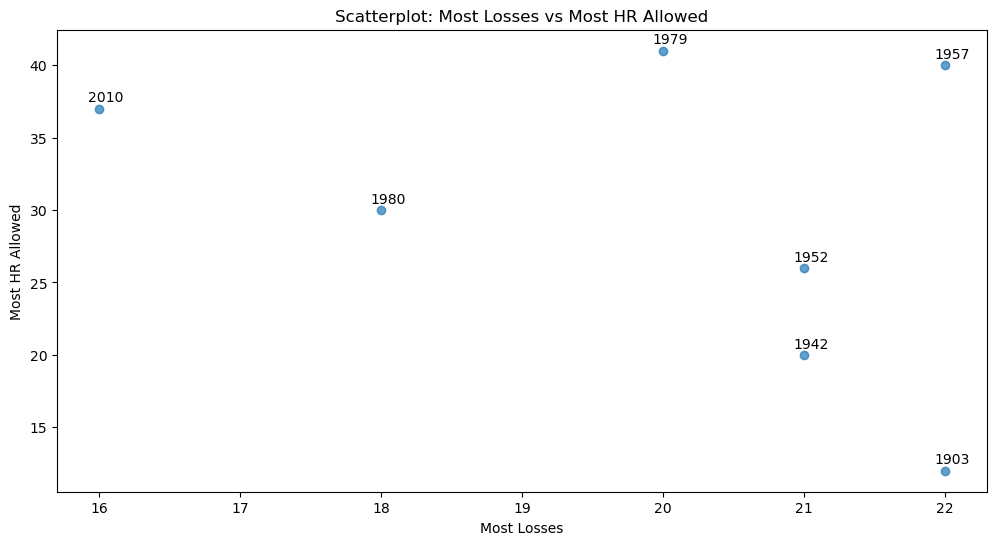

```python
import requests
from bs4 import BeautifulSoup
import pandas as pd
import re
import matplotlib.pyplot as plt

# Function to extract data from the specified URL and create a dataframe
def extract_data(url, column_names):
    response = requests.get(url)

    if response.status_code == 200:
        soup = BeautifulSoup(response.text, 'html.parser')
        tables = soup.find_all('table')

        for table in tables:
            if len(table.find_all('th')) >= len(column_names):
                data = []
                for row in table.find_all('tr')[1:]:
                    columns = row.find_all(['th', 'td'])
                    team = columns[0].text.strip()
                    player_name = columns[1].text.strip()
                    value = int(columns[2].text.strip()) if columns[2].text.strip().isdigit() else None

                    year_match = re.search(r'\b\d{4}\b', team)
                    year = int(year_match.group()) if year_match else None

                    data.append({'Year': year, 'Player/ Team': player_name, column_names[2]: value})

                df = pd.DataFrame(data)
                df_filtered = df[df['Year'] >= 1901].copy()
                df_filtered.sort_values(by='Year', inplace=True)
                df_filtered.reset_index(drop=True, inplace=True)

                return df_filtered

        print('American League section not found or structure has changed.')
    else:
        print(f'Error: {response.status_code}')
        return None

# URLs and column names
url_losses = 'https://www.baseball-reference.com/leaders/L_leagues.shtml'
url_home_runs_allowed = 'https://www.baseball-reference.com/leaders/HR_p_leagues.shtml'
column_names_losses = ['Year', 'Player/ Team', 'Most Losses']
column_names_home_runs_allowed = ['Year', 'Player/ Team', 'Most HR Allowed']

# Extract data and create dataframes
df_losses = extract_data(url_losses, column_names_losses)
df_home_runs_allowed = extract_data(url_home_runs_allowed, column_names_home_runs_allowed)

# Merge dataframes
merged_df = pd.merge(df_losses, df_home_runs_allowed, on=['Year', 'Player/ Team'], how='outer')

# Remove rows with NaN entries
merged_df.dropna(inplace=True)

# Plotting scatterplot with annotations for each point
plt.figure(figsize=(12, 6))
plt.scatter(merged_df['Most Losses'], merged_df['Most HR Allowed'], alpha=0.7)

# Adding labels and title
plt.xlabel('Most Losses')
plt.ylabel('Most HR Allowed')
plt.title('Scatterplot: Most Losses vs Most HR Allowed')

# Adding annotations for each point (year)
for i, row in merged_df.iterrows():
    plt.annotate(row['Year'], (row['Most Losses'], row['Most HR Allowed']), textcoords="offset points", xytext=(5,5), ha='center')

# Show the plot

plt.show()
```

Analysis:

From this scatterplot, we can see the seven instances in MLB history that the league leader in home runs allowed was also the league leader in losses. The scatterplot allows us to see what each year entailed in terms of how high the league lead was for those two statistics, with 1957 in particular standing out as a year that had a relatively high HR allowed and a high number of losses compared to the other six seasons. The 1957 season featured a pitcher that had 40 HR allowed and 22 losses. On the other hand, we see that 1903 had a pitcher with the lowest league lead in HR allowed, yet tied for the highest loss count out of the seven seasons. The inverse of this 1903 season is the 2010 season, in which it had the lowest league leader in losses out of the seven instances, but a high HR allowed total at about 37.

Code For Boxplot of Losses and HR Allowed:

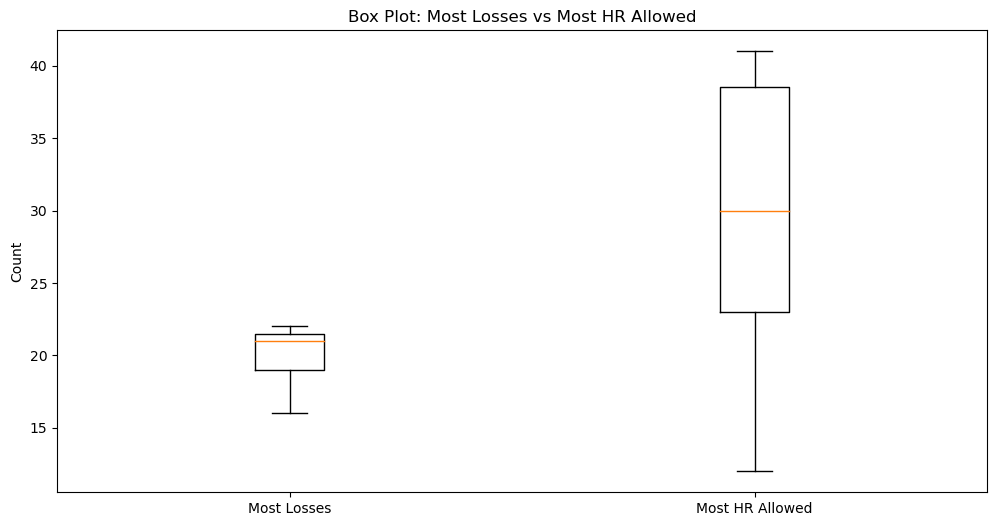

```python
import requests
from bs4 import BeautifulSoup
import pandas as pd
import re
import matplotlib.pyplot as plt

# Function to extract data from the specified URL and create a dataframe
def extract_data(url, column_names):
    response = requests.get(url)

    if response.status_code == 200:
        soup = BeautifulSoup(response.text, 'html.parser')
        tables = soup.find_all('table')

        for table in tables:
            if len(table.find_all('th')) >= len(column_names):
                data = []
                for row in table.find_all('tr')[1:]:
                    columns = row.find_all(['th', 'td'])
                    team = columns[0].text.strip()
                    player_name = columns[1].text.strip()
                    value = int(columns[2].text.strip()) if columns[2].text.strip().isdigit() else None

                    year_match = re.search(r'\b\d{4}\b', team)
                    year = int(year_match.group()) if year_match else None

                    data.append({'Year': year, 'Player/ Team': player_name, column_names[2]: value})

                df = pd.DataFrame(data)
                df_filtered = df[df['Year'] >= 1901].copy()
                df_filtered.sort_values(by='Year', inplace=True)
                df_filtered.reset_index(drop=True, inplace=True)

                return df_filtered

        print('American League section not found or structure has changed.')
    else:
        print(f'Error: {response.status_code}')
        return None

# URLs and column names
url_losses = 'https://www.baseball-reference.com/leaders/L_leagues.shtml'
url_home_runs_allowed = 'https://www.baseball-reference.com/leaders/HR_p_leagues.shtml'
column_names_losses = ['Year', 'Player/ Team', 'Most Losses']
column_names_home_runs_allowed = ['Year', 'Player/ Team', 'Most HR Allowed']

# Extract data and create dataframes
df_losses = extract_data(url_losses, column_names_losses)
df_home_runs_allowed = extract_data(url_home_runs_allowed, column_names_home_runs_allowed)

# Merge dataframes
merged_df = pd.merge(df_losses, df_home_runs_allowed, on=['Year', 'Player/ Team'], how='outer')

# Remove rows with NaN entries
merged_df.dropna(inplace=True)
# Plotting box plot for 'Most Losses' and 'Most HR Allowed'
plt.figure(figsize=(12, 6))
plt.boxplot([merged_df['Most Losses'], merged_df['Most HR Allowed']], labels=['Most Losses', 'Most HR Allowed'])

# Adding labels and title
plt.ylabel('Count')
plt.title('Box Plot: Most Losses vs Most HR Allowed')

# Show the plot

plt.show()
```

Analysis:

Code For Histogram of Losses and HR Allowed:

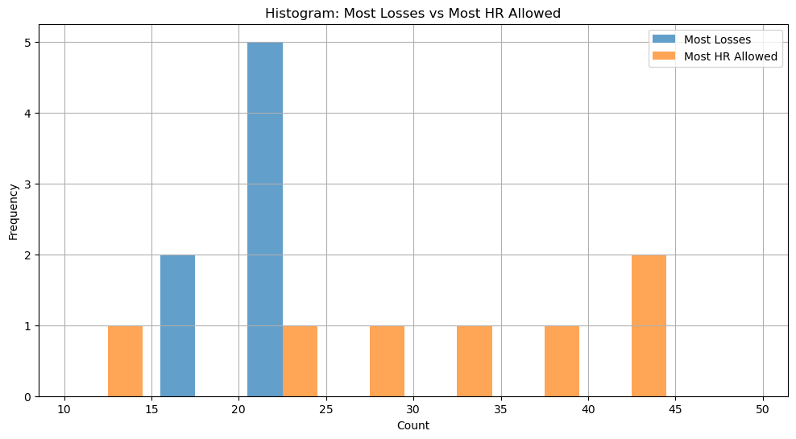

```python
import requests
from bs4 import BeautifulSoup
import pandas as pd
import re
import matplotlib.pyplot as plt

# Function to extract data from the specified URL and create a dataframe
def extract_data(url, column_names):
    response = requests.get(url)

    if response.status_code == 200:
        soup = BeautifulSoup(response.text, 'html.parser')
        tables = soup.find_all('table')

        for table in tables:
            if len(table.find_all('th')) >= len(column_names):
                data = []
                for row in table.find_all('tr')[1:]:
                    columns = row.find_all(['th', 'td'])
                    team = columns[0].text.strip()
                    player_name = columns[1].text.strip()
                    value = int(columns[2].text.strip()) if columns[2].text.strip().isdigit() else None

                    year_match = re.search(r'\b\d{4}\b', team)
                    year = int(year_match.group()) if year_match else None

                    data.append({'Year': year, 'Player/ Team': player_name, column_names[2]: value})

                df = pd.DataFrame(data)
                df_filtered = df[df['Year'] >= 1901].copy()
                df_filtered.sort_values(by='Year', inplace=True)
                df_filtered.reset_index(drop=True, inplace=True)

                return df_filtered

        print('American League section not found or structure has changed.')
    else:
        print(f'Error: {response.status_code}')
        return None

# URLs and column names
url_losses = 'https://www.baseball-reference.com/leaders/L_leagues.shtml'
url_home_runs_allowed = 'https://www.baseball-reference.com/leaders/HR_p_leagues.shtml'
column_names_losses = ['Year', 'Player/ Team', 'Most Losses']
column_names_home_runs_allowed = ['Year', 'Player/ Team', 'Most HR Allowed']

# Extract data and create dataframes
df_losses = extract_data(url_losses, column_names_losses)
df_home_runs_allowed = extract_data(url_home_runs_allowed, column_names_home_runs_allowed)

# Merge dataframes
merged_df = pd.merge(df_losses, df_home_runs_allowed, on=['Year', 'Player/ Team'], how='outer')

# Remove rows with NaN entries
merged_df.dropna(inplace=True)
# Convert 'Most HR Allowed' column to integers
merged_df['Most HR Allowed'] = merged_df['Most HR Allowed'].astype(int)

# Define custom bin intervals
bin_intervals = [i for i in range(10, max(merged_df['Most HR Allowed']) + 10, 5)]

# Plotting histogram for 'Most Losses' and 'Most HR Allowed'
plt.figure(figsize=(12, 6))
plt.hist([merged_df['Most Losses'], merged_df['Most HR Allowed']], bins=bin_intervals, alpha=0.7, label=['Most Losses', 'Most HR Allowed'])

# Adding labels and title
plt.xlabel('Count')
plt.ylabel('Frequency')
plt.title('Histogram: Most Losses vs Most HR Allowed')
plt.legend()

# Show the plot
plt.grid(True)
plt.show()
```

Analysis:

This histogram depicts the seven instances that the league leader in losses was also the league leader in home runs allowed over the years in MLB. We observe that there was a high of five such seasons with a loss leader between 20 and 23, with the other two seasons having a loss total between 15 and 18.

Intro:

This section of our report merges the data sets of the league leaders of extra-base hits (XBH) and doubles, as we wish to see how related the two are over the years by seeing which seasons the league leader in XBH was also the league leader in doubles. It is important to note that doubles is a component of XBH, as XBH is computed as doubles plus triples plus home runs.

Code For Merging XBH and Doubles:

```python
# Import libraries
import requests
from bs4 import BeautifulSoup
import pandas as pd

# Function to scrape and process data from the given URL
def scrape_and_process_data(url, xbh_or_doubles):
    headers = {
        'User-Agent': 'Mozilla/5.0 (Windows NT 10.0; Win64; x64) AppleWebKit/537.36 (KHTML, like Gecko) Chrome/58.0.3029.110 Safari/537.3'}
    response = requests.get(url, headers=headers)

    if response.status_code == 200:
        soup = BeautifulSoup(response.content, 'html.parser')
        table = soup.find('table')
        table_data = []
        year = None  # Initialize year variable outside of the loop

        for row in table.find_all('tr'):
            columns = row.find_all(['th', 'td'])

            if columns and columns[0].text.strip().isnumeric():
                year = columns[0].text.strip()
                if 1876 <= int(year) <= 1900:
                    continue

            if len(columns) < 5:
                continue

            player = columns[5].text.strip()

            # Check if the 'Team' column is present before accessing it
            team = columns[7].text.strip() if len(columns) > 7 else None

            if xbh_or_doubles == 'XBH':
                value = columns[6].text.strip()
            elif xbh_or_doubles == 'Doubles':
                value = columns[6].text.strip()

            table_data.append([year, player, team, value])

        df = pd.DataFrame(table_data, columns=['Year', 'Player', 'Team', xbh_or_doubles])
        df = df.drop([0, 124]).reset_index(drop=True)
        return df
    else:
        print(f"Failed to retrieve the webpage. Status code: {response.status_code}")
        return None

# URLs
url_xbh = "https://www.baseball-almanac.com/hitting/hiebh4.shtml"
url_doubles = "https://www.baseball-almanac.com/hitting/hi2b3.shtml"

# Scrape and process data for XBH and Doubles separately
df_xbh = scrape_and_process_data(url_xbh, 'XBH')
df_doubles = scrape_and_process_data(url_doubles, 'Doubles')

# Merge dataframes on 'Year' and 'Player', and remove the 'Team' columns if present
if 'Team' in df_xbh.columns and 'Team' in df_doubles.columns:
    merged_df = pd.merge(df_xbh.drop('Team', axis=1), df_doubles.drop('Team', axis=1), on=['Year', 'Player'])
else:
    merged_df = pd.merge(df_xbh, df_doubles, on=['Year', 'Player'])


# Remove rows with NaN entries
merged_df.dropna(inplace=True)

# Print the merged dataframe
print(merged_df)
```

```
    Year            Player              XBH  Doubles
0   1902      Honus Wagner               49       30
1   1904      Honus Wagner               62       44
2   1905        Cy Seymour               69       40
3   1907      Honus Wagner               58       38
4   1908      Honus Wagner               68       39
5   1909      Honus Wagner               54       39
6   1912  Heinie Zimmerman               69       41
7   1914      Sherry Magee               65       39
8   1920    Rogers Hornsby               73       44
9   1921    Rogers Hornsby               83       44
10  1922    Rogers Hornsby              102       46
11  1924    Rogers Hornsby               82       43
12  1926     Jim Bottomley               73       40
13  1930       Chuck Klein              107       59
```

[output cut: 24 more lines]

Analysis:

Code For Line Graph of XBH and Doubles:

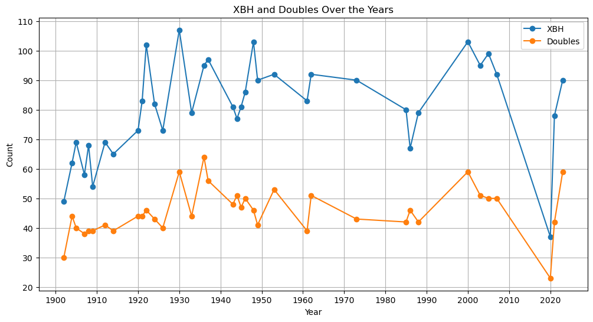

```python
# Import libraries
import requests
from bs4 import BeautifulSoup
import pandas as pd
import matplotlib.pyplot as plt

# Function to scrape and process data from the given URL
def scrape_and_process_data(url, xbh_or_doubles):
    headers = {
        'User-Agent': 'Mozilla/5.0 (Windows NT 10.0; Win64; x64) AppleWebKit/537.36 (KHTML, like Gecko) Chrome/58.0.3029.110 Safari/537.3'}
    response = requests.get(url, headers=headers)

    if response.status_code == 200:
        soup = BeautifulSoup(response.content, 'html.parser')
        table = soup.find('table')
        table_data = []
        year = None  # Initialize year variable outside of the loop

        for row in table.find_all('tr'):
            columns = row.find_all(['th', 'td'])

            if columns and columns[0].text.strip().isnumeric():
                year = int(columns[0].text.strip()) if columns[0].text.strip().isdigit() else None
                if 1876 <= int(year) <= 1900:
                    continue

            if len(columns) < 5:
                continue

            player = columns[5].text.strip()

            # Check if the 'Team' column is present before accessing it
            team = columns[7].text.strip() if len(columns) > 7 else None

            if xbh_or_doubles == 'XBH':
                value = int(columns[6].text.strip()) if columns[6].text.strip().isdigit() else None
            elif xbh_or_doubles == 'Doubles':
                value = int(columns[6].text.strip()) if columns[6].text.strip().isdigit() else None

            table_data.append([year, player, team, value])

        df = pd.DataFrame(table_data, columns=['Year', 'Player', 'Team', xbh_or_doubles])
        df = df.drop([0, 124]).reset_index(drop=True)
        return df
    else:
        print(f"Failed to retrieve the webpage. Status code: {response.status_code}")
        return None

# URLs
url_xbh = "https://www.baseball-almanac.com/hitting/hiebh4.shtml"
url_doubles = "https://www.baseball-almanac.com/hitting/hi2b3.shtml"

# Scrape and process data for XBH and Doubles separately
df_xbh = scrape_and_process_data(url_xbh, 'XBH')
df_doubles = scrape_and_process_data(url_doubles, 'Doubles')

# Merge dataframes on 'Year' and 'Player', and remove the 'Team' columns if present
if 'Team' in df_xbh.columns and 'Team' in df_doubles.columns:
    merged_df = pd.merge(df_xbh.drop('Team', axis=1), df_doubles.drop('Team', axis=1), on=['Year', 'Player'])
else:
    merged_df = pd.merge(df_xbh, df_doubles, on=['Year', 'Player'])

# Remove rows with NaN entries
merged_df.dropna(inplace=True)

# Plotting line graph
plt.figure(figsize=(12, 6))
plt.plot(merged_df['Year'], merged_df['XBH'], label='XBH', marker='o')
plt.plot(merged_df['Year'], merged_df['Doubles'], label='Doubles', marker='o')

# Adding labels and title
plt.xlabel('Year')
plt.ylabel('Count')
plt.title('XBH and Doubles Over the Years')
plt.legend()

# Set x-axis ticks and tick labels for specific years at 20-year intervals
plt.xticks(range(1900, 2025, 10))


# Set y-axis ticks and tick labels in intervals of 10, starting from 20 up to 110
plt.yticks(range(20, 111, 10))

# Show the plot
plt.grid(True)
plt.show()
```

Analysis:

This line graph depicts every year's league leaders in XBH and doubles. There isn't much of a general trend to track over the seasons for either statistic, but we can see obvious dips in certain years that cannot really be explained other than the general nature and variance of baseball. We can explain the massive dip in 2020 with the COVID-19 shortened year, and we see a sharp spike in the years following 2020 to more normal levels.

Code For Scatterplot of XBH and Doubles:

```
Merged DataFrame shape: (37, 4)
   Year        Player  XBH  Doubles
0  1902  Honus Wagner   49       30
1  1904  Honus Wagner   62       44
2  1905    Cy Seymour   69       40
3  1907  Honus Wagner   58       38
4  1908  Honus Wagner   68       39
```

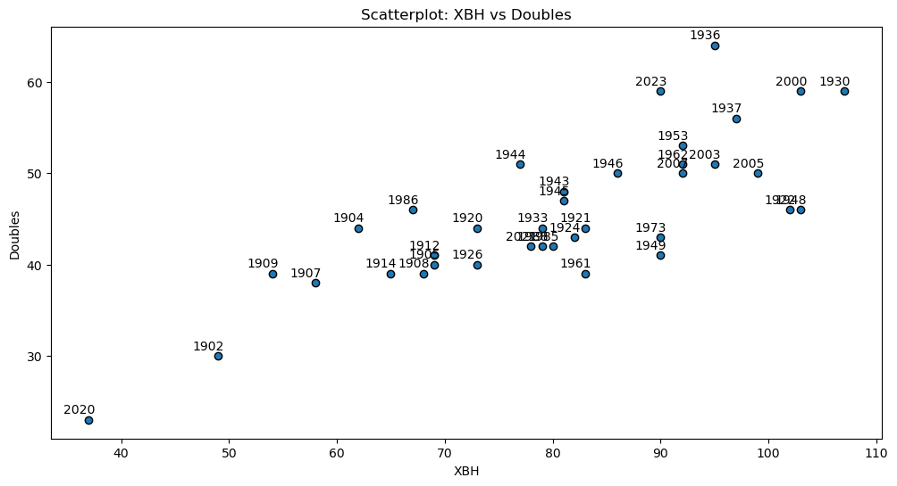

```python
import requests
from bs4 import BeautifulSoup
import pandas as pd
import matplotlib.pyplot as plt

# Function to scrape and process data from the given URL
def scrape_and_process_data(url, xbh_or_doubles):
    headers = {
        'User-Agent': 'Mozilla/5.0 (Windows NT 10.0; Win64; x64) AppleWebKit/537.36 (KHTML, like Gecko) Chrome/58.0.3029.110 Safari/537.3'}
    response = requests.get(url, headers=headers)

    if response.status_code == 200:
        soup = BeautifulSoup(response.content, 'html.parser')
        table = soup.find('table')
        table_data = []
        year = None  # Initialize year variable outside of the loop

        for row in table.find_all('tr'):
            columns = row.find_all(['th', 'td'])

            if columns and columns[0].text.strip().isnumeric():
                year = columns[0].text.strip()
                if 1876 <= int(year) <= 1900:
                    continue

            if len(columns) < 5:
                continue

            player = columns[5].text.strip()

            # Check if the 'Team' column is present before accessing it
            team = columns[7].text.strip() if len(columns) > 7 else None

            if xbh_or_doubles == 'XBH':
                value = columns[6].text.strip()
            elif xbh_or_doubles == 'Doubles':
                value = columns[6].text.strip()

            table_data.append([year, player, team, value])

        df = pd.DataFrame(table_data, columns=['Year', 'Player', 'Team', xbh_or_doubles])

        # Filter out rows where the value is not numeric
        df = df[df[xbh_or_doubles].str.isnumeric()]

        # Drop the first and last rows if they exist
        if not df.empty:
            if df.shape[0] > 0:
                df = df.drop(index=0, errors='ignore')  # Drop the first row if it exists
            if df.shape[0] > 123:
                df = df.drop(index=124, errors='ignore')  # Drop the last row if it exists
        df = df.reset_index(drop=True)
        return df
    else:
        print(f"Failed to retrieve the webpage. Status code: {response.status_code}")
        return None

# URLs
url_xbh = "https://www.baseball-almanac.com/hitting/hiebh4.shtml"
url_doubles = "https://www.baseball-almanac.com/hitting/hi2b3.shtml"

# Scrape and process data for XBH and Doubles separately
df_xbh = scrape_and_process_data(url_xbh, 'XBH')
df_doubles = scrape_and_process_data(url_doubles, 'Doubles')

# Merge dataframes on 'Year' and 'Player', and remove the 'Team' columns if present
if df_xbh is not None and df_doubles is not None:
    if 'Team' in df_xbh.columns and 'Team' in df_doubles.columns:
        merged_df = pd.merge(df_xbh.drop('Team', axis=1), df_doubles.drop('Team', axis=1), on=['Year', 'Player'])
    else:
        merged_df = pd.merge(df_xbh, df_doubles, on=['Year', 'Player'])

    # Remove rows with NaN entries
    merged_df.dropna(inplace=True)

    # Convert 'XBH' and 'Doubles' columns to numeric
    merged_df['XBH'] = pd.to_numeric(merged_df['XBH'], errors='coerce')
    merged_df['Doubles'] = pd.to_numeric(merged_df['Doubles'], errors='coerce')

    # Print merged DataFrame info for debugging
    print(f"Merged DataFrame shape: {merged_df.shape}")
    print(merged_df.head())

    # Plotting scatterplot with year annotations
    plt.figure(figsize=(12, 6))
    plt.scatter(merged_df['XBH'], merged_df['Doubles'], marker='o', edgecolors='black')

    # Adding labels and title
    plt.xlabel('XBH')
    plt.ylabel('Doubles')
    plt.title('Scatterplot: XBH vs Doubles')

    # Annotate each point with the corresponding year
    for i, txt in enumerate(merged_df['Year']):
        plt.annotate(txt, (merged_df['XBH'][i], merged_df['Doubles'][i]), textcoords="offset points", xytext=(5,5), ha='right')

    # Show the plot
    plt.show()
else:
    print("Error in data scraping.")
```

Analysis:

This scatterplot depicts how high or low each year's league leader in XBH and doubles was, with 2020 sticking out as a year that had a low leader in both due to the shortened season. 1936 sticks out as a year that had a high leader in both categories, with a doubles total over 60 and XBH over 90. 1902 also is notable for having a low count of both statistics.

Code For Boxplot of XBH and Doubles:

```
Merged DataFrame shape: (38, 4)
   Year        Player  XBH  Doubles
0  1902  Honus Wagner   49       30
1  1904  Honus Wagner   62       44
2  1905    Cy Seymour   69       40
3  1907  Honus Wagner   58       38
4  1908  Honus Wagner   68       39
```

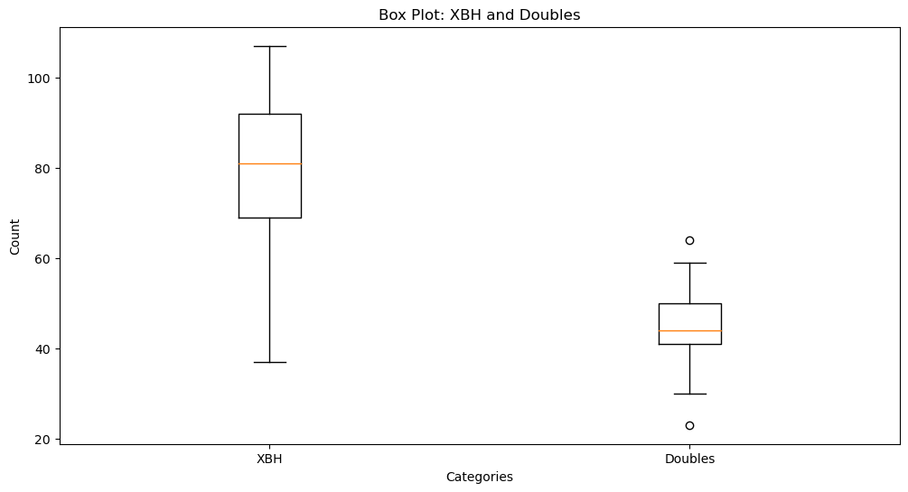

```python
import requests
from bs4 import BeautifulSoup
import pandas as pd
import matplotlib.pyplot as plt

# Function to scrape and process data from the given URL
def scrape_and_process_data(url, xbh_or_doubles):
    headers = {
        'User-Agent': 'Mozilla/5.0 (Windows NT 10.0; Win64; x64) AppleWebKit/537.36 (KHTML, like Gecko) Chrome/58.0.3029.110 Safari/537.3'}
    response = requests.get(url, headers=headers)

    if response.status_code == 200:
        soup = BeautifulSoup(response.content, 'html.parser')
        table = soup.find('table')
        table_data = []
        year = None  # Initialize year variable outside of the loop

        for row in table.find_all('tr'):
            columns = row.find_all(['th', 'td'])

            if columns and columns[0].text.strip().isnumeric():
                year = columns[0].text.strip()
                if 1876 <= int(year) <= 1900:
                    continue

            if len(columns) < 5:
                continue

            player = columns[5].text.strip()

            # Check if the 'Team' column is present before accessing it
            team = columns[7].text.strip() if len(columns) > 7 else None

            if xbh_or_doubles == 'XBH':
                value = columns[6].text.strip()
            elif xbh_or_doubles == 'Doubles':
                value = columns[6].text.strip()

            table_data.append([year, player, team, value])

        df = pd.DataFrame(table_data, columns=['Year', 'Player', 'Team', xbh_or_doubles])
        df = df.drop([0, 124], errors='ignore').reset_index(drop=True)
        return df
    else:
        print(f"Failed to retrieve the webpage. Status code: {response.status_code}")
        return None

# URLs
url_xbh = "https://www.baseball-almanac.com/hitting/hiebh4.shtml"
url_doubles = "https://www.baseball-almanac.com/hitting/hi2b3.shtml"

# Scrape and process data for XBH and Doubles separately
df_xbh = scrape_and_process_data(url_xbh, 'XBH')
df_doubles = scrape_and_process_data(url_doubles, 'Doubles')

# Merge dataframes on 'Year' and 'Player', and remove the 'Team' columns if present
if df_xbh is not None and df_doubles is not None:
    if 'Team' in df_xbh.columns and 'Team' in df_doubles.columns:
        merged_df = pd.merge(df_xbh.drop('Team', axis=1), df_doubles.drop('Team', axis=1), on=['Year', 'Player'])
    else:
        merged_df = pd.merge(df_xbh, df_doubles, on=['Year', 'Player'])

    # Remove rows with NaN entries
    merged_df.dropna(inplace=True)

    # Convert 'XBH' and 'Doubles' columns to numeric
    merged_df['XBH'] = pd.to_numeric(merged_df['XBH'], errors='coerce')
    merged_df['Doubles'] = pd.to_numeric(merged_df['Doubles'], errors='coerce')

    # Print merged DataFrame info for debugging
    print(f"Merged DataFrame shape: {merged_df.shape}")
    print(merged_df.head())

    # Plotting box plot
    plt.figure(figsize=(12, 6))

    # Check if data is valid before plotting
    if not merged_df['XBH'].dropna().empty and not merged_df['Doubles'].dropna().empty:
        plt.boxplot([merged_df['XBH'].dropna(), merged_df['Doubles'].dropna()], labels=['XBH', 'Doubles'])
        plt.xlabel('Categories')
        plt.ylabel('Count')
        plt.title('Box Plot: XBH and Doubles')
    else:
        print("One of the columns is empty or contains only NaN values.")

    plt.show()
else:
    print("Error in data scraping.")
```

Analysis:

This boxplot for XBH and doubles shows the ranges and means of both distributions of the statistics. It is obvious that doubles would have lower mean and range, since XBH is a cumulative statistic that includes doubles count. XBH has a range of roughly 38 to over 100, and a mean of around 80. Doubles has a range between roughly 30 to roughly 58, with a mean of about 45. There are two outliers identified for doubles, with a year of a doubles total of about 65 and a year of a doubles total of about 25.

Code For Histogram of XBH and Doubles:

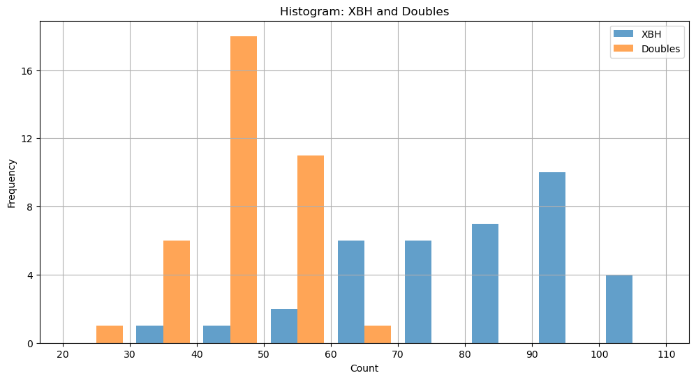

```python
import requests
from bs4 import BeautifulSoup
import pandas as pd
import matplotlib.pyplot as plt

# Function to scrape and process data from the given URL
def scrape_and_process_data(url, xbh_or_doubles):
    headers = {
        'User-Agent': 'Mozilla/5.0 (Windows NT 10.0; Win64; x64) AppleWebKit/537.36 (KHTML, like Gecko) Chrome/58.0.3029.110 Safari/537.3'}
    response = requests.get(url, headers=headers)

    if response.status_code == 200:
        soup = BeautifulSoup(response.content, 'html.parser')
        table = soup.find('table')
        table_data = []
        year = None  # Initialize year variable outside of the loop

        for row in table.find_all('tr'):
            columns = row.find_all(['th', 'td'])

            if columns and columns[0].text.strip().isnumeric():
                year = columns[0].text.strip()
                if 1876 <= int(year) <= 1900:
                    continue

            if len(columns) < 5:
                continue

            player = columns[5].text.strip()

            # Check if the 'Team' column is present before accessing it
            team = columns[7].text.strip() if len(columns) > 7 else None

            if xbh_or_doubles == 'XBH':
                value = columns[6].text.strip()
            elif xbh_or_doubles == 'Doubles':
                value = columns[6].text.strip()

            table_data.append([year, player, team, value])

        df = pd.DataFrame(table_data, columns=['Year', 'Player', 'Team', xbh_or_doubles])
        df = df.drop([0, 124]).reset_index(drop=True)
        return df
    else:
        print(f"Failed to retrieve the webpage. Status code: {response.status_code}")
        return None

# URLs
url_xbh = "https://www.baseball-almanac.com/hitting/hiebh4.shtml"
url_doubles = "https://www.baseball-almanac.com/hitting/hi2b3.shtml"

# Scrape and process data for XBH and Doubles separately
df_xbh = scrape_and_process_data(url_xbh, 'XBH')
df_doubles = scrape_and_process_data(url_doubles, 'Doubles')

# Merge dataframes on 'Year' and 'Player', and remove the 'Team' columns if present
if 'Team' in df_xbh.columns and 'Team' in df_doubles.columns:
    merged_df = pd.merge(df_xbh.drop('Team', axis=1), df_doubles.drop('Team', axis=1), on=['Year', 'Player'])
else:
    merged_df = pd.merge(df_xbh, df_doubles, on=['Year', 'Player'])

# Remove rows with NaN entries
merged_df.dropna(inplace=True)

# Convert 'XBH' and 'Doubles' columns to numeric
merged_df['XBH'] = pd.to_numeric(merged_df['XBH'], errors='coerce')
merged_df['Doubles'] = pd.to_numeric(merged_df['Doubles'], errors='coerce')

# Plotting histogram with labeled x-axis
plt.figure(figsize=(12, 6))
plt.hist([merged_df['XBH'], merged_df['Doubles']], bins=range(20, 111, 10), alpha=0.7, label=['XBH', 'Doubles'])

# Adding labels and title
plt.xlabel('Count')
plt.ylabel('Frequency')
plt.title('Histogram: XBH and Doubles')

# Set x-axis ticks and tick labels
plt.xticks(range(20, 111, 10))
plt.yticks(range(0, 20, 4))

# Show the plot
plt.legend()
plt.grid(True)
plt.show()
```

Analysis:

Conclusion for XBH and Doubles: In this portion of the experiment, we further compared and looked at the relationship of players who led in both XBH(Extra Base Hits) and Doubles on any given year. Since Doubles are a component in calculating XBH, it only seems logical to think that the two stats would be related. This assumption would prove to be true for the most part as seen through the different graphs. When looking at the line graph, for the most part, the 2 stats did seem closely related to each other with both spikes and dips on the same years. This relationship was further seen in the scatterplot when comparing the 2 as an obvious correlation was seen which meant if a player has a high amount of doubles, then they would have a high amount of XBH and vice versa. Although the boxplot and histogram did not further prove the assumption that the two are related, they did not contradict our previous findings. Overall, through looking at the plots and graphs comparing these 2 hitting metrics, we saw that there was a general relationship between the players who led in both categories the same year. The relationship that was identified was one that could have been assumed, which was that if a player has a high amount of XBH, then they would have a high amount of doubles. This relationship that was concluded was most evident in the line graph and scatter plot as their dips and spikes almost mirrored each other for the given years.

Intro:

This section aims to investigate the merged data sets of the league leaders in WHIP (walks and hits per innings pitched) and ERA (earned run average), and see by visualizing this merged data set if the two statistics are related and how they may affect each other. It is important to note that for the statistics WHIP and ERA, the lower (or closer to 0) the statistic is, the better, so the league leaders would have the lowest in the league. Explanations for these statistics can be found in section II of the report.

Code For Merging WHIP and ERA:

```python
import requests
from bs4 import BeautifulSoup
import pandas as pd
import re

# Function to extract data from the table and create a DataFrame
def extract_data(url, column_name):
    response = requests.get(url)

    if response.status_code == 200:
        soup = BeautifulSoup(response.text, 'html.parser')
        tables = soup.find_all('table')

        for table in tables:
            if len(table.find_all('th')) >= 7:
                data = []
                for row in table.find_all('tr')[1:]:
                    columns = row.find_all(['th', 'td'])
                    team = columns[0].text.strip()
                    player_name = columns[1].text.strip()
                    value = columns[2].text.strip()

                    year_match = re.search(r'\b\d{4}\b', team)
                    year = int(year_match.group()) if year_match else None

                    data.append({'Year': year, 'Player/ Team': player_name, column_name: value})

                df = pd.DataFrame(data)
                df_filtered = df[df['Year'] >= 1901].copy()
                df_filtered.sort_values(by='Year', inplace=True)
                df_filtered.reset_index(drop=True, inplace=True)

                return df_filtered

        print(f'{column_name} section not found or structure has changed.')
        return None

    else:
        print(f'Error: {response.status_code}')
        return None

# URLs for the three tables
url_whip = 'https://www.baseball-reference.com/leaders/whip_leagues.shtml'
url_era = 'https://www.baseball-reference.com/leaders/earned_run_avg_leagues.shtml'

# Extract data for WHIP and ERA
df_whip = extract_data(url_whip, 'WHIP')
df_era = extract_data(url_era, 'ERA')

# Merge DataFrames on 'Year' and 'Player/ Team'
merged_df = pd.merge(df_whip, df_era, on=['Year', 'Player/ Team'], how='outer')

# Remove rows with NaN values
merged_df_cleaned = merged_df.dropna()

# Display the resulting DataFrame without NaN values
print(merged_df_cleaned)
```

```
     Year              Player/ Team   WHIP   ERA
1    1902         Jack Taylor (CHC)  0.953  1.29
3    1904      Joe McGinnity+ (NYG)  0.963  1.61
4    1905  Christy Mathewson+ (NYG)  0.933  1.28
5    1906     Mordecai Brown+ (CHC)  0.934  1.04
7    1908  Christy Mathewson+ (NYG)  0.827  1.43
8    1909  Christy Mathewson+ (NYG)  0.828  1.14
12   1913  Christy Mathewson+ (NYG)  1.020  2.06
14   1915   Grover Alexander+ (PHI)  0.842  1.22
15   1916   Grover Alexander+ (PHI)  0.959  1.55
16   1917       Fred Anderson (NYG)  0.963  1.44
17   1918       Hippo Vaughn* (CHC)  1.006  1.74
21   1922        Phil Douglas (NYG)  1.199  2.63
23   1924        Dazzy Vance+ (BRO)  1.022  2.16
24   1925          Dolf Luque (CIN)  1.172  2.63
```

[output cut: 46 more lines]

Analysis:

Code For Line Graph of WHIP and ERA:

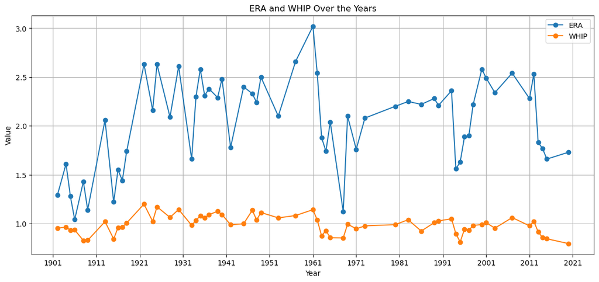

```python
import requests
from bs4 import BeautifulSoup
import pandas as pd
import re
import matplotlib.pyplot as plt

# Function to extract data from the specified URL and create a dataframe
def extract_data(url, column_names):
    response = requests.get(url)

    if response.status_code == 200:
        soup = BeautifulSoup(response.text, 'html.parser')
        tables = soup.find_all('table')

        for table in tables:
            if len(table.find_all('th')) >= len(column_names):
                data = []
                for row in table.find_all('tr')[1:]:
                    columns = row.find_all(['th', 'td'])
                    team = columns[0].text.strip()
                    player_name = columns[1].text.strip()
                    value = float(columns[2].text.strip()) if columns[2].text.strip().replace('.', '').isdigit() else None

                    year_match = re.search(r'\b\d{4}\b', team)
                    year = int(year_match.group()) if year_match else None

                    data.append({'Year': year, 'Player/ Team': player_name, column_names[2]: value})

                df = pd.DataFrame(data)
                df_filtered = df[df['Year'] >= 1901].copy()
                df_filtered.sort_values(by='Year', inplace=True)
                df_filtered.reset_index(drop=True, inplace=True)

                return df_filtered

        print('American League section not found or structure has changed.')
    else:
        print(f'Error: {response.status_code}')
        return None

# URLs and column names for ERA and WHIP
url_era = 'https://www.baseball-reference.com/leaders/earned_run_avg_leagues.shtml'
url_whip = 'https://www.baseball-reference.com/leaders/whip_leagues.shtml'
column_names_era = ['Year', 'Player/ Team', 'ERA']
column_names_whip = ['Year', 'Player/ Team', 'WHIP']

# Extract data and create dataframes
df_era = extract_data(url_era, column_names_era)
df_whip = extract_data(url_whip, column_names_whip)

# Merge dataframes
merged_df = pd.merge(df_era, df_whip, on=['Year', 'Player/ Team'], how='outer')

# Remove rows with NaN entries
merged_df.dropna(inplace=True)

# Print the cleaned and merged dataframe

# Plotting line graph
plt.figure(figsize=(14, 6))
plt.plot(merged_df['Year'], merged_df['ERA'], label='ERA', marker='o')
plt.plot(merged_df['Year'], merged_df['WHIP'], label='WHIP', marker='o')

# Adding labels and title
plt.xlabel('Year')
plt.ylabel('Value')
plt.title('ERA and WHIP Over the Years')
plt.legend()

# Set x-axis ticks and tick labels for specific years at 10-year intervals
years_to_display = range(1901, 2024, 10)
plt.xticks(years_to_display)

# Show the plot
plt.grid(True)
plt.show()
```

Analysis:

There is not much in the way of a general trend for either line, but we can somewhat see that WHIP slightly imitates the line of ERA, but as a smaller version. This notion would make sense considering a higher ERA would mean more runs given up per nine innings, and earned runs are created through walks and hits, although it is very much possible to give up a lot of walks and hits yet they do not turn into runs. We can use the time frame of 1991 to 2021 as evidence of the slight mirroring, as the spikes and dips match, just on a more macro level for ERA.

Code For Scatterplot of WHIP and ERA:

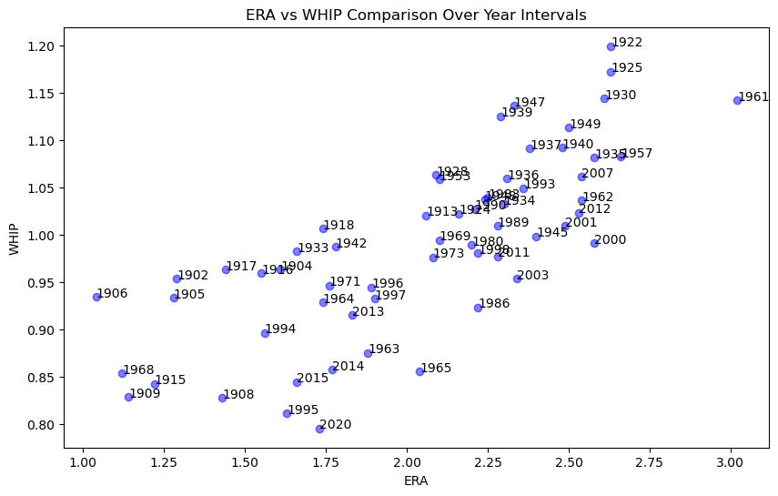

```python
import requests
from bs4 import BeautifulSoup
import pandas as pd
import re
import matplotlib.pyplot as plt

# Function to extract data from the table and create a DataFrame
def extract_data(url, column_name):
    response = requests.get(url)

    if response.status_code == 200:
        soup = BeautifulSoup(response.text, 'html.parser')
        tables = soup.find_all('table')

        for table in tables:
            if len(table.find_all('th')) >= 7:
                data = []
                for row in table.find_all('tr')[1:]:
                    columns = row.find_all(['th', 'td'])
                    team = columns[0].text.strip()
                    player_name = columns[1].text.strip()
                    value = columns[2].text.strip()

                    year_match = re.search(r'\b\d{4}\b', team)
                    year = int(year_match.group()) if year_match else None

                    data.append({'Year': year, 'Player/ Team': player_name, column_name: value})

                df = pd.DataFrame(data)
                df_filtered = df[df['Year'] >= 1901].copy()  # Explicitly create a copy
                df_filtered.sort_values(by='Year', inplace=True)
                df_filtered.reset_index(drop=True, inplace=True)

                return df_filtered

        print(f'{column_name} section not found or structure has changed.')
        return None

    else:
        print(f'Error: {response.status_code}')
        return None

# URLs for the two tables
url_whip = 'https://www.baseball-reference.com/leaders/whip_leagues.shtml'
url_era = 'https://www.baseball-reference.com/leaders/earned_run_avg_leagues.shtml'

# Extract data for WHIP and ERA
df_whip = extract_data(url_whip, 'WHIP')
df_era = extract_data(url_era, 'ERA')

# Merge DataFrames on 'Year' and 'Player/ Team'
merged_df = pd.merge(df_whip, df_era, on=['Year', 'Player/ Team'], how='outer')

# Remove rows with NaN values
merged_df_cleaned = merged_df.dropna()

if merged_df_cleaned is not None:
    # Explicitly create a copy and convert 'ERA' and 'WHIP' columns to numeric
    merged_df_cleaned = merged_df_cleaned.copy()
    merged_df_cleaned['ERA'] = pd.to_numeric(merged_df_cleaned['ERA'])
    merged_df_cleaned['WHIP'] = pd.to_numeric(merged_df_cleaned['WHIP'])

    # Aggregate data by year (using median in this example, but you can use mean or any other metric)
    agg_df = merged_df_cleaned.groupby('Year').agg({'ERA': 'median', 'WHIP': 'median'}).reset_index()

    # Scatter plot
    plt.figure(figsize=(10, 6))
    plt.scatter(agg_df['ERA'], agg_df['WHIP'], color='blue', alpha=0.5)
    plt.title('ERA vs WHIP Comparison Over Year Intervals')
    plt.xlabel('ERA')
    plt.ylabel('WHIP')

    # Annotate points with years
    for i, txt in enumerate(agg_df['Year']):
        plt.annotate(txt, (agg_df['ERA'].iloc[i], agg_df['WHIP'].iloc[i]))

    plt.show()
else:
    print("Data cleaning process failed.")
```

Analysis:

This scatterplot plots each year in terms of its league leader in ERA and WHIP. Generally, these points trend upwards if you look at it in terms of a higher ERA meaning a higher WHIP. If we were to plot a line of best fit, the points would generally be near the line.

Code For Boxplot of WHIP and ERA:

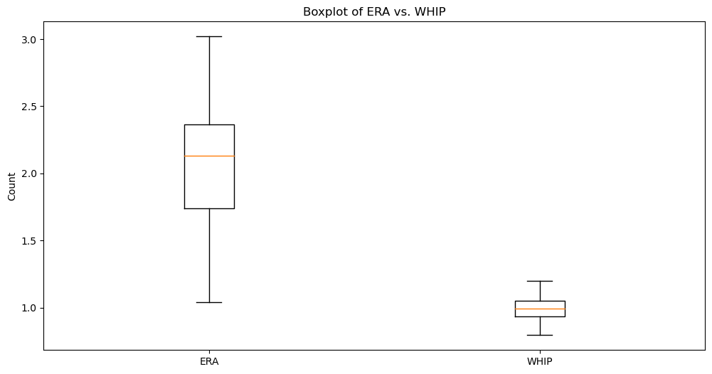

```python
import requests
from bs4 import BeautifulSoup
import pandas as pd
import re
import matplotlib.pyplot as plt

# Function to extract data from the table and create a DataFrame
def extract_data(url, column_name):
    response = requests.get(url)

    if response.status_code == 200:
        soup = BeautifulSoup(response.text, 'html.parser')
        tables = soup.find_all('table')

        for table in tables:
            if len(table.find_all('th')) >= 7:
                data = []
                for row in table.find_all('tr')[1:]:
                    columns = row.find_all(['th', 'td'])
                    team = columns[0].text.strip()
                    player_name = columns[1].text.strip()
                    value = columns[2].text.strip()

                    year_match = re.search(r'\b\d{4}\b', team)
                    year = int(year_match.group()) if year_match else None

                    data.append({'Year': year, 'Player/ Team': player_name, column_name: value})

                df = pd.DataFrame(data)
                df_filtered = df[df['Year'] >= 1901].copy()  # Explicitly create a copy
                df_filtered.sort_values(by='Year', inplace=True)
                df_filtered.reset_index(drop=True, inplace=True)

                return df_filtered

        print(f'{column_name} section not found or structure has changed.')
        return None

    else:
        print(f'Error: {response.status_code}')
        return None

# URLs for the two tables
url_whip = 'https://www.baseball-reference.com/leaders/whip_leagues.shtml'
url_era = 'https://www.baseball-reference.com/leaders/earned_run_avg_leagues.shtml'

# Extract data for WHIP and ERA
df_whip = extract_data(url_whip, 'WHIP')
df_era = extract_data(url_era, 'ERA')

# Merge DataFrames on 'Year' and 'Player/ Team'
merged_df = pd.merge(df_whip, df_era, on=['Year', 'Player/ Team'], how='outer')

# Remove rows with NaN values
merged_df_cleaned = merged_df.dropna()

if merged_df_cleaned is not None:
    # Explicitly create a copy and convert 'ERA' and 'WHIP' columns to numeric
    merged_df_cleaned = merged_df_cleaned.copy()
    merged_df_cleaned['ERA'] = pd.to_numeric(merged_df_cleaned['ERA'])
    merged_df_cleaned['WHIP'] = pd.to_numeric(merged_df_cleaned['WHIP'])

    # Aggregate data by year (using median in this example, but you can use mean or any other metric)
    agg_df = merged_df_cleaned.groupby('Year').agg({'ERA': 'median', 'WHIP': 'median'}).reset_index()


# Plotting box plot for 'Most Losses' and 'Most HR Allowed'
plt.figure(figsize=(12, 6))
plt.boxplot([agg_df['ERA'], agg_df['WHIP']], labels=['ERA', 'WHIP'])

# Adding labels and title
plt.ylabel('Count')
plt.title('Boxplot of ERA vs. WHIP')

# Show the plot

plt.show()
```

Analysis:

These boxplots for ERA versus WHIP display the ranges and the means for both distributions. We see that WHIP ranges between 0.8 and roughly 1.2. The mean for WHIP's distribution is roughly 1.0. The range for ERA is between roughly 1.1 and 3.0, with a mean of about 2.2.